# ACREP Updated Analyses

erin buchanan

Last Updated 2022-04-12

## Information

Multilab close replication of: Experiment 1 from Turri, J., Buckwalter, W., & Blouw, P. (2015). Knowledge and luck. *Psychonomic Bulletin and Review*, 22, 378-390.

[Data and registered protocols:](https://osf.io/n5b3w/)

[Codebook (raw data)](https://docs.google.com/spreadsheets/d/1KjXqgfVgguHeDXVtlHHhJ9zsRGVDfPVPH4tbh75P46U/edit#gid=903093128)

[Preprint](https://psyarxiv.com/zeux9/)

## Libraries

```r
library(rio)
library(lme4)
library(lmerTest)
library(nlme)
library(MuMIn)
library(plyr)
library(psych)
library(tidyr)
```

```r
library(ggplot2)
library(dplyr)
library(ggmosaic)
library(MOTE)
library(flextable)
library(RColorBrewer)
```

## Import the Data

The `full_long` dataset includes all participants in long format - wherein each trial of their study is on one row of the dataset. Our uploaded data also includes `full.Rds` which is the same data in wide format - one column for each variable in the dataset and one row per participant.

```r
full_long <- readRDS("../04_Data/rds/d_all_long.Rds")
#str(full_long)
```

## Open Ended Response Coding

Import the open-ended responses and prepare them for merging with the final dataset. This section:

- Imports all the files
- Includes a coder id
- Corrects all the issues with typed codings
- Converts each item to coder counts so you can convert from wide to long
- Converts from wide to long
- Converts into scoring:
  - No or NA gets 0 points
  - Maybe gets 1 point
  - Yes/test gets 2 points
  - Participants are marked as “excluded” if they get 4 total points across three coders
- Participants are also marked as “nonsense” if they did not write a legible answer or simply typed gibberish. These data points are not excluded but marked if you would like to repeat the analysis and exclude them.

```r
file.names <- list.files(path = "../04_Data/open_responses/",
                         pattern = ".xlsx", full.names = T,
                         recursive = T)

previous.files <- lapply(file.names, function(x){ import(x, sheet = 2)})
purpose.files <- lapply(file.names, function(x){ import(x, sheet = 3)})

# add coder ids
coder.id <- unlist(lapply(strsplit(file.names, "psa004"), function(x) x[[2]]))

names(previous.files) <- coder.id
names(purpose.files) <- coder.id

previousDF <- do.call(rbind.fill, previous.files)
purposeDF <- do.call(rbind.fill, purpose.files)

previousDF$coder <- rep(names(previous.files), unlist(lapply(previous.files, nrow)))
purposeDF$coder <- rep(names(purpose.files), unlist(lapply(purpose.files, nrow)))

# ensure the text is normalized
previousDF$previous <- gsub("\\s+", " ", previousDF$previous)
purposeDF$purpose <- gsub("\\s+", " ", purposeDF$purpose)
previousDF$previous <- gsub("\\s$", "", previousDF$previous)
purposeDF$purpose <- gsub("\\s$", "", purposeDF$purpose)

# can't figure out why these two are different
purposeDF$purpose[purposeDF$id == "s10313"] <- "I'm not sure."
purposeDF$purpose[purposeDF$id == "s10513"] <- "Recall, recognizing"

# fix the yes/no/maybe/NA
previousDF$code <- tolower(previousDF$code)
table(previousDF$code)
```

```
##
## maybe   n/a    na    no    np  test     y   yes
##   321     3   116 16425     1   511     1   248
```

```r
previousDF$code <- gsub("np", "no", previousDF$code)
previousDF$code <- gsub("n/a", "na", previousDF$code)
previousDF$code <- gsub("y$", "yes", previousDF$code)
table(previousDF$code)
```

```
##
## maybe    na    no  test   yes
##   321   119 16426   511   249
```

```r
previousDF <- subset(previousDF, !is.na(id))

purposeDF$code <- tolower(purposeDF$code)
table(purposeDF$code)
```

```
##
##  mayb maybe meybe    mo   n/a    na    no  test   yes
##     2   899     1     1    34   137 13516   689    45
```

```r
purposeDF$code <- gsub("mayb$|meybe", "maybe", purposeDF$code)
purposeDF$code <- gsub("mo", "no", purposeDF$code)
purposeDF$code <- gsub("n/a", "na", purposeDF$code)
table(purposeDF$code)
```

```
##
## maybe    na    no  test   yes
##   902   171 13517   689    45
```

```r
purposeDF <- subset(purposeDF, !is.na(id))

# add coder count
previous_count <- as.data.frame(table(previousDF$id))
previous_count <- previous_count[order(previous_count$Var1), ]
previousDF <- previousDF[order(previousDF$id), ]
previousDF$coder_num <- NA

for (i in 1:length(previous_count$Freq)){
  previousDF$coder_num[previousDF$id == previous_count$Var1[i]] <- 1:previous_count$Freq[i]
}

purpose_count <- as.data.frame(table(purposeDF$id))
purpose_count <- purpose_count[order(purpose_count$Var1), ]
purposeDF <- purposeDF[order(purposeDF$id), ]
purposeDF$coder_num <- NA

for (i in 1:length(purpose_count$Freq)){
  purposeDF$coder_num[purposeDF$id == purpose_count$Var1[i]] <- 1:purpose_count$Freq[i]
}

# long to wide for scoring
previousDF_wide <- pivot_wider(data = previousDF,
                              id_cols = c("id", "survey_lang", "previous"),
                              names_from = "coder_num",
                              values_from = "code")

purposeDF_wide <- pivot_wider(data = purposeDF,
                              id_cols = c("id", "survey_lang", "purpose"),
                              names_from = "coder_num",
                              values_from = "code")

# score the yes/no/maybe/NA
previousDF_wide$score_1 <- previousDF_wide$`1`
previousDF_wide$score_2 <- previousDF_wide$`2`
previousDF_wide$score_3 <- previousDF_wide$`3`

previousDF_wide$score_1 <- gsub("maybe", "1", previousDF_wide$score_1)
previousDF_wide$score_1 <- gsub("no|na", "0", previousDF_wide$score_1)
previousDF_wide$score_1 <- gsub("yes|test", "2", previousDF_wide$score_1)
previousDF_wide$score_2 <- gsub("maybe", "1", previousDF_wide$score_2)
previousDF_wide$score_2 <- gsub("no|na", "0", previousDF_wide$score_2)
previousDF_wide$score_2 <- gsub("yes|test", "2", previousDF_wide$score_2)
previousDF_wide$score_3 <- gsub("maybe", "1", previousDF_wide$score_3)
previousDF_wide$score_3 <- gsub("no|na", "0", previousDF_wide$score_3)
previousDF_wide$score_3 <- gsub("yes|test", "2", previousDF_wide$score_3)

previousDF_wide$count <- apply(
  previousDF_wide[ , grep("score", colnames(previousDF_wide))], 1,
  function(x) { sum(!is.na(x)) } )
previousDF_wide$sum <- apply(
  previousDF_wide[ , grep("score", colnames(previousDF_wide))], 1,
  function (x) { sum(as.numeric(x), na.rm = T)} )

previousDF_wide$exclude <- previousDF_wide$sum >= 4
previousDF_wide$nonsense <- apply(
  previousDF_wide[ , grep("1|2|3|4", colnames(previousDF_wide))], 1,
  function (x) {sum(as.numeric(x == "na"), na.rm = T)}
) == 3

purposeDF_wide$score_1 <- purposeDF_wide$`1`
purposeDF_wide$score_2 <- purposeDF_wide$`2`
purposeDF_wide$score_3 <- purposeDF_wide$`3`

purposeDF_wide$score_1 <- gsub("maybe", "1", purposeDF_wide$score_1)
purposeDF_wide$score_1 <- gsub("no|na", "0", purposeDF_wide$score_1)
purposeDF_wide$score_1 <- gsub("yes|test", "2", purposeDF_wide$score_1)
purposeDF_wide$score_2 <- gsub("maybe", "1", purposeDF_wide$score_2)
purposeDF_wide$score_2 <- gsub("no|na", "0", purposeDF_wide$score_2)
purposeDF_wide$score_2 <- gsub("yes|test", "2", purposeDF_wide$score_2)
purposeDF_wide$score_3 <- gsub("maybe", "1", purposeDF_wide$score_3)
purposeDF_wide$score_3 <- gsub("no|na", "0", purposeDF_wide$score_3)
purposeDF_wide$score_3 <- gsub("yes|test", "2", purposeDF_wide$score_3)

purposeDF_wide$count <- apply(
  purposeDF_wide[ , grep("score", colnames(purposeDF_wide))], 1,
  function(x) { sum(!is.na(x)) } )
purposeDF_wide$sum <- apply(
  purposeDF_wide[ , grep("score", colnames(purposeDF_wide))], 1,
  function (x) { sum(as.numeric(x), na.rm = T)} )

purposeDF_wide$exclude <- purposeDF_wide$sum >= 4
purposeDF_wide$nonsense <- apply(
  purposeDF_wide[ , grep("1|2|3", colnames(purposeDF_wide))], 1,
  function (x) {sum(as.numeric(x == "na"), na.rm = T)}
) == 3

sum(duplicated(purposeDF_wide$id))
```

```
## [1] 0
```

```r
#ids <- purposeDF_wide$id[duplicated(purposeDF_wide$id)]
#View(purposeDF_wide[purposeDF_wide$id %in% ids, ])
sum(duplicated(previousDF_wide$id))
```

```
## [1] 0
```

```r
#ids <- previousDF_wide$id[duplicated(previousDF_wide$id)]
#View(previousDF_wide[previousDF_wide$id %in% ids, ])
```

### Finding missing coders:

```r
previous_missing <- subset(previousDF_wide, count < 3)
purpose_missing <- subset(purposeDF_wide, count < 3)

table(previous_missing$survey_lang)
```

```
## < table of extent 0 >
```

```r
table(purpose_missing$survey_lang)
```

```
## < table of extent 0 >
```

```r
#create reviewer names
previous_completed <- previousDF %>%
  group_by(id) %>%
  summarize(coder = paste(coder, collapse = ", "))

purpose_completed <- purposeDF %>%
  group_by(id) %>%
  summarize(coder = paste(coder, collapse = ", "))

previous_missing <- merge(previous_missing,
                          previous_completed,
                          by = "id",
                          all.x = T)

purpose_missing <- merge(purpose_missing,
                         purpose_completed,
                         by = "id",
                         all.x = T)

write.csv(previous_missing, "../04_Data/data/previous_needs.csv", row.names = F)
write.csv(purpose_missing, "../04_Data/data/purpose_needs.csv", row.names = F)
```

```r
previousDF_long_missing <- subset(previousDF, id %in% previous_missing$id)
previousDF_wide_missing <- pivot_wider(data = previousDF_long_missing,
                                       id_cols = c("id", "survey_lang"),
                                       values_from = "code",
                                       names_from = "coder")

purposeDF_long_missing <- subset(purposeDF, id %in% purpose_missing$id)
purposeDF_wide_missing <- pivot_wider(data = purposeDF_long_missing,
                                       id_cols = c("id", "survey_lang"),
                                       values_from = "code",
                                       names_from = "coder")

write.csv(previousDF_wide_missing, "../04_Data/data/previous_needs_wide.csv", row.names = F)
write.csv(purposeDF_wide_missing, "../04_Data/data/purpose_needs_wide.csv", row.names = F)
```

## Fix Data Coding / Examine Covariates

### Deal with lab coding issues:

- Import lab sheet
- Delete cases that should not be used

```r
lab_sheet <- import("../04_Data/data/lab_sheet_un_region_update.csv") %>%
  select(-un_region2)

nrow(full_long)
```

```
## [1] 28491
```

```r
# delete test and do not use cases
full_long <- subset(full_long, lab_id %in% lab_sheet$lab_code[lab_sheet$use == "Yes"])

nrow(full_long)
```

```
## [1] 27825
```

```r
full_long$lab_id <- droplevels(full_long$lab_id)
```

### Deal with compensation issues:

- Deal with compensation for labs with no information because they didn’t see that question

```r
# deal with compensation questions
# give compensation type labels
table(full_long$comp, useNA = "ifany")
```

```
##
##     1     2     3  <NA>
##  3234 12207  1566 10818
```

```r
full_long$comp <- factor(full_long$comp,
                         levels = 1:3,
                         labels = c("No", "Yes", "Not Sure"))

# examine compensation type by lab
table(full_long$lab_id, full_long$comp, useNA = "ifany")
```

```
##
##            No  Yes Not Sure <NA>
##   6c0ba6  195  150      111   36
##   855e89   36  264       18   54
##   20a1ff    0    3        0 1353
##   cb060d    0    0        3  474
##   78a818   15  402        3  108
##   f6d5a9    9    3        6  423
##   466ec1  177  111       42  207
##   ea9aea    9  198       12   66
##   60ca61  279 1242      279  174
##   7fe877   18  150        0   24
##   069afd   99  915       33  114
##   e53cc5   96  147       39   54
##   f3a68b  267    9       57   96
##   0df1c5   42  474       51  345
##   2c2ba6    0    6        0   24
##   cff0fe   45  246       18   96
##   0eb4a7   18  204       18   33
##   8e07d1   36  423       18   84
##   a3e428   24  126       15    9
##   086a2b   93  444      162    9
##   a6aefd   57  231       99   18
##   1c0a06    0    0        0  174
##   12c361   69  621       36  264
##   905904   18   30       18    0
##   d6a41e   12  186       21   90
##   c1e6b4    0    0        0  483
##   d47b47    0    0        0  246
##   f7f855    0   15        0    9
##   07cc8d   78 1248       51  276
##   c89c37   45  459       12  123
##   098ad3   33  525       21   99
##   9db02f   12  288        6   81
##   9c8799    0    6        0  681
##   7fc76a   18  555        0   72
##   6d2b97   18 1407      105  453
##   c7b55a    0    0        0  294
##   cfff8c   18  417       24   27
##   2f579c  519  147      174  156
##   6898ef    6    0        3  861
##   612ed8    0    3        0   78
##   053396  432   24       36  138
##   c13d3a  276   15       75  180
##   aba0ac    3    0        0  696
##   ee46af    3  225        0    6
##   b6c8ec    0    0        0 1530
##   87d100  159  288        0    0
```

```r
# find labs that had majority no comp
lab_comp_temp <- as.data.frame(table(full_long$lab_id, full_long$comp, useNA = "ifany") / rowSums(table(full_long$lab_id, full_long$comp, useNA = "ifany")) * 100)

lab_comp_temp <- lab_comp_temp[order(lab_comp_temp$Freq, decreasing = T) , ]
lab_comp_max <- lab_comp_temp[!duplicated(lab_comp_temp$Var1), ]
lab_comp_max <- subset(lab_comp_max, is.na(Var2))
colnames(lab_comp_max) <- c("lab_code", "comp", "Percent")

# clean up lab codes compensation
table(lab_sheet$compensation, useNA = "ifany")
```

```
##
##                                     Course Credit
##                                                26
## Course Credit for Students, Nothing for Community
##                                                 2
##                                           Lottery
##                                                 2
##                                             Money
##                                                 3
##                                              None
##                                                11
##                                            Sweets
##                                                 4
##                                           Unclear
##                                                 9
##                                              <NA>
##                                                26
```

```r
lab_sheet$comp <- lab_sheet$compensation
lab_sheet$comp <- gsub("Course Credit for Students, Nothing for Community", "Mixed", lab_sheet$comp)
lab_sheet$comp <- gsub("Course Credit|Lottery|Money|Sweets", "Yes", lab_sheet$comp)
lab_sheet$comp <- gsub("None", "No", lab_sheet$comp)

table(lab_sheet$comp, useNA = "ifany")
```

```
##
##   Mixed      No Unclear     Yes    <NA>
##       2      11       9      35      26
```

```r
# merge these two things together
lab_comp_max <- merge(lab_comp_max, lab_sheet, by = "lab_code")

# drop all unclear or mixed
lab_comp_max <- subset(lab_comp_max, comp.y != "Mixed" &
                         comp.y != "Unclear")

# fix compensation for labs
full_long$comp[full_long$lab_id %in%
                 lab_comp_max$lab_code[lab_comp_max$comp.y == "Yes"]] <- "Yes"
full_long$comp[full_long$lab_id %in%
                 lab_comp_max$lab_code[lab_comp_max$comp.y == "No"]] <- "No"

table(full_long$lab_id, full_long$comp, useNA = "ifany")
```

```
##
##            No  Yes Not Sure <NA>
##   6c0ba6  195  150      111   36
##   855e89   36  264       18   54
##   20a1ff    0 1356        0    0
##   cb060d  477    0        0    0
##   78a818   15  402        3  108
##   f6d5a9    0  441        0    0
##   466ec1  537    0        0    0
##   ea9aea    9  198       12   66
##   60ca61  279 1242      279  174
##   7fe877   18  150        0   24
##   069afd   99  915       33  114
##   e53cc5   96  147       39   54
##   f3a68b  267    9       57   96
##   0df1c5   42  474       51  345
##   2c2ba6    0   30        0    0
##   cff0fe   45  246       18   96
##   0eb4a7   18  204       18   33
##   8e07d1   36  423       18   84
##   a3e428   24  126       15    9
##   086a2b   93  444      162    9
##   a6aefd   57  231       99   18
##   1c0a06    0  174        0    0
##   12c361   69  621       36  264
##   905904   18   30       18    0
##   d6a41e   12  186       21   90
##   c1e6b4  483    0        0    0
##   d47b47  246    0        0    0
##   f7f855    0   15        0    9
##   07cc8d   78 1248       51  276
##   c89c37   45  459       12  123
##   098ad3   33  525       21   99
##   9db02f   12  288        6   81
##   9c8799  687    0        0    0
##   7fc76a   18  555        0   72
##   6d2b97   18 1407      105  453
##   c7b55a  294    0        0    0
##   cfff8c   18  417       24   27
##   2f579c  519  147      174  156
##   6898ef  870    0        0    0
##   612ed8   81    0        0    0
##   053396  432   24       36  138
##   c13d3a  276   15       75  180
##   aba0ac    0  699        0    0
##   ee46af    3  225        0    6
##   b6c8ec    0 1530        0    0
##   87d100  159  288        0    0
```

```r
# deal with not sures
table(full_long$comp, useNA = "ifany")
```

```
##
##       No      Yes Not Sure     <NA>
##     6714    16305     1512     3294
```

```r
# if they wrote not sure
# and didn't pick one of the compensation options
# then they did not get compensated
full_long$comp[full_long$comp == "Not Sure" & is.na(full_long$comp_type)] <- "No"

# if they wrote note sure
# but then picked a compensation option
# then the answer is yes
full_long$comp[full_long$comp == "Not Sure" & !is.na(full_long$comp_type)] <- "Yes"

#add turk variable
full_long$turk <- full_long$lab_id == "b6c8ec"

full_long$comp <- droplevels(full_long$comp)
```

### Fix Lab ID to Consistent “Data Collection Location ID”

```r
full_long <- merge(full_long,
                   lab_sheet[ , c("lab_code", "un_region", "person_code")],
                   by.x = "lab_id", by.y = "lab_code",
                   all.x = T)

table(full_long$person_code)
```

```
##
## 04aec6c128a6d0c7b156124a782a2e17 053921f004965238755a0b08414ad61f
##                             1161                             1653
## 10fe64c77bdcdd1f63c4f6f6767bd834 1300dd2a365669443e58645538040b7e
##                             1356                              294
## 20e15d6f0eb0520239a9f7921b1ee905 25c0099bdeb9900e64b3f1e17ea9cf32
##                              912                              537
## 2c70764140dc2267dc65e463842c75dd 3b4e9381f4aafb032e37c0d5fa732aba
##                             1974                              234
## 3e1f2a5e94450c8371562c74671ace76 47cce7454402254dd1e56c7338d2ca3b
##                              174                              447
## 4f86a6d4b553a44559cde3ceba92b330 5f4f444af13a37ac3598f3f4f613f560
##                              174                              387
## 6109cf70459f0edc57ccb89cf26d66ef 63947e8c9e47bc0056f78f402f3898f1
##                              477                              309
## 64ba90ce7822b9c898df033ebb8c2c18 71289e5ce6b2abe28c0d25bdce7c14a0
##                              429                              486
## 7898bca2938d7b6d8a82093ddffb15dc 82d647ec9366dd067a092145d7d8ee7b
##                              639                             1020
## 8ceb72b59172af0d6a8d657e76ec4ce8 8ee3ca908c989e3f6342994da802c3bd
##                              645                              699
## a5e2ba5c7fcf9a90c4bc1b5ed666f57b adaccbbc254a881db6c19b3224887bcc
##                              729                             1530
## b6bab6f7c2e61741dcdc1689c30fc5fb b975583369996d9136088dbe211abfcf
##                               24                              372
## bc3266a9a2dc0de236029a38f1e0d4b9 bfe85dfa8a47470e2600b4bae1dfe4c1
##                              285                             3306
## c22875ee12b4cdfb8843ead3b8e1ddf8 c6e892a926333f0840a81af6fa74a6c6
##                              492                              687
## ccc20a00466f0c4077f924733e9a3789 d4c4b2302987480f7ce2084927489e4e
##                              441                              192
## d5450db323eeab9cf7bd57ecc95d3454 d547b0fe851b1f8786fce767e3d89f50
##                              336                             1206
## de5a43985156a022e44511202ccd5449 ec35cfeaedd64eccef16c265b2ba179f
##                             1983                              996
## ecb1153cd73ee30290a753fb74358c19 f19f790831cbe3722ccd98fd63d3d902
##                              273                              405
## fd5a38067cf64a3e10ae8e92f015be4e
##                              561
```

### Examine Coding for Covariates

- Examine gender labels
- Recode education to number and examine … fix issues with two labs not using the same education values.

```r
# better labels for graphs
full_long$vignette <- factor(full_long$vignette,
                             levels = c("D", "E", "G"),
                             labels = c("Darrel", "Emma", "Gerald"))

full_long$cond <- factor(full_long$cond,
                             levels = c("G", "I", "K"),
                             labels = c("Gettier", "Ignorance", "Knowledge"))

# gender
table(full_long$gender, useNA = "ifany")
```

```
##
## female   male  other   <NA>
##  14979   6651    141   6054
```

```r
# describe education years
full_long$education <- as.numeric(full_long$education)
describe(full_long$education[!duplicated(full_long$id)])
```

```
##    vars    n mean   sd median trimmed  mad min max range  skew kurtosis   se
## X1    1 6520 13.7 2.92     14   13.88 2.97   1  18    17 -1.41     4.44 0.04
```

```r
levels(full_long$education_level)
```

```
## [1] "Less than high school"
## [2] "High school diploma (or GED)"
## [3] "Some college or a 2-year college degree (A.A.)"
## [4] "4-year college degree (B.A., B.S.)"
## [5] "Master’s degree (M.A., M.S.)"
## [6] "Graduate or professional degree (J.D., Ph.D., M.D.)"
```

```r
# less high school = 10
# high school = 12
# some college = 14
# college = 16
# masters = 18
# graduate = 20

# levels(full_long$education) <- c(levels(full_long$education), 20, 21)
# truncate all education since that's how it was on socisurvey

full_long$education[full_long$education_level == "Less than high school" & !is.na(full_long$education_level)] <- 10
full_long$education[full_long$education_level == "High school diploma (or GED)" & !is.na(full_long$education_level)] <- 12
full_long$education[full_long$education_level == "Some college or a 2-year college degree (A.A.)" & !is.na(full_long$education_level)] <- 14
full_long$education[full_long$education_level == "4-year college degree (B.A., B.S.)" & !is.na(full_long$education_level)] <- 16
full_long$education[full_long$education_level == "Master’s degree (M.A., M.S.)" & !is.na(full_long$education_level)] <- 18 #> 17 group
full_long$education[full_long$education_level == "Graduate or professional degree (J.D., Ph.D., M.D.)" & !is.na(full_long$education_level)] <-  18 #>17 group

# PRT lab bach = 15, master = 17, PHD = 21
full_long$education[full_long$education_level == "4-year college degree (B.A., B.S.)" & !is.na(full_long$education_level) & full_long$lab_id == "b6c8ec"] <- 15
full_long$education[full_long$education_level == "Master’s degree (M.A., M.S.)" & !is.na(full_long$education_level) & full_long$lab_id == "b6c8ec"] <- 17
full_long$education[full_long$education_level == "Graduate or professional degree (J.D., Ph.D., M.D.)" & !is.na(full_long$education_level) & full_long$lab_id == "b6c8ec"] <-  18 #> 17 group

# describe age
describe(full_long$age[!duplicated(full_long$id)])
```

```
##    vars    n mean    sd median trimmed  mad min max range  skew kurtosis   se
## X1    1 7238 25.1 20.82     21   22.18 2.97   0 999   999 30.63  1348.53 0.24
```

```r
# number of rows
nrow(full_long)
```

```
## [1] 27825
```

```r
# number of participants
length(unique(full_long$id))
```

```
## [1] 9275
```

```r
# number of data collection locations
length(unique(full_long$person_code))
```

```
## [1] 37
```

## Study Exclusions

In this section, we will mark each exclusion criteria to be able to denote how many exclusions each participant may have had.

### Majority Age

1. if the participant is not the majority age of their country or older (unless parent/guardian waiver provided)

In this section, we will exclude all participants who are under 18 or are not the majority age of their country or older.

https://en.wikipedia.org/wiki/Age_of_majority

```r
# table of lab countries
full_long$lab_country <- droplevels(full_long$lab_country)
table(full_long$lab_country, useNA = "ifany")
```

```
##
##  AUS  AUT  CAN  CHE  DEU  GBR  GRC  HUN  NOR  NZL  POL  PRT  ROU  RUS  SGP  SVK
##  645  906 1653  174 4302 1020  294 1974  441  174 1266  447 1983  699  234  687
##  TUR  TWN  USA
##  912 1356 8658
```

```r
# age information
summary(full_long$age)
```

```
##    Min. 1st Qu.  Median    Mean 3rd Qu.    Max.    NA's
##     0.0    19.0    21.0    25.1    25.0   999.0    6111
```

```r
# minimum age by country
tapply(full_long$age, full_long$lab_country, min, na.rm = T)
```

```
## AUS AUT CAN CHE DEU GBR GRC HUN NOR NZL POL PRT ROU RUS SGP SVK TUR TWN USA
##  14  17  10  17   1   0  19   0  19  18   5  18  19   0  19  18   0  10   1
```

```r
# exclude based on age
full_long$age_exclusion <- NA

age18 <- c("AUT", "AUS", "CAN", "CHE", "DEU", "GBR", "GRC", "HUN", "NOR", "NZL", "POL", "PRT", "ROU", "RUS", "SGP", "TUR", "TWN", "USA")
age19 <- c("SVK")
age21 <- c("ARE")

full_long$age_exclusion[full_long$lab_country %in% age18] <- full_long$age[full_long$lab_country %in% age18] < 18

full_long$age_exclusion[full_long$lab_country %in% age19] <- full_long$age[full_long$lab_country %in% age19] < 19

full_long$age_exclusion[full_long$lab_country %in% age21] <- full_long$age[full_long$lab_country %in% age21] < 21

full_long$age_exclusion[full_long$age > 100] <- TRUE
```

### Previous Knowledge/Participation of Study

2. if the participant has taken part in a previous version of this study or in another contributors’ replication of the same study

```r
full_long <- merge(full_long,
                   previousDF_wide[ , c("id", "exclude", "nonsense")], all.x = T)

# number of rows
nrow(full_long)
```

```
## [1] 27825
```

```r
# number of participants
length(unique(full_long$id))
```

```
## [1] 9275
```

```r
colnames(full_long)[(ncol(full_long)-1):ncol(full_long)] <- c("previous_exclusion", "previous_nonsense")
```

### Comprehension Questions

3. if the participant fails to answer comprehension questions correctly

```r
table(full_long$dge_valid)
```

```
##
## FALSE  TRUE
##  8526 14835
```

```r
full_long$studyans_exclusion <- !(full_long$dge_valid)
```

### Knowledge of Experiment/Hypothesis

4. if the participant correctly and explicitly articulate knowledge of the specific hypotheses or specific conditions of this study when answering the funneled debriefing questions.

```r
full_long <- merge(full_long,
                   purposeDF_wide[ , c("id", "exclude", "nonsense")], all.x = T)

# number of rows
nrow(full_long)
```

```
## [1] 27825
```

```r
# number of participants
length(unique(full_long$id))
```

```
## [1] 9275
```

```r
colnames(full_long)[(ncol(full_long)-1):ncol(full_long)] <- c("purpose_exclusion", "purpose_nonsense")
```

### Language Proficiency

We will also exclude participants who self-report their understanding of the tested language as “not well” or “not well at all”. We based this exclusion criteria on a recent study that found that non-native English speakers who self-report as “very well” and “well” tend to score in the “intermediate” and “basic” categories on an English proficiency test respectively, while those who self-report as “not well” and “not at all” tend to score in the “below basic” category (Vickstrom, Shin, Collazo, & Bauman, 2015). All excluded data will be included in the data files on the overall OSF page, along with the particular reason for why they were excluded.

```r
summary(full_long$language)
```

```
## not well at all   not very well            well       very well            NA's
##              54             216            2031           19521            6003
```

```r
full_long$lang_exclusion <- full_long$language == "not very well" | full_long$language == "not well at all"
```

### Total Exclusions

In this section, we provide the total (data point) exclusions for each particular screening item plus a table with all exclusions forever.

```r
# exclusions individually
table(full_long$age_exclusion, useNA = "ifany") / 3
```

```
##
## FALSE  TRUE  <NA>
##  7188    50  2037
```

```r
table(full_long$lang_exclusion, useNA = "ifany") / 3
```

```
##
## FALSE  TRUE  <NA>
##  7184    90  2001
```

```r
table(full_long$studyans_exclusion, useNA = "ifany") / 3
```

```
##
## FALSE  TRUE  <NA>
##  4945  2842  1488
```

```r
table(full_long$previous_exclusion, useNA = "ifany") / 3
```

```
##
## FALSE  TRUE  <NA>
##  5586   238  3451
```

```r
table(full_long$purpose_exclusion, useNA = "ifany") / 3
```

```
##
## FALSE  TRUE  <NA>
##  4855   203  4217
```

```r
# for these, NA means they should be excluded
full_long$age_exclusion[is.na(full_long$age_exclusion)] <- TRUE
full_long$lang_exclusion[is.na(full_long$lang_exclusion)] <- TRUE
full_long$studyans_exclusion[is.na(full_long$studyans_exclusion)] <- TRUE

# for these, NA means no answer which is ok
full_long$previous_exclusion[is.na(full_long$previous_exclusion)] <- FALSE
full_long$purpose_exclusion[is.na(full_long$purpose_exclusion)] <- FALSE

full_long$total_exclusion <- apply(full_long[ , grep("exclusion", colnames(full_long))], 1, sum, na.rm = T)

table(full_long$total_exclusion, useNA = "ifany") / 3
```

```
##
##    0    1    2    3    4    5
## 4724 2378  197 1820   63   93
```

```r
# multiway table of all exclusions
exclusions <- as.data.frame(table(full_long$age_exclusion,
                                  full_long$lang_exclusion,
                                  full_long$previous_exclusion,
                                  full_long$purpose_exclusion,
                                  full_long$studyans_exclusion, useNA = "ifany"))
colnames(exclusions) <- c("Age", "Language", "Previous", "Purpose", "Comprehension", "Frequency")
exclusions$Num_Participants <- exclusions$Frequency / 3

exclusions
```

```
##      Age Language Previous Purpose Comprehension Frequency Num_Participants
## 1  FALSE    FALSE    FALSE   FALSE         FALSE     14172             4724
## 2   TRUE    FALSE    FALSE   FALSE         FALSE        87               29
## 3  FALSE     TRUE    FALSE   FALSE         FALSE        63               21
## 4   TRUE     TRUE    FALSE   FALSE         FALSE       222               74
## 5  FALSE    FALSE     TRUE   FALSE         FALSE       177               59
## 6   TRUE    FALSE     TRUE   FALSE         FALSE         3                1
## 7  FALSE     TRUE     TRUE   FALSE         FALSE         0                0
## 8   TRUE     TRUE     TRUE   FALSE         FALSE         0                0
## 9  FALSE    FALSE    FALSE    TRUE         FALSE        48               16
## 10  TRUE    FALSE    FALSE    TRUE         FALSE         0                0
## 11 FALSE     TRUE    FALSE    TRUE         FALSE         0                0
## 12  TRUE     TRUE    FALSE    TRUE         FALSE        15                5
## 13 FALSE    FALSE     TRUE    TRUE         FALSE        12                4
## 14  TRUE    FALSE     TRUE    TRUE         FALSE         9                3
```

[output cut: 18 more lines]

```r
final_long <- subset(full_long, total_exclusion < 1)

# drop all the levels that no longer exist within the data
final_long <- droplevels(final_long)

# total number data points originally
nrow(full_long)
```

```
## [1] 27825
```

```r
# total number data points now
nrow(final_long)
```

```
## [1] 14172
```

```r
# original number of participants
length(unique(full_long$id))
```

```
## [1] 9275
```

```r
# final number of participants
length(unique(final_long$id))
```

```
## [1] 4724
```

## Examine the Distributions

```r
table(final_long$bin_order)
```

```
##
## swapped  normal   mixed
##    6378    6726    1068
```

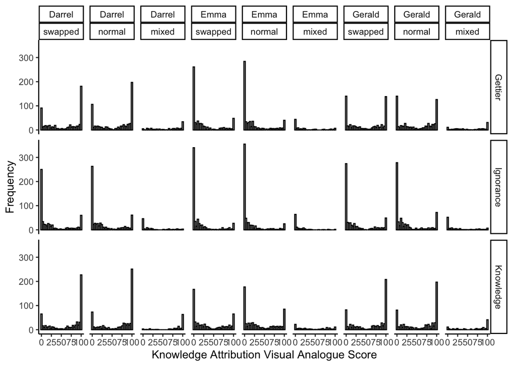

```r
final_long$bin_order <- droplevels(final_long$bin_order)

# visualize the problem
ggplot(final_long, aes(know_vas)) +
  geom_histogram(color = "black", fill = "white") +
  facet_grid(cond~vignette*bin_order) +
  theme_classic() +
  ylab("Frequency") +
  xlab("Knowledge Attribution Visual Analogue Score")
```

## Descriptives and Demographics

```r
# total lab count
length(unique(full_long$person_code))
```

```
## [1] 37
```

```r
# usable data lab count
length(unique(final_long$person_code))
```

```
## [1] 36
```

```r
# total countries
table(full_long$lab_country)
```

```
##
##  AUS  AUT  CAN  CHE  DEU  GBR  GRC  HUN  NOR  NZL  POL  PRT  ROU  RUS  SGP  SVK
##  645  906 1653  174 4302 1020  294 1974  441  174 1266  447 1983  699  234  687
##  TUR  TWN  USA
##  912 1356 8658
```

```r
length(table(full_long$lab_country))
```

```
## [1] 19
```

```r
# usable countries
table(final_long$lab_country)
```

```
##
##  AUS  AUT  CAN  CHE  DEU  GBR  GRC  HUN  NOR  NZL  POL  PRT  ROU  RUS  SGP  SVK
##  366  453  774   84 2316  396  156 1347  228  126  579  243 1113  297  156  309
##  TUR  TWN  USA
##  231  324 4674
```

```r
length(table(final_long$lab_country))
```

```
## [1] 19
```

```r
# proportion usable data by country
table(final_long$lab_country) / table(full_long$lab_country)
```

```
##
##       AUS       AUT       CAN       CHE       DEU       GBR       GRC       HUN
## 0.5674419 0.5000000 0.4682396 0.4827586 0.5383543 0.3882353 0.5306122 0.6823708
##       NOR       NZL       POL       PRT       ROU       RUS       SGP       SVK
## 0.5170068 0.7241379 0.4573460 0.5436242 0.5612708 0.4248927 0.6666667 0.4497817
##       TUR       TWN       USA
## 0.2532895 0.2389381 0.5398475
```

## Analysis Overview

- Analysis:
  - Multilevel modeling using appropriate linking function
- Dependent variable(s):
  - Knowledge
  - Luck
  - Reasonable
- Independent variable:
  - Condition
- Covariates:
  - Test setting: compensated versus uncompensated
  - Age
  - Gender (men/women/other)
  - Years of education
- Random intercepts:
  - participant / vignette / lab / maybe geographic region
- Special population:
  - Turk data on similar analysis

## Data Screening

In this section, we will screen the continuous VAS variable, as the BIN variable does not require the same screening because of the different assumptions.

### Knowledge

```r
# drop levels
final_long$id <- factor(final_long$id)
final_long$vignette <- factor(final_long$vignette)

# check numbers
table(final_long$cond, useNA = "ifany")
```

```
##
##   Gettier Ignorance Knowledge
##      4724      4724      4724
```

```r
table(final_long$comp, useNA = "ifany")
```

```
##
##    No   Yes  <NA>
##  3870 10299     3
```

```r
table(final_long$gender, useNA = "ifany")
```

```
##
## female   male  other
##   9948   4161     63
```

```r
length(na.omit(final_long$know_vas))
```

```
## [1] 12200
```

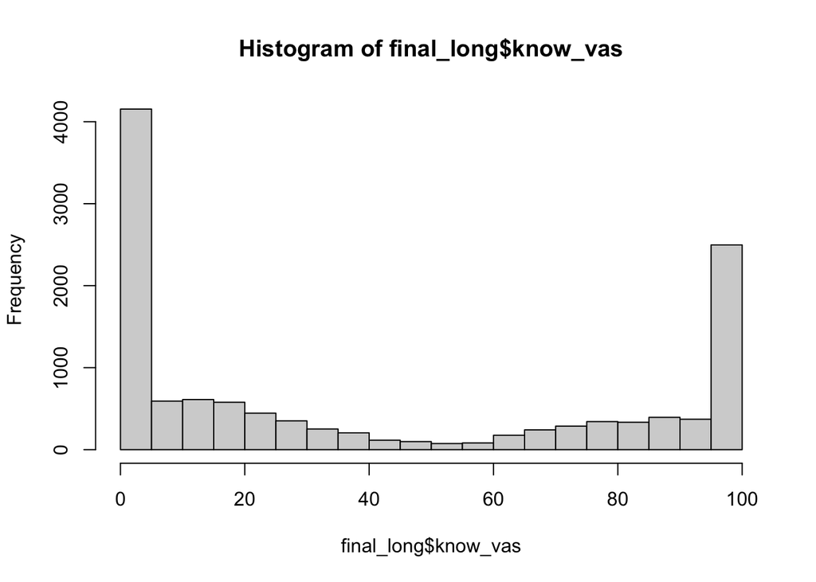

```r
# check data
hist(final_long$know_vas)
```

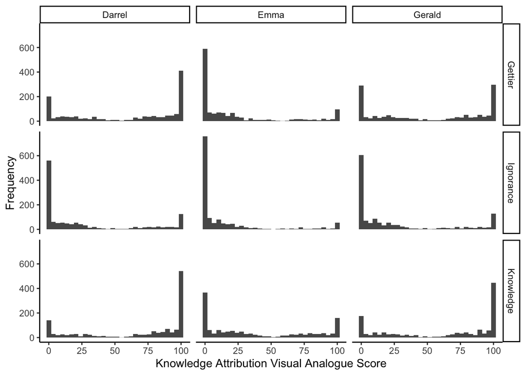

```r
# visualize the problem
ggplot(final_long, aes(know_vas)) +
  geom_histogram() +
  facet_grid(cond~vignette) +
  theme_classic() +
  ylab("Frequency") +
  xlab("Knowledge Attribution Visual Analogue Score")
```

```r
## knowledge
ds.model <- lme(know_vas ~ cond + comp + age + gender + education,
                random = list(~1|vignette, ~1|id, ~1|person_code),
                data = final_long,
                na.action = "na.omit")

# additivity
round(summary(ds.model)$corFixed,2)
```

```
##               (Intercept) condIgnorance condKnowledge compYes   age gendermale
## (Intercept)          1.00         -0.05         -0.05   -0.07 -0.09      -0.02
## condIgnorance       -0.05          1.00          0.50    0.00  0.00       0.00
## condKnowledge       -0.05          0.50          1.00    0.00  0.00       0.00
## compYes             -0.07          0.00          0.00    1.00  0.20       0.00
## age                 -0.09          0.00          0.00    0.20  1.00      -0.11
## gendermale          -0.02          0.00          0.00    0.00 -0.11       1.00
## genderother         -0.01          0.00          0.00    0.01  0.03       0.04
## education           -0.19          0.00          0.00   -0.10 -0.11       0.02
##               genderother education
## (Intercept)         -0.01     -0.19
## condIgnorance        0.00      0.00
## condKnowledge        0.00      0.00
## compYes              0.01     -0.10
## age                  0.03     -0.11
## gendermale           0.04      0.02
## genderother          1.00      0.03
## education            0.03      1.00
```

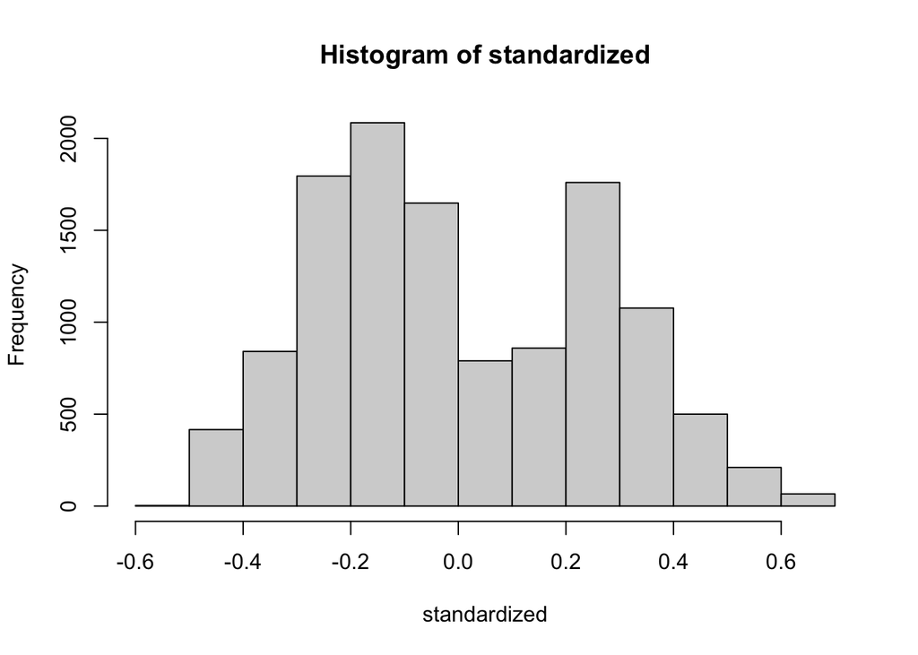

```r
# normality
standardized <- residuals(ds.model, type = "normalized")
hist(standardized)
```

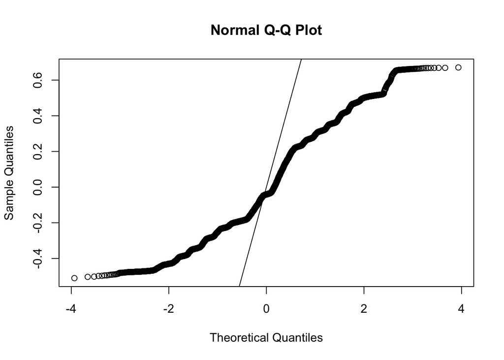

```r
# linearity
{qqnorm(standardized)
  abline(0,1)}
```

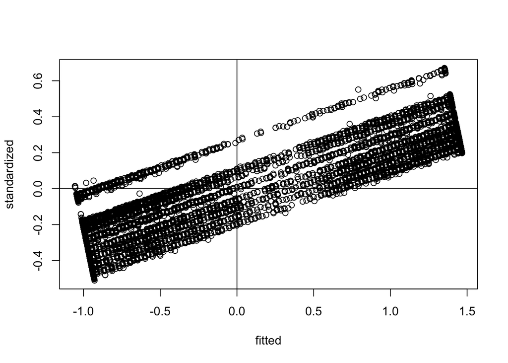

```r
# homosc
fitted <- scale(fitted.values(ds.model))
{plot(fitted, standardized)
  abline(v = 0)
  abline(h = 0)}
```

### Reasonableness

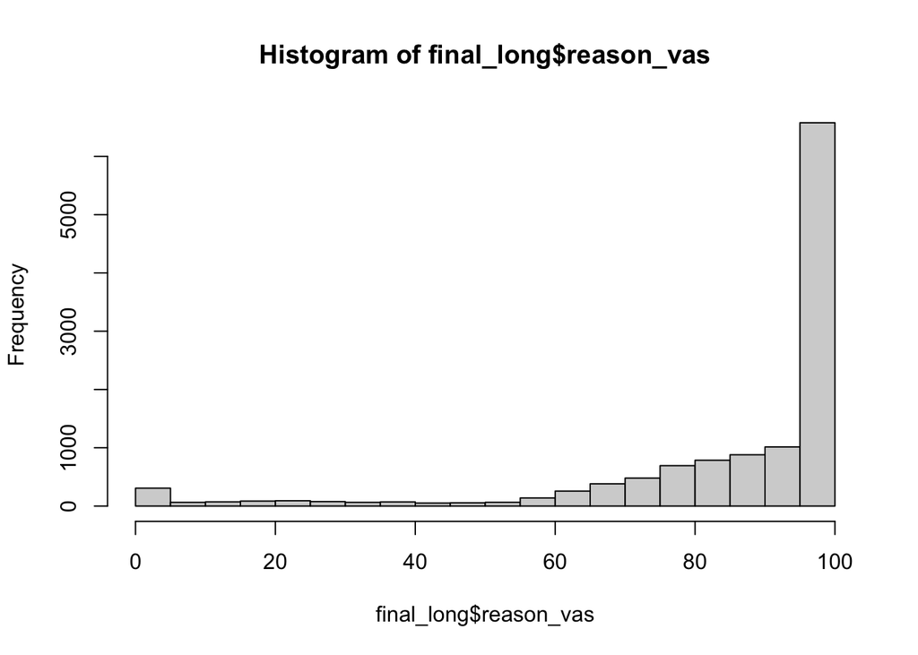

```r
# check data
hist(final_long$reason_vas)
```

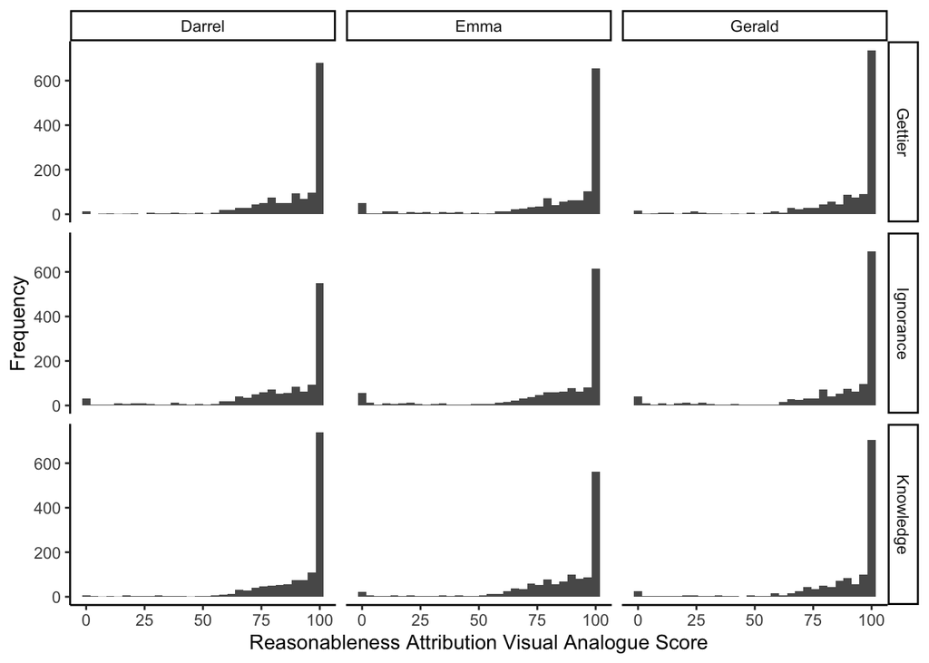

```r
# visualize the problem
ggplot(final_long, aes(reason_vas)) +
  geom_histogram() +
  facet_grid(cond~vignette) +
  theme_classic() +
  ylab("Frequency") +
  xlab("Reasonableness Attribution Visual Analogue Score")
```

```r
## reasonable
ds.model <- lme(reason_vas ~ cond + comp_type + age +
                  gender + education,
                random = list(~1|vignette, ~1|id), #won't converge with person_code
                data = final_long,
                na.action = "na.omit")

# additivity
round(summary(ds.model)$corFixed,2)
```

```
##               (Intercept) condIgnorance condKnowledge comp_type   age
## (Intercept)          1.00         -0.17         -0.17     -0.21 -0.46
## condIgnorance       -0.17          1.00          0.50      0.00  0.00
## condKnowledge       -0.17          0.50          1.00      0.00  0.00
## comp_type           -0.21          0.00          0.00      1.00 -0.03
## age                 -0.46          0.00          0.00     -0.03  1.00
## gendermale          -0.07          0.00          0.00     -0.09 -0.04
## genderother         -0.06          0.00          0.00      0.03  0.01
## education           -0.61          0.00          0.00      0.06 -0.20
##               gendermale genderother education
## (Intercept)        -0.07       -0.06     -0.61
## condIgnorance       0.00        0.00      0.00
## condKnowledge       0.00        0.00      0.00
## comp_type          -0.09        0.03      0.06
## age                -0.04        0.01     -0.20
## gendermale          1.00        0.04      0.04
## genderother         0.04        1.00      0.05
## education           0.04        0.05      1.00
```

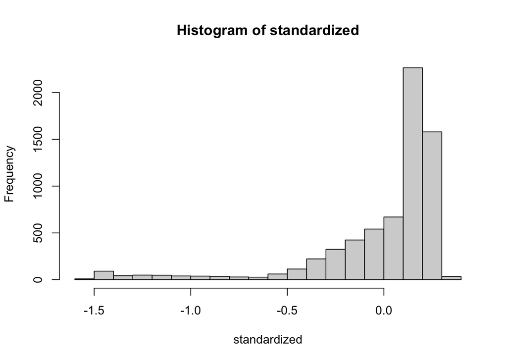

```r
# normality
standardized <- residuals(ds.model, type = "normalized")
hist(standardized)
```

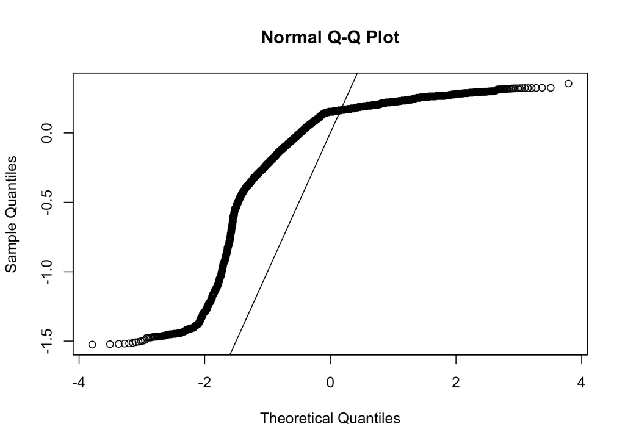

```r
# linearity
{qqnorm(standardized)
  abline(0,1)}
```

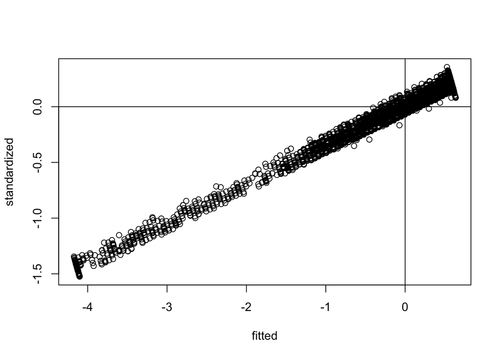

```r
# homosc
fitted <- scale(fitted.values(ds.model))
{plot(fitted, standardized)
  abline(v = 0)
  abline(h = 0)}
```

### Luck

```r
# for luck analyses people should be excluded if they get the answer wrong
final_long$luck_correct <- FALSE

final_long$ri_wr <- factor(final_long$ri_wr,
                           levels = c(1,2),
                           labels = c("Right", "Wrong"))
final_long$luck_correct[final_long$cond == "Ignorance" & final_long$ri_wr == "Wrong"] <- TRUE
final_long$luck_correct[final_long$cond != "Ignorance" & final_long$ri_wr == "Right"] <- TRUE

table(final_long$luck_correct)
```

```
##
## FALSE  TRUE
##   921 13251
```

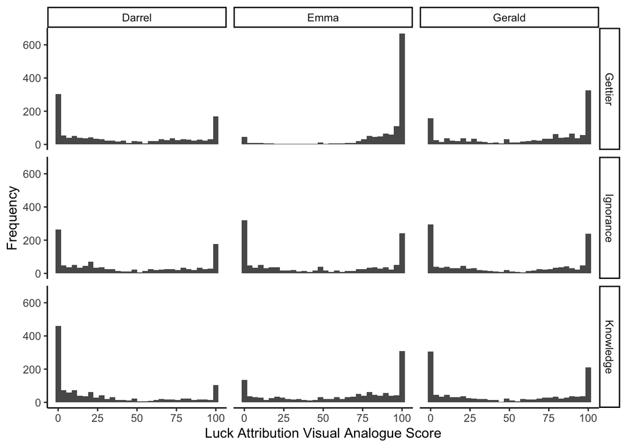

```r
# subset the wrong answers
final_luck <- subset(final_long, luck_correct)

# visualize the problem
ggplot(final_luck, aes(luck_vas)) +
  geom_histogram() +
  facet_grid(cond~vignette) +
  theme_classic() +
  ylab("Frequency") +
  xlab("Luck Attribution Visual Analogue Score")
```

```r
ds.model <- lme(luck_vas ~ cond + comp_type + age +
                  gender + education ,
                random = list(~1|vignette, ~1|id),
                data = final_luck,
                na.action = "na.omit")

# additivity
round(summary(ds.model)$corFixed,2)
```

```
##               (Intercept) condIgnorance condKnowledge comp_type   age
## (Intercept)          1.00         -0.07         -0.07     -0.08 -0.18
## condIgnorance       -0.07          1.00          0.51      0.00  0.00
## condKnowledge       -0.07          0.51          1.00      0.00  0.00
## comp_type           -0.08          0.00          0.00      1.00 -0.03
## age                 -0.18          0.00          0.00     -0.03  1.00
## gendermale          -0.03          0.00          0.00     -0.09 -0.03
## genderother         -0.02          0.00          0.00      0.03  0.01
## education           -0.24          0.00          0.00      0.06 -0.20
##               gendermale genderother education
## (Intercept)        -0.03       -0.02     -0.24
## condIgnorance       0.00        0.00      0.00
## condKnowledge       0.00        0.00      0.00
## comp_type          -0.09        0.03      0.06
## age                -0.03        0.01     -0.20
## gendermale          1.00        0.04      0.03
## genderother         0.04        1.00      0.05
## education           0.03        0.05      1.00
```

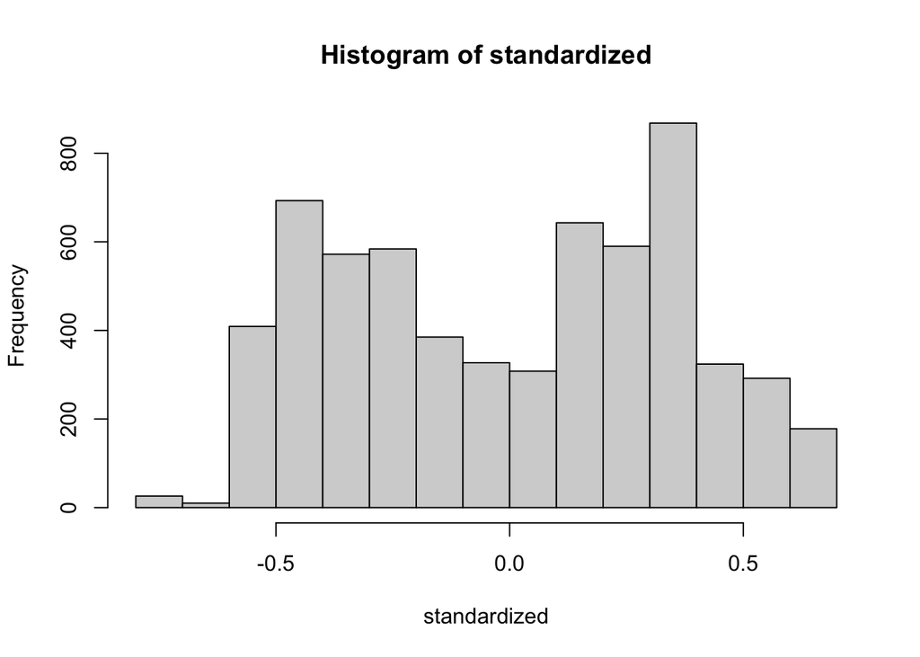

```r
# normality
standardized <- residuals(ds.model, type = "normalized")
hist(standardized)
```

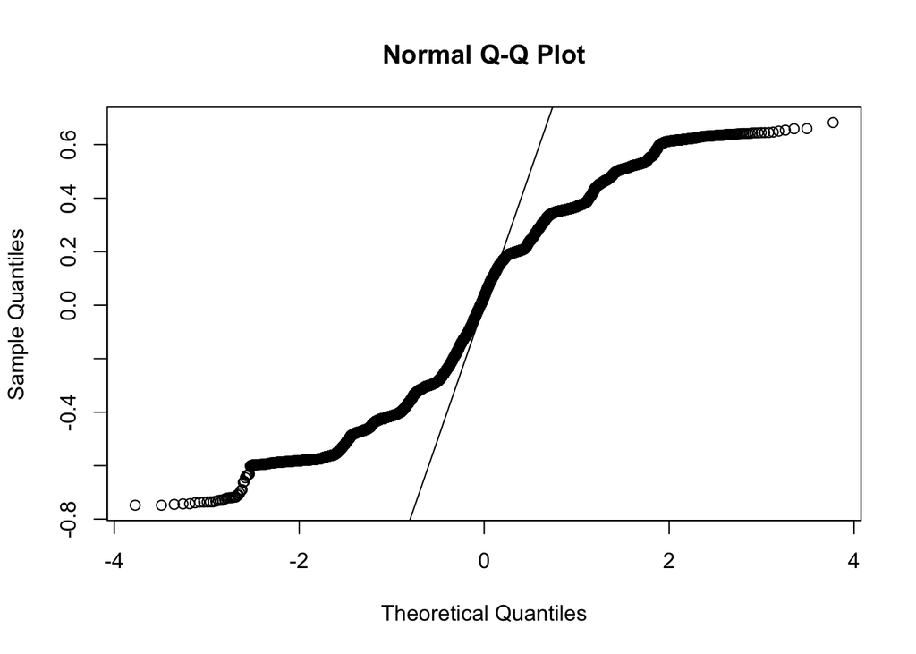

```r
# linearity
{qqnorm(standardized)
  abline(0,1)}
```

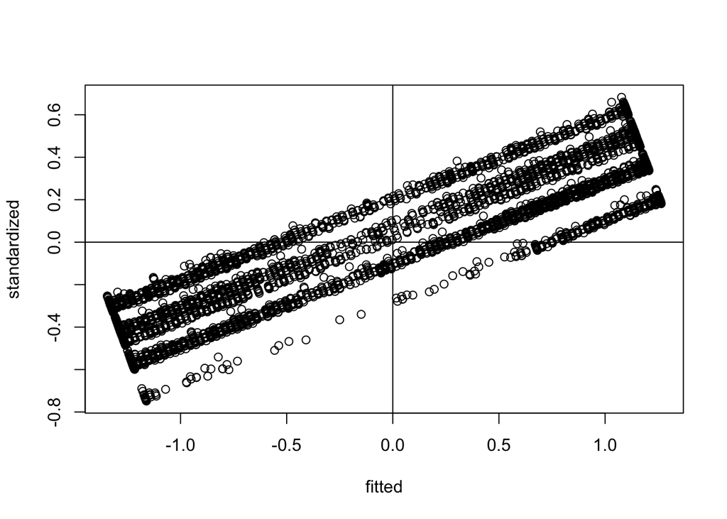

```r
# homosc
fitted <- scale(fitted.values(ds.model))
{plot(fitted, standardized)
  abline(v = 0)
  abline(h = 0)}
```

### Update DV

In this instance, we do not see any form of linearity or homoscedasticity - the data is clearly skewed or bimodal. Therefore, we decided to split the VAS scale into 40 and below and 60 and above, then combine with the truly binary data, and include this variable to understand if there were differences when the VAS scale did not produce continuous data.

Please note that the VAS is scored in the opposite direction of the BIN scales, therefore, you will see that the data split corrects this directionality difference.

```r
## knowledge
table(final_long$know_bin, useNA = "ifany")
```

```
##
##     1     2  <NA>
##   750  1215 12207
```

```r
## split data
final_long$know_vas_binned <- final_long$know_vas
final_long$know_vas_binned[final_long$know_vas_binned <= 40] <- 2
final_long$know_vas_binned[final_long$know_vas_binned > 40 &
                             final_long$know_vas_binned < 60] <- NA
final_long$know_vas_binned[final_long$know_vas_binned >= 60] <- 1
table(final_long$know_vas_binned, useNA = "ifany")
```

```
##
##    1    2 <NA>
## 4659 7188 2325
```

```r
# no overlap
table(final_long$know_bin, final_long$know_vas_binned, useNA = "ifany")
```

```
##
##           1    2 <NA>
##   1       0    0  750
##   2       0    0 1215
##   <NA> 4659 7188  360
```

```r
final_long$know_vas_combined <- ifelse(is.na(final_long$know_vas_binned),
                                     final_long$know_bin,
                                     final_long$know_vas_binned)

final_long$know_vas_combined_source <- ifelse(is.na(final_long$know_vas_binned),
                                     "Binary",
                                     "VAS")

table(final_long$know_vas_combined, useNA = "ifany")
```

```
##
##    1    2 <NA>
## 5409 8403  360
```

```r
table(final_long$know_vas_combined_source, useNA = "ifany")
```

```
##
## Binary    VAS
##   2325  11847
```

```r
## reasonable
table(final_long$reason_bin, useNA = "ifany")
```

```
##
##     1     2  <NA>
##  1782   183 12207
```

```r
## split data
final_long$reason_vas_binned <- final_long$reason_vas
final_long$reason_vas_binned[final_long$reason_vas_binned <= 40] <- 2
final_long$reason_vas_binned[final_long$reason_vas_binned > 40 &
                             final_long$reason_vas_binned < 60] <- NA
final_long$reason_vas_binned[final_long$reason_vas_binned >= 60] <- 1
table(final_long$reason_vas_binned, useNA = "ifany")
```

```
##
##     1     2  <NA>
## 11101   828  2243
```

```r
# no overlap
table(final_long$reason_bin, final_long$reason_vas_binned, useNA = "ifany")
```

```
##
##            1     2  <NA>
##   1        0     0  1782
##   2        0     0   183
##   <NA> 11101   828   278
```

```r
final_long$reason_vas_combined <- ifelse(is.na(final_long$reason_vas_binned),
                                     final_long$reason_bin,
                                     final_long$reason_vas_binned)

final_long$reason_vas_combined_source <- ifelse(is.na(final_long$reason_vas_binned),
                                     "Binary",
                                     "VAS")

table(final_long$reason_vas_combined, useNA = "ifany")
```

```
##
##     1     2  <NA>
## 12883  1011   278
```

```r
table(final_long$reason_vas_combined_source, useNA = "ifany")
```

```
##
## Binary    VAS
##   2243  11929
```

```r
## luck
table(final_luck$luck_bin, useNA = "ifany")
```

```
##
##     1     2  <NA>
##   858   998 11395
```

```r
## split data
final_luck$luck_vas_binned <- final_luck$luck_vas
final_luck$luck_vas_binned[final_luck$luck_vas_binned <= 40] <- 2
final_luck$luck_vas_binned[final_luck$luck_vas_binned > 40 &
                             final_luck$luck_vas_binned < 60] <- NA
final_luck$luck_vas_binned[final_luck$luck_vas_binned >= 60] <- 1
table(final_luck$luck_vas_binned, useNA = "ifany")
```

```
##
##    1    2 <NA>
## 5554 5157 2540
```

```r
# no overlap
table(final_luck$luck_bin, final_luck$luck_vas_binned, useNA = "ifany")
```

```
##
##           1    2 <NA>
##   1       0    0  858
##   2       0    0  998
##   <NA> 5554 5157  684
```

```r
final_luck$luck_vas_combined <- ifelse(is.na(final_luck$luck_vas_binned),
                                     final_luck$luck_bin,
                                     final_luck$luck_vas_binned)

final_luck$luck_vas_combined_source <- ifelse(is.na(final_luck$luck_vas_binned),
                                     "Binary",
                                     "VAS")

table(final_luck$luck_vas_combined, useNA = "ifany")
```

```
##
##    1    2 <NA>
## 6412 6155  684
```

```r
table(final_luck$luck_vas_combined_source, useNA = "ifany")
```

```
##
## Binary    VAS
##   2540  10711
```

### Gender Other

Because of the small other category, we will simply compare male to female.

```r
final_long$gender2 <- factor(final_long$gender,
                             levels = c("female", "male"))

final_luck$gender2 <- factor(final_luck$gender,
                             levels = c("female", "male"))

table(final_long$gender, useNA = "ifany")
```

```
##
## female   male  other
##   9948   4161     63
```

```r
table(final_long$gender2, useNA = "ifany")
```

```
##
## female   male   <NA>
##   9948   4161     63
```

## Data Checks

### Missing Data Information

```r
table(final_long$person_code, final_long$vignette, useNA = "ifany")
```

```
##
##                                    Darrel Emma Gerald
##   04aec6c128a6d0c7b156124a782a2e17    221  221    221
##   053921f004965238755a0b08414ad61f    258  258    258
##   10fe64c77bdcdd1f63c4f6f6767bd834    108  108    108
##   1300dd2a365669443e58645538040b7e     52   52     52
##   20e15d6f0eb0520239a9f7921b1ee905     77   77     77
##   25c0099bdeb9900e64b3f1e17ea9cf32     72   72     72
##   2c70764140dc2267dc65e463842c75dd    449  449    449
##   3b4e9381f4aafb032e37c0d5fa732aba     52   52     52
##   3e1f2a5e94450c8371562c74671ace76     42   42     42
##   47cce7454402254dd1e56c7338d2ca3b     81   81     81
##   4f86a6d4b553a44559cde3ceba92b330     28   28     28
##   5f4f444af13a37ac3598f3f4f613f560     56   56     56
##   6109cf70459f0edc57ccb89cf26d66ef     76   76     76
##   63947e8c9e47bc0056f78f402f3898f1     36   36     36
##   64ba90ce7822b9c898df033ebb8c2c18     75   75     75
##   71289e5ce6b2abe28c0d25bdce7c14a0     93   93     93
##   7898bca2938d7b6d8a82093ddffb15dc    103  103    103
##   82d647ec9366dd067a092145d7d8ee7b    132  132    132
##   8ceb72b59172af0d6a8d657e76ec4ce8    122  122    122
##   8ee3ca908c989e3f6342994da802c3bd     99   99     99
##   a5e2ba5c7fcf9a90c4bc1b5ed666f57b    121  121    121
##   adaccbbc254a881db6c19b3224887bcc    356  356    356
##   b975583369996d9136088dbe211abfcf     57   57     57
##   bc3266a9a2dc0de236029a38f1e0d4b9     54   54     54
##   bfe85dfa8a47470e2600b4bae1dfe4c1    588  588    588
##   c22875ee12b4cdfb8843ead3b8e1ddf8     93   93     93
##   c6e892a926333f0840a81af6fa74a6c6    103  103    103
##   ccc20a00466f0c4077f924733e9a3789     76   76     76
##   d4c4b2302987480f7ce2084927489e4e     43   43     43
##   d5450db323eeab9cf7bd57ecc95d3454     56   56     56
##   d547b0fe851b1f8786fce767e3d89f50    201  201    201
##   de5a43985156a022e44511202ccd5449    371  371    371
##   ec35cfeaedd64eccef16c265b2ba179f    184  184    184
##   ecb1153cd73ee30290a753fb74358c19     48   48     48
##   f19f790831cbe3722ccd98fd63d3d902     63   63     63
##   fd5a38067cf64a3e10ae8e92f015be4e     78   78     78
```

```r
table(final_long$person_code, final_long$comp, useNA = "ifany") # 6ce754 and f6d5a9
```

```
##
##                                      No  Yes <NA>
##   04aec6c128a6d0c7b156124a782a2e17   63  600    0
##   053921f004965238755a0b08414ad61f   57  717    0
##   10fe64c77bdcdd1f63c4f6f6767bd834    0  324    0
##   1300dd2a365669443e58645538040b7e  156    0    0
##   20e15d6f0eb0520239a9f7921b1ee905   18  213    0
##   25c0099bdeb9900e64b3f1e17ea9cf32  216    0    0
##   2c70764140dc2267dc65e463842c75dd  201 1146    0
##   3b4e9381f4aafb032e37c0d5fa732aba    0  156    0
##   3e1f2a5e94450c8371562c74671ace76    0  126    0
##   47cce7454402254dd1e56c7338d2ca3b   60  183    0
##   4f86a6d4b553a44559cde3ceba92b330   15   69    0
##   5f4f444af13a37ac3598f3f4f613f560    6  162    0
##   6109cf70459f0edc57ccb89cf26d66ef  228    0    0
##   63947e8c9e47bc0056f78f402f3898f1    6  102    0
##   64ba90ce7822b9c898df033ebb8c2c18  216    9    0
##   71289e5ce6b2abe28c0d25bdce7c14a0    9  270    0
##   7898bca2938d7b6d8a82093ddffb15dc   27  282    0
##   82d647ec9366dd067a092145d7d8ee7b   36  357    3
##   8ceb72b59172af0d6a8d657e76ec4ce8   12  354    0
##   8ee3ca908c989e3f6342994da802c3bd    0  297    0
##   a5e2ba5c7fcf9a90c4bc1b5ed666f57b  363    0    0
##   adaccbbc254a881db6c19b3224887bcc    0 1068    0
##   b975583369996d9136088dbe211abfcf   15  156    0
##   bc3266a9a2dc0de236029a38f1e0d4b9    6  156    0
##   bfe85dfa8a47470e2600b4bae1dfe4c1 1191  573    0
##   c22875ee12b4cdfb8843ead3b8e1ddf8  129  150    0
##   c6e892a926333f0840a81af6fa74a6c6  309    0    0
##   ccc20a00466f0c4077f924733e9a3789    0  228    0
##   d4c4b2302987480f7ce2084927489e4e   12  117    0
##   d5450db323eeab9cf7bd57ecc95d3454   81   87    0
##   d547b0fe851b1f8786fce767e3d89f50   18  585    0
##   de5a43985156a022e44511202ccd5449   12 1101    0
##   ec35cfeaedd64eccef16c265b2ba179f  351  201    0
##   ecb1153cd73ee30290a753fb74358c19   12  132    0
##   f19f790831cbe3722ccd98fd63d3d902   24  165    0
##   fd5a38067cf64a3e10ae8e92f015be4e   21  213    0
```

```r
table(final_long$person_code, final_long$gender2, useNA = "ifany")
```

```
##
##                                    female male <NA>
##   04aec6c128a6d0c7b156124a782a2e17    420  234    9
##   053921f004965238755a0b08414ad61f    567  204    3
##   10fe64c77bdcdd1f63c4f6f6767bd834    138  186    0
##   1300dd2a365669443e58645538040b7e    102   54    0
##   20e15d6f0eb0520239a9f7921b1ee905    198   33    0
##   25c0099bdeb9900e64b3f1e17ea9cf32    129   87    0
##   2c70764140dc2267dc65e463842c75dd   1083  264    0
##   3b4e9381f4aafb032e37c0d5fa732aba    114   42    0
##   3e1f2a5e94450c8371562c74671ace76     84   42    0
##   47cce7454402254dd1e56c7338d2ca3b    228   15    0
##   4f86a6d4b553a44559cde3ceba92b330     72    9    3
##   5f4f444af13a37ac3598f3f4f613f560    132   36    0
##   6109cf70459f0edc57ccb89cf26d66ef    138   90    0
##   63947e8c9e47bc0056f78f402f3898f1     75   33    0
##   64ba90ce7822b9c898df033ebb8c2c18    147   78    0
##   71289e5ce6b2abe28c0d25bdce7c14a0    210   63    6
##   7898bca2938d7b6d8a82093ddffb15dc    267   42    0
##   82d647ec9366dd067a092145d7d8ee7b    303   84    9
##   8ceb72b59172af0d6a8d657e76ec4ce8    243  123    0
##   8ee3ca908c989e3f6342994da802c3bd    234   60    3
##   a5e2ba5c7fcf9a90c4bc1b5ed666f57b    237  120    6
##   adaccbbc254a881db6c19b3224887bcc    483  585    0
##   b975583369996d9136088dbe211abfcf    129   42    0
##   bc3266a9a2dc0de236029a38f1e0d4b9    129   33    0
##   bfe85dfa8a47470e2600b4bae1dfe4c1   1068  690    6
##   c22875ee12b4cdfb8843ead3b8e1ddf8    210   60    9
##   c6e892a926333f0840a81af6fa74a6c6    246   63    0
##   ccc20a00466f0c4077f924733e9a3789    129   99    0
##   d4c4b2302987480f7ce2084927489e4e    102   27    0
##   d5450db323eeab9cf7bd57ecc95d3454     99   69    0
##   d547b0fe851b1f8786fce767e3d89f50    501   99    3
##   de5a43985156a022e44511202ccd5449    990  123    0
##   ec35cfeaedd64eccef16c265b2ba179f    396  153    3
##   ecb1153cd73ee30290a753fb74358c19     93   51    0
##   f19f790831cbe3722ccd98fd63d3d902     99   90    0
##   fd5a38067cf64a3e10ae8e92f015be4e    153   78    3
```

```r
table(final_long$person_code, final_long$cond, useNA = "ifany")
```

```
##
##                                    Gettier Ignorance Knowledge
##   04aec6c128a6d0c7b156124a782a2e17     221       221       221
##   053921f004965238755a0b08414ad61f     258       258       258
##   10fe64c77bdcdd1f63c4f6f6767bd834     108       108       108
##   1300dd2a365669443e58645538040b7e      52        52        52
##   20e15d6f0eb0520239a9f7921b1ee905      77        77        77
##   25c0099bdeb9900e64b3f1e17ea9cf32      72        72        72
##   2c70764140dc2267dc65e463842c75dd     449       449       449
##   3b4e9381f4aafb032e37c0d5fa732aba      52        52        52
##   3e1f2a5e94450c8371562c74671ace76      42        42        42
##   47cce7454402254dd1e56c7338d2ca3b      81        81        81
##   4f86a6d4b553a44559cde3ceba92b330      28        28        28
##   5f4f444af13a37ac3598f3f4f613f560      56        56        56
##   6109cf70459f0edc57ccb89cf26d66ef      76        76        76
##   63947e8c9e47bc0056f78f402f3898f1      36        36        36
##   64ba90ce7822b9c898df033ebb8c2c18      75        75        75
##   71289e5ce6b2abe28c0d25bdce7c14a0      93        93        93
##   7898bca2938d7b6d8a82093ddffb15dc     103       103       103
##   82d647ec9366dd067a092145d7d8ee7b     132       132       132
##   8ceb72b59172af0d6a8d657e76ec4ce8     122       122       122
##   8ee3ca908c989e3f6342994da802c3bd      99        99        99
##   a5e2ba5c7fcf9a90c4bc1b5ed666f57b     121       121       121
##   adaccbbc254a881db6c19b3224887bcc     356       356       356
##   b975583369996d9136088dbe211abfcf      57        57        57
##   bc3266a9a2dc0de236029a38f1e0d4b9      54        54        54
##   bfe85dfa8a47470e2600b4bae1dfe4c1     588       588       588
##   c22875ee12b4cdfb8843ead3b8e1ddf8      93        93        93
##   c6e892a926333f0840a81af6fa74a6c6     103       103       103
##   ccc20a00466f0c4077f924733e9a3789      76        76        76
##   d4c4b2302987480f7ce2084927489e4e      43        43        43
##   d5450db323eeab9cf7bd57ecc95d3454      56        56        56
##   d547b0fe851b1f8786fce767e3d89f50     201       201       201
##   de5a43985156a022e44511202ccd5449     371       371       371
##   ec35cfeaedd64eccef16c265b2ba179f     184       184       184
##   ecb1153cd73ee30290a753fb74358c19      48        48        48
##   f19f790831cbe3722ccd98fd63d3d902      63        63        63
##   fd5a38067cf64a3e10ae8e92f015be4e      78        78        78
```

```r
table(final_long$person_code, final_long$know_vas_combined, useNA = "ifany")
```

```
##
##                                       1    2 <NA>
##   04aec6c128a6d0c7b156124a782a2e17  223  438    2
##   053921f004965238755a0b08414ad61f  262  490   22
##   10fe64c77bdcdd1f63c4f6f6767bd834  107  210    7
##   1300dd2a365669443e58645538040b7e   61   94    1
##   20e15d6f0eb0520239a9f7921b1ee905   78  140   13
##   25c0099bdeb9900e64b3f1e17ea9cf32  102  106    8
##   2c70764140dc2267dc65e463842c75dd  530  765   52
##   3b4e9381f4aafb032e37c0d5fa732aba   46  106    4
##   3e1f2a5e94450c8371562c74671ace76   28   95    3
##   47cce7454402254dd1e56c7338d2ca3b   70  156   17
##   4f86a6d4b553a44559cde3ceba92b330   38   40    6
##   5f4f444af13a37ac3598f3f4f613f560   53  112    3
##   6109cf70459f0edc57ccb89cf26d66ef  102  126    0
##   63947e8c9e47bc0056f78f402f3898f1   31   75    2
##   64ba90ce7822b9c898df033ebb8c2c18   78  140    7
##   71289e5ce6b2abe28c0d25bdce7c14a0   96  176    7
##   7898bca2938d7b6d8a82093ddffb15dc  126  177    6
##   82d647ec9366dd067a092145d7d8ee7b  137  246   13
##   8ceb72b59172af0d6a8d657e76ec4ce8  106  257    3
##   8ee3ca908c989e3f6342994da802c3bd  145  145    7
##   a5e2ba5c7fcf9a90c4bc1b5ed666f57b  142  204   17
##   adaccbbc254a881db6c19b3224887bcc  458  572   38
##   b975583369996d9136088dbe211abfcf   48  120    3
##   bc3266a9a2dc0de236029a38f1e0d4b9   53  101    8
##   bfe85dfa8a47470e2600b4bae1dfe4c1  651 1082   31
##   c22875ee12b4cdfb8843ead3b8e1ddf8  107  165    7
##   c6e892a926333f0840a81af6fa74a6c6  134  159   16
##   ccc20a00466f0c4077f924733e9a3789   96  126    6
##   d4c4b2302987480f7ce2084927489e4e   46   81    2
##   d5450db323eeab9cf7bd57ecc95d3454   58  105    5
##   d547b0fe851b1f8786fce767e3d89f50  216  373   14
##   de5a43985156a022e44511202ccd5449  585  519    9
##   ec35cfeaedd64eccef16c265b2ba179f  222  322    8
##   ecb1153cd73ee30290a753fb74358c19   43   96    5
##   f19f790831cbe3722ccd98fd63d3d902   55  128    6
##   fd5a38067cf64a3e10ae8e92f015be4e   76  156    2
```

```r
table(final_long$person_code, final_long$reason_vas_combined, useNA = "ifany")
```

```
##
##                                       1    2 <NA>
##   04aec6c128a6d0c7b156124a782a2e17  617   38    8
##   053921f004965238755a0b08414ad61f  728   32   14
##   10fe64c77bdcdd1f63c4f6f6767bd834  255   63    6
##   1300dd2a365669443e58645538040b7e  136   17    3
##   20e15d6f0eb0520239a9f7921b1ee905  209   10   12
##   25c0099bdeb9900e64b3f1e17ea9cf32  194   18    4
##   2c70764140dc2267dc65e463842c75dd 1270   60   17
##   3b4e9381f4aafb032e37c0d5fa732aba  135   15    6
##   3e1f2a5e94450c8371562c74671ace76  119    6    1
##   47cce7454402254dd1e56c7338d2ca3b  226    8    9
##   4f86a6d4b553a44559cde3ceba92b330   79    3    2
##   5f4f444af13a37ac3598f3f4f613f560  161    5    2
##   6109cf70459f0edc57ccb89cf26d66ef  207   20    1
##   63947e8c9e47bc0056f78f402f3898f1  100    6    2
##   64ba90ce7822b9c898df033ebb8c2c18  201   14   10
##   71289e5ce6b2abe28c0d25bdce7c14a0  261   11    7
##   7898bca2938d7b6d8a82093ddffb15dc  288   14    7
##   82d647ec9366dd067a092145d7d8ee7b  365   22    9
##   8ceb72b59172af0d6a8d657e76ec4ce8  344   19    3
##   8ee3ca908c989e3f6342994da802c3bd  185   93   19
##   a5e2ba5c7fcf9a90c4bc1b5ed666f57b  340   22    1
##   adaccbbc254a881db6c19b3224887bcc 1007   38   23
##   b975583369996d9136088dbe211abfcf  158    9    4
##   bc3266a9a2dc0de236029a38f1e0d4b9  157    3    2
##   bfe85dfa8a47470e2600b4bae1dfe4c1 1546  184   34
##   c22875ee12b4cdfb8843ead3b8e1ddf8  263   13    3
##   c6e892a926333f0840a81af6fa74a6c6  248   44   17
##   ccc20a00466f0c4077f924733e9a3789  210   10    8
##   d4c4b2302987480f7ce2084927489e4e  123    2    4
##   d5450db323eeab9cf7bd57ecc95d3454  154   10    4
##   d547b0fe851b1f8786fce767e3d89f50  565   28   10
##   de5a43985156a022e44511202ccd5449 1026   80    7
##   ec35cfeaedd64eccef16c265b2ba179f  488   56    8
##   ecb1153cd73ee30290a753fb74358c19  134    6    4
##   f19f790831cbe3722ccd98fd63d3d902  166   19    4
##   fd5a38067cf64a3e10ae8e92f015be4e  218   13    3
```

```r
table(final_luck$person_code, final_luck$luck_vas_combined, useNA = "ifany")
```

```
##
##                                      1   2 <NA>
##   04aec6c128a6d0c7b156124a782a2e17 300 317    9
##   053921f004965238755a0b08414ad61f 353 329   43
##   10fe64c77bdcdd1f63c4f6f6767bd834 117 160    7
##   1300dd2a365669443e58645538040b7e  72  66    8
##   20e15d6f0eb0520239a9f7921b1ee905 125  76   11
##   25c0099bdeb9900e64b3f1e17ea9cf32 131  67   12
##   2c70764140dc2267dc65e463842c75dd 709 416   85
##   3b4e9381f4aafb032e37c0d5fa732aba  76  64    9
##   3e1f2a5e94450c8371562c74671ace76  68  41   10
##   47cce7454402254dd1e56c7338d2ca3b 117  87   22
##   4f86a6d4b553a44559cde3ceba92b330  43  20   12
##   5f4f444af13a37ac3598f3f4f613f560  75  77   11
##   6109cf70459f0edc57ccb89cf26d66ef  76 133    6
##   63947e8c9e47bc0056f78f402f3898f1  50  48    4
##   64ba90ce7822b9c898df033ebb8c2c18  90 115   12
##   71289e5ce6b2abe28c0d25bdce7c14a0 128 114   22
##   7898bca2938d7b6d8a82093ddffb15dc 113 169    9
##   82d647ec9366dd067a092145d7d8ee7b 187 164   20
##   8ceb72b59172af0d6a8d657e76ec4ce8 177 160   12
##   8ee3ca908c989e3f6342994da802c3bd 146 111   15
##   a5e2ba5c7fcf9a90c4bc1b5ed666f57b 204 116   28
##   adaccbbc254a881db6c19b3224887bcc 522 381   92
##   b975583369996d9136088dbe211abfcf  67  85    1
##   bc3266a9a2dc0de236029a38f1e0d4b9  93  55   10
##   bfe85dfa8a47470e2600b4bae1dfe4c1 656 957   66
##   c22875ee12b4cdfb8843ead3b8e1ddf8 120 137    5
##   c6e892a926333f0840a81af6fa74a6c6 161 111   19
##   ccc20a00466f0c4077f924733e9a3789  94  91   30
##   d4c4b2302987480f7ce2084927489e4e  62  49    9
##   d5450db323eeab9cf7bd57ecc95d3454  48  90    7
##   d547b0fe851b1f8786fce767e3d89f50 254 275   36
##   de5a43985156a022e44511202ccd5449 544 492   16
##   ec35cfeaedd64eccef16c265b2ba179f 195 306   13
##   ecb1153cd73ee30290a753fb74358c19  63  74    2
##   f19f790831cbe3722ccd98fd63d3d902  85  83    4
##   fd5a38067cf64a3e10ae8e92f015be4e  91 119    7
```

```r
table(final_long$person_code, final_long$education, useNA = "ifany")
```

```
##
##                                      1   2   3   4   5   6   7   8   9  10  11
##   04aec6c128a6d0c7b156124a782a2e17  12  12   6   6   0   3   0   0   0   9   0
##   053921f004965238755a0b08414ad61f  18   9  15   6   3   3   0   0   0   3   0
##   10fe64c77bdcdd1f63c4f6f6767bd834   0   0   0   3   0   0   0   0   3   3   3
##   1300dd2a365669443e58645538040b7e   0   0   0   0   0   0   0   0   0   0   3
##   20e15d6f0eb0520239a9f7921b1ee905   0   0   0   3   0   0   0   0   0   3   0
##   25c0099bdeb9900e64b3f1e17ea9cf32   0   0   0   0   0   0   0   0   0   3   0
##   2c70764140dc2267dc65e463842c75dd   6   0   0   0   0   0   0   0   3   3   0
##   3b4e9381f4aafb032e37c0d5fa732aba   0   3   0   0   0   0   0   0   0   3   0
##   3e1f2a5e94450c8371562c74671ace76   0   0   0   0   3   0   0   0   0   0   3
##   47cce7454402254dd1e56c7338d2ca3b   0   0   0   0   0   0   0   0   0   0   0
##   4f86a6d4b553a44559cde3ceba92b330   0   0   0   0   0   0   0   0   0   0   0
##   5f4f444af13a37ac3598f3f4f613f560   0   0   0   0   0   0   0   0   0   0   3
##   6109cf70459f0edc57ccb89cf26d66ef   0   0   0   0   0   0   0   3  21   0   9
##   63947e8c9e47bc0056f78f402f3898f1   0   0   0   0   0   0   0   0   0   0   3
##   64ba90ce7822b9c898df033ebb8c2c18   0   0   0   0   0   0   0   0   0  27   3
##   71289e5ce6b2abe28c0d25bdce7c14a0   0   0   9   3   0   0   0   0   0   0   3
##   7898bca2938d7b6d8a82093ddffb15dc   0   0  12   9   3   3   0   0   0   0   0
##   82d647ec9366dd067a092145d7d8ee7b   6   0   3   0   3   0   3   0   0   0   6
##   8ceb72b59172af0d6a8d657e76ec4ce8   0   0   0   0   3   3   0   0   0   3  12
##   8ee3ca908c989e3f6342994da802c3bd   0   0   0   0   0   0   0   0   9  27 249
##   a5e2ba5c7fcf9a90c4bc1b5ed666f57b   0   0   0   0   0   0   0   0   3   0   0
##   adaccbbc254a881db6c19b3224887bcc   0   0   0   0   0   0   0   0   0   3   0
##   b975583369996d9136088dbe211abfcf   3   0   3   3   0   0   0   0   0   0   0
##   bc3266a9a2dc0de236029a38f1e0d4b9   0   0   0   0   0   0   0   0   0   0   0
##   bfe85dfa8a47470e2600b4bae1dfe4c1   0   0   0   0   0   3   3   9  12 102  66
##   c22875ee12b4cdfb8843ead3b8e1ddf8   3   3   0   0   0   0   0   0   0   0   3
##   c6e892a926333f0840a81af6fa74a6c6   0   0   0   0   0   0   0   0   0   0   3
##   ccc20a00466f0c4077f924733e9a3789   3   0   0   3   0   6   0   0   0   0   3
##   d4c4b2302987480f7ce2084927489e4e   3   0   3   0   3   0   0   0   0   0   0
##   d5450db323eeab9cf7bd57ecc95d3454   3   6   0   6   6   0   0   0   0   0   0
##   d547b0fe851b1f8786fce767e3d89f50   0   3  12   0   3   3   0   0   0   3   0
##   de5a43985156a022e44511202ccd5449   0   0   0   3   0   0   9   3   0   0   0
##   ec35cfeaedd64eccef16c265b2ba179f   0   0   0   0   0   3   3   9   0  21  18
##   ecb1153cd73ee30290a753fb74358c19   6   0   6   0   0   0   0   0   0   0   0
##   f19f790831cbe3722ccd98fd63d3d902   3   0   6   6   6   6   0   0   0   0   0
##   fd5a38067cf64a3e10ae8e92f015be4e   0   6   0   0   0   0   0   0   0   0   0
##
##                                     12  13  14  15  16  17  18 <NA>
```

[output cut: 21 more lines]

```
##   adaccbbc254a881db6c19b3224887bcc 129   0 297 477   0 141  21    0
##   b975583369996d9136088dbe211abfcf  54  42  24  15  18   6   3    0
##   bc3266a9a2dc0de236029a38f1e0d4b9   9  39  36  30  27   6  15    0
##   bfe85dfa8a47470e2600b4bae1dfe4c1 804 648  36  12  27   9  21   12
##   c22875ee12b4cdfb8843ead3b8e1ddf8  54  72  81  33  18   0   6    6
##   c6e892a926333f0840a81af6fa74a6c6   0  42  75  69  51  27  39    3
##   ccc20a00466f0c4077f924733e9a3789   6  21  21  33  24  42  66    0
##   d4c4b2302987480f7ce2084927489e4e  21  30  30  21   6   3   9    0
##   d5450db323eeab9cf7bd57ecc95d3454  12  33  30  27  21  15   9    0
##   d547b0fe851b1f8786fce767e3d89f50  36 183 102 105  75  21  54    3
##   de5a43985156a022e44511202ccd5449 213 162 204 156  27  66 261    9
##   ec35cfeaedd64eccef16c265b2ba179f 207 204  33  18  18   0  18    0
##   ecb1153cd73ee30290a753fb74358c19  12  51  48  18   0   3   0    0
##   f19f790831cbe3722ccd98fd63d3d902   6  27  24  39  21  15  30    0
##   fd5a38067cf64a3e10ae8e92f015be4e  48  75  39  36  21   3   6    0
```

```r
tapply(final_long$age, final_long$person_code, mean, na.rm = T)
```

```
## 04aec6c128a6d0c7b156124a782a2e17 053921f004965238755a0b08414ad61f
##                         19.33484                         19.66279
## 10fe64c77bdcdd1f63c4f6f6767bd834 1300dd2a365669443e58645538040b7e
##                         22.10185                         44.19231
## 20e15d6f0eb0520239a9f7921b1ee905 25c0099bdeb9900e64b3f1e17ea9cf32
##                         26.20779                         24.93056
## 2c70764140dc2267dc65e463842c75dd 3b4e9381f4aafb032e37c0d5fa732aba
##                         21.51225                         22.46154
## 3e1f2a5e94450c8371562c74671ace76 47cce7454402254dd1e56c7338d2ca3b
##                         22.35714                         21.76543
## 4f86a6d4b553a44559cde3ceba92b330 5f4f444af13a37ac3598f3f4f613f560
##                         22.17857                         19.89286
## 6109cf70459f0edc57ccb89cf26d66ef 63947e8c9e47bc0056f78f402f3898f1
##                         33.13158                         20.00000
## 64ba90ce7822b9c898df033ebb8c2c18 71289e5ce6b2abe28c0d25bdce7c14a0
##                         28.58667                         19.95699
## 7898bca2938d7b6d8a82093ddffb15dc 82d647ec9366dd067a092145d7d8ee7b
##                         23.49515                         20.00758
## 8ceb72b59172af0d6a8d657e76ec4ce8 8ee3ca908c989e3f6342994da802c3bd
##                         22.50000                         23.24242
## a5e2ba5c7fcf9a90c4bc1b5ed666f57b adaccbbc254a881db6c19b3224887bcc
##                         28.44628                         38.27809
## b975583369996d9136088dbe211abfcf bc3266a9a2dc0de236029a38f1e0d4b9
##                         19.14035                         19.50000
## bfe85dfa8a47470e2600b4bae1dfe4c1 c22875ee12b4cdfb8843ead3b8e1ddf8
##                         27.58503                         19.79570
## c6e892a926333f0840a81af6fa74a6c6 ccc20a00466f0c4077f924733e9a3789
##                         23.36893                         27.44737
## d4c4b2302987480f7ce2084927489e4e d5450db323eeab9cf7bd57ecc95d3454
##                         19.37209                         26.33929
## d547b0fe851b1f8786fce767e3d89f50 de5a43985156a022e44511202ccd5449
##                         18.75622                         25.05930
## ec35cfeaedd64eccef16c265b2ba179f ecb1153cd73ee30290a753fb74358c19
##                         26.69022                         19.04167
## f19f790831cbe3722ccd98fd63d3d902 fd5a38067cf64a3e10ae8e92f015be4e
##                         20.79365                         19.03846
```

### Check for Reverse Coding

```r
table(final_long$bin_order)
```

```
##
## swapped  normal   mixed
##    6378    6726    1068
```

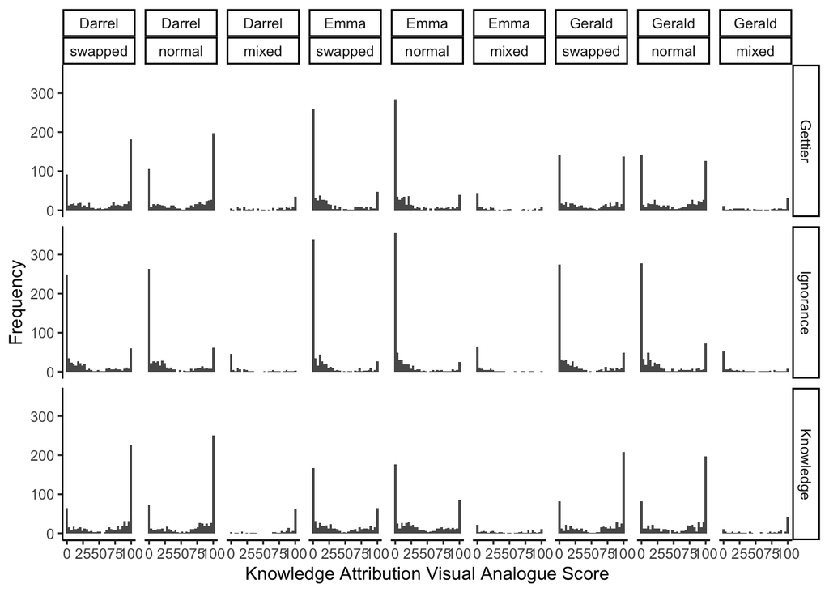

```r
final_long$bin_order <- droplevels(final_long$bin_order)

# visualize the problem
ggplot(final_long, aes(know_vas)) +
  geom_histogram() +
  facet_grid(cond~vignette*bin_order) +
  theme_classic() +
  ylab("Frequency") +
  xlab("Knowledge Attribution Visual Analogue Score")
```

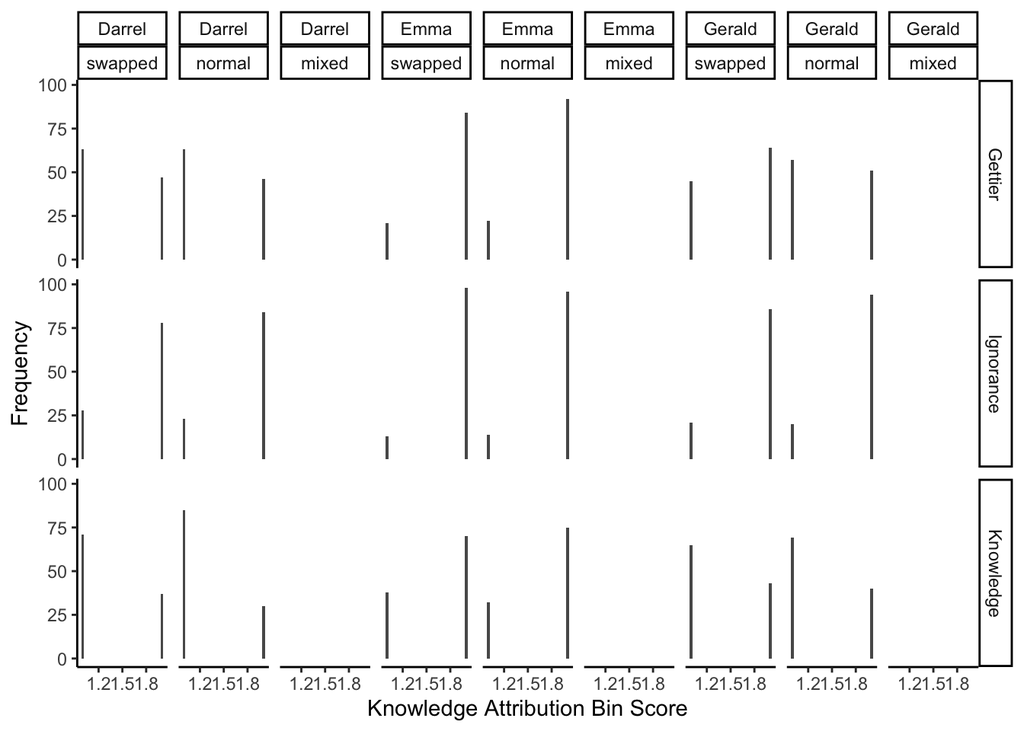

```r
# visualize the problem
ggplot(final_long, aes(know_bin)) +
  geom_histogram() +
  facet_grid(cond~vignette*bin_order) +
  theme_classic() +
  ylab("Frequency") +
  xlab("Knowledge Attribution Bin Score")
```

## Final Analysis Knowledge

### Model 1

Intercept only model to help determine if the addition of random intercepts are useful.

```r
#scores should be 0 and 1 for this analysis
final_long$know_vas_combined <- final_long$know_vas_combined - 1

k.model.1 <- glm(know_vas_combined ~ 1,
               data = final_long,
               family = binomial,
               na.action = "na.omit")

summary(k.model.1)
```

```
##
## Call:
## glm(formula = know_vas_combined ~ 1, family = binomial, data = final_long,
##     na.action = "na.omit")
##
## Deviance Residuals:
##     Min       1Q   Median       3Q      Max
## -1.3693  -1.3693   0.9969   0.9969   0.9969
##
## Coefficients:
##             Estimate Std. Error z value            Pr(>|z|)
## (Intercept)  0.44052    0.01743   25.27 <0.0000000000000002 ***
## ---
## Signif. codes:  0 '***' 0.001 '**' 0.01 '*' 0.05 '.' 0.1 ' ' 1
##
## (Dispersion parameter for binomial family taken to be 1)
##
##     Null deviance: 18493  on 13811  degrees of freedom
## Residual deviance: 18493  on 13811  degrees of freedom
##   (360 observations deleted due to missingness)
## AIC: 18495
##
## Number of Fisher Scoring iterations: 4
```

### Model 2

Vignette random intercept model:

```r
k.model.2 <- glmer(know_vas_combined ~ (1|vignette),
                      data = final_long,
                      family = binomial,
                      control = glmerControl(optimizer = "bobyqa"),
                      nAGQ = 0)
summary(k.model.2)
```

```
## Generalized linear mixed model fit by maximum likelihood (Adaptive
##   Gauss-Hermite Quadrature, nAGQ = 0) [glmerMod]
##  Family: binomial  ( logit )
## Formula: know_vas_combined ~ (1 | vignette)
##    Data: final_long
## Control: glmerControl(optimizer = "bobyqa")
##
##      AIC      BIC   logLik deviance df.resid
##  17465.4  17480.4  -8730.7  17461.4    13810
##
## Scaled residuals:
##     Min      1Q  Median      3Q     Max
## -1.9297 -0.9584  0.5182  0.8899  1.0434
##
## Random effects:
##  Groups   Name        Variance Std.Dev.
##  vignette (Intercept) 0.3601   0.6001
## Number of obs: 13812, groups:  vignette, 3
##
## Fixed effects:
##             Estimate Std. Error z value Pr(>|z|)
## (Intercept)   0.4877     0.3469   1.406     0.16
```

```r
coef(k.model.2) # log odds zero is the center
```

```
## $vignette
##        (Intercept)
## Darrel -0.08498692
## Emma    1.31471531
## Gerald  0.23327365
##
## attr(,"class")
## [1] "coef.mer"
```

```r
exp(coef(k.model.2)$vignette) # regular odds with 1 at the center
```

```
##        (Intercept)
## Darrel   0.9185243
## Emma     3.7236907
## Gerald   1.2627270
```

```r
table(final_long$vignette, final_long$know_vas_combined)
```

```
##
##             0    1
##   Darrel 2405 2206
##   Emma    973 3634
##   Gerald 2031 2563
```

```r
r.squaredGLMM(k.model.2)
```

```
##             R2m        R2c
## theoretical   0 0.09865905
## delta         0 0.07887838
```

- Remember that 0 is knows and 1 is believes
- Model 1 AIC: 18495.3136305
- Model 2 AIC: 17465.382616
- Interpretation: the inclusion of the vignette random variable is useful
- Coefficients: interpretation overall of random intercept, which effectively tells us regardless of condition, which way the participants lean toward answering. See the table printed out to help understand these values.
  - Darrel: fairly even split for knows/believes with a slight favor to knows (because it’s negative goes toward the 0 group)
  - Emma: leans more heavily toward the believes category (almost 4 to 1 odds)
  - Gerald: leans slightly toward the believes category
  - The results here indicate what we were seeing with the “continuous” data as well - that there’s a big difference in the way they respond to vignettes
- This vignette accounts for 8 to 10 percent of the random variance.

### Model 3

Vignette nested in participants random intercept:

```r
k.model.3 <- glmer(know_vas_combined ~ (1|vignette/id),
                      data = final_long,
                      family = binomial,
                      control = glmerControl(optimizer = "bobyqa"),
                      nAGQ = 0)
summary(k.model.3)
```

```
## Generalized linear mixed model fit by maximum likelihood (Adaptive
##   Gauss-Hermite Quadrature, nAGQ = 0) [glmerMod]
##  Family: binomial  ( logit )
## Formula: know_vas_combined ~ (1 | vignette/id)
##    Data: final_long
## Control: glmerControl(optimizer = "bobyqa")
##
##      AIC      BIC   logLik deviance df.resid
##  17467.4  17490.0  -8730.7  17461.4    13809
##
## Scaled residuals:
##     Min      1Q  Median      3Q     Max
## -1.9297 -0.9584  0.5182  0.8899  1.0434
##
## Random effects:
##  Groups      Name        Variance        Std.Dev.
##  id:vignette (Intercept) 0.0000000004509 0.00002123
##  vignette    (Intercept) 0.3600992267091 0.60008268
## Number of obs: 13812, groups:  id:vignette, 13812; vignette, 3
##
## Fixed effects:
##             Estimate Std. Error z value Pr(>|z|)
## (Intercept)   0.4877     0.3469   1.406     0.16
```

```r
r.squaredGLMM(k.model.3)
```

```
##             R2m        R2c
## theoretical   0 0.09865820
## delta         0 0.07887768
```

- Model 2 AIC: 17465.382616
- Model 3 AIC: 17467.3827855
- Interpretation: the inclusion of participant ID isn’t really useful, as the AIC is higher for this model. The variance between participants is very small after accounting for vignettes.
- This model accounts for approximately the same random variance.

### Model 4

Vignette nested in participants which is then nested in labs:

```r
k.model.4 <- glmer(know_vas_combined ~ (1|vignette/id/person_code),
                      data = final_long,
                      family = binomial,
                      control = glmerControl(optimizer = "bobyqa"),
                      nAGQ = 0)
summary(k.model.4)
```

```
## Generalized linear mixed model fit by maximum likelihood (Adaptive
##   Gauss-Hermite Quadrature, nAGQ = 0) [glmerMod]
##  Family: binomial  ( logit )
## Formula: know_vas_combined ~ (1 | vignette/id/person_code)
##    Data: final_long
## Control: glmerControl(optimizer = "bobyqa")
##
##      AIC      BIC   logLik deviance df.resid
##  17469.4  17499.5  -8730.7  17461.4    13808
##
## Scaled residuals:
##     Min      1Q  Median      3Q     Max
## -1.9297 -0.9584  0.5182  0.8899  1.0434
##
## Random effects:
##  Groups                    Name        Variance          Std.Dev.
##  person_code:(id:vignette) (Intercept) 0.000000011462688 0.00010706
##  id:vignette               (Intercept) 0.000000000003422 0.00000185
##  vignette                  (Intercept) 0.360108458190106 0.60009038
## Number of obs: 13812, groups:
## person_code:(id:vignette), 13812; id:vignette, 13812; vignette, 3
##
## Fixed effects:
##             Estimate Std. Error z value Pr(>|z|)
## (Intercept)   0.4877     0.3470   1.406     0.16
```

```r
r.squaredGLMM(k.model.4)
```

```
##             R2m        R2c
## theoretical   0 0.09866049
## delta         0 0.07887956
```

- Model 2 AIC: 17465.382616
- Model 3 AIC: 17467.3827855
- Model 4 AIC: 17469.382616
- Interpretation: the inclusion of lab ID isn’t really useful, as the AIC is higher for this model. The variance parameter for lab is also very small.
- This model accounts for approximately the same random variance.
- We will continue to use this cross classified structure to ensure we account for correlated error and to follow the pre-print.

### Model 5

Addition of the covariates added to the vignette random intercept model.

```r
k.model.5 <- glmer(know_vas_combined ~ (1|vignette/id/person_code) +
                   comp + age + gender2 + education,
                      data = final_long,
                      family = binomial,
                      control = glmerControl(optimizer = "bobyqa"),
                      nAGQ = 0)
summary(k.model.5)
```

```
## Generalized linear mixed model fit by maximum likelihood (Adaptive
##   Gauss-Hermite Quadrature, nAGQ = 0) [glmerMod]
##  Family: binomial  ( logit )
## Formula: know_vas_combined ~ (1 | vignette/id/person_code) + comp + age +
##     gender2 + education
##    Data: final_long
## Control: glmerControl(optimizer = "bobyqa")
##
##      AIC      BIC   logLik deviance df.resid
##  17190.3  17250.4  -8587.1  17174.3    13594
##
## Scaled residuals:
##     Min      1Q  Median      3Q     Max
## -2.1035 -0.9837  0.5131  0.8903  1.1802
##
## Random effects:
##  Groups                    Name        Variance          Std.Dev.
##  person_code:(id:vignette) (Intercept) 0.000000000000245 0.000000495
##  id:vignette               (Intercept) 0.000000001430549 0.000037823
##  vignette                  (Intercept) 0.362005604908351 0.601669016
## Number of obs: 13602, groups:
## person_code:(id:vignette), 13602; id:vignette, 13602; vignette, 3
##
## Fixed effects:
##              Estimate Std. Error z value Pr(>|z|)
## (Intercept)  0.398391   0.364191   1.094   0.2740
## compYes     -0.032111   0.042278  -0.760   0.4475
## age         -0.004483   0.001920  -2.335   0.0195 *
## gender2male  0.073056   0.040213   1.817   0.0693 .
## education    0.014782   0.007085   2.086   0.0369 *
## ---
## Signif. codes:  0 '***' 0.001 '**' 0.01 '*' 0.05 '.' 0.1 ' ' 1
##
## Correlation of Fixed Effects:
##             (Intr) compYs age    gndr2m
## compYes     -0.079
## age         -0.112  0.221
## gender2male -0.028  0.007 -0.091
## education   -0.243 -0.129 -0.127  0.026
```

```r
r.squaredGLMM(k.model.5)
```

```
##                      R2m        R2c
## theoretical 0.0010174377 0.10004531
## delta       0.0008136973 0.08001138
```

```r
tapply(k.model.5@frame$age, k.model.5@frame$know_vas_combined, mean, na.rm = T)
```

```
##        0        1
## 24.83036 24.51346
```

```r
tapply(k.model.5@frame$education, k.model.5@frame$know_vas_combined, mean, na.rm = T)
```

```
##        0        1
## 13.82810 13.90404
```

- Model 4 AIC: 17469.382616
- Model 5 AIC: 17190.2543949
- Interpretation: this model is better than the vignette random intercept only model.
- Age is a negative predictor of knows/believes, such that as age increases, we are more likely to pick knows.
- Education is a positive predictor, so that as education increases we are more likely to pick believes.
- The fixed effects are very small ~ .001.

### Model 6

The previous model of covariates plus the variable of focus: condition.

```r
k.model.6 <- glmer(know_vas_combined ~ (1|vignette/id/person_code) +
                   comp + age + gender2 + education +
                   cond,
                      data = final_long,
                      family = binomial,
                      control = glmerControl(optimizer = "bobyqa"),
                      nAGQ = 0)
summary(k.model.6)
```

```
## Generalized linear mixed model fit by maximum likelihood (Adaptive
##   Gauss-Hermite Quadrature, nAGQ = 0) [glmerMod]
##  Family: binomial  ( logit )
## Formula: know_vas_combined ~ (1 | vignette/id/person_code) + comp + age +
##     gender2 + education + cond
##    Data: final_long
## Control: glmerControl(optimizer = "bobyqa")
##
##      AIC      BIC   logLik deviance df.resid
##  15539.6  15614.7  -7759.8  15519.6    13592
##
## Scaled residuals:
##     Min      1Q  Median      3Q     Max
## -3.8552 -0.7757  0.4872  0.6262  1.7955
##
## Random effects:
##  Groups                    Name        Variance Std.Dev.
##  person_code:(id:vignette) (Intercept) 0.0000   0.0000
##  id:vignette               (Intercept) 0.0000   0.0000
##  vignette                  (Intercept) 0.4491   0.6702
## Number of obs: 13602, groups:
## person_code:(id:vignette), 13602; id:vignette, 13602; vignette, 3
##
## Fixed effects:
##                Estimate Std. Error z value            Pr(>|z|)
## (Intercept)    0.224393   0.404942   0.554              0.5795
## compYes       -0.031543   0.045107  -0.699              0.4844
## age           -0.004903   0.002057  -2.384              0.0171 *
## gender2male    0.090209   0.042916   2.102              0.0356 *
## education      0.016467   0.007565   2.177              0.0295 *
## condIgnorance  1.310275   0.050736  25.826 <0.0000000000000002 ***
## condKnowledge -0.616905   0.044937 -13.728 <0.0000000000000002 ***
## ---
## Signif. codes:  0 '***' 0.001 '**' 0.01 '*' 0.05 '.' 0.1 ' ' 1
##
## Correlation of Fixed Effects:
##             (Intr) compYs age    gndr2m eductn cndIgn
## compYes     -0.075
## age         -0.107  0.222
## gender2male -0.028  0.009 -0.090
## education   -0.233 -0.131 -0.128  0.029
## condIgnornc -0.049  0.000 -0.009  0.012  0.007
## condKnowldg -0.055  0.002  0.004 -0.006 -0.005  0.431
```

```r
table(k.model.6@frame$cond, k.model.6@frame$know_vas_combined)
```

```
##
##                0    1
##   Gettier   1928 2579
##   Ignorance  824 3749
##   Knowledge 2565 1957
```

```r
r.squaredGLMM(k.model.6)
```

```
##                   R2m       R2c
## theoretical 0.1487159 0.2509754
## delta       0.1230688 0.2076930
```

- Model 5 AIC: 17190.2543949
- Model 6 AIC: 15539.5674502
- Interpretation: this model is better than the model with the covariates.
- Both knowledge and ignorance are different than the Gettier condition.
- In Gettier, participants are slightly more likely to say believes.
- In Ignorance, participants are *way* more likely to say believes (so that’s why this condition is different from Gettier).
- In Knowledge, participants are more like to say knows (also why this is different from Gettier).
- This effect accounts for 12-15% of the fixed effect variance.

### Model 6A

Does the vignette interact with the condition?

```r
k.model.6A <- glmer(know_vas_combined ~ (1 | vignette/id/person_code) +
                   comp + age + gender2 + education +
                   cond*vignette,
                      data = final_long,
                      family = binomial,
                      control = glmerControl(optimizer = "bobyqa"),
                      nAGQ = 0)
summary(k.model.6A)
```

```
## Generalized linear mixed model fit by maximum likelihood (Adaptive
##   Gauss-Hermite Quadrature, nAGQ = 0) [glmerMod]
##  Family: binomial  ( logit )
## Formula: know_vas_combined ~ (1 | vignette/id/person_code) + comp + age +
##     gender2 + education + cond * vignette
##    Data: final_long
## Control: glmerControl(optimizer = "bobyqa")
##
##      AIC      BIC   logLik deviance df.resid
##  15479.3  15599.6  -7723.7  15447.3    13586
##
## Scaled residuals:
##     Min      1Q  Median      3Q     Max
## -3.1395 -0.7808  0.4469  0.5773  1.8046
##
## Random effects:
##  Groups                    Name        Variance                Std.Dev.
##  person_code:(id:vignette) (Intercept) 0.000000000000000005085 0.000000002255
##  id:vignette               (Intercept) 0.000000000000000000000 0.000000000000
##  vignette                  (Intercept) 0.000000000000000000000 0.000000000000
## Number of obs: 13602, groups:
## person_code:(id:vignette), 13602; id:vignette, 13602; vignette, 3
##
## Fixed effects:
##                               Estimate Std. Error z value             Pr(>|z|)
## (Intercept)                  -0.520573   0.126969  -4.100     0.00004131509445
## compYes                      -0.029065   0.045310  -0.641             0.521213
## age                          -0.004931   0.002064  -2.390             0.016868
## gender2male                   0.093404   0.043102   2.167             0.030233
## education                     0.016032   0.007596   2.111             0.034805
## condIgnorance                 1.591503   0.080652  19.733 < 0.0000000000000002
## condKnowledge                -0.504796   0.077123  -6.545     0.00000000005937
## vignetteEmma                  1.933063   0.085247  22.676 < 0.0000000000000002
## vignetteGerald                0.402574   0.073872   5.450     0.00000005048927
## condIgnorance:vignetteEmma   -0.950429   0.134271  -7.078     0.00000000000146
## condKnowledge:vignetteEmma   -0.399063   0.115731  -3.448             0.000564
## condIgnorance:vignetteGerald -0.213119   0.114834  -1.856             0.063470
## condKnowledge:vignetteGerald -0.027241   0.107410  -0.254             0.799791
##
## (Intercept)                  ***
## compYes
## age                          *
## gender2male                  *
## education                    *
## condIgnorance                ***
## condKnowledge                ***
## vignetteEmma                 ***
## vignetteGerald               ***
## condIgnorance:vignetteEmma   ***
## condKnowledge:vignetteEmma   ***
## condIgnorance:vignetteGerald .
## condKnowledge:vignetteGerald
## ---
## Signif. codes:  0 '***' 0.001 '**' 0.01 '*' 0.05 '.' 0.1 ' ' 1
```

```
##
## Correlation matrix not shown by default, as p = 13 > 12.
## Use print(x, correlation=TRUE)  or
##     vcov(x)        if you need it
```

```r
r.squaredGLMM(k.model.6A)
```

```
##                   R2m       R2c
## theoretical 0.2392327 0.2392327
## delta       0.1974416 0.1974416
```

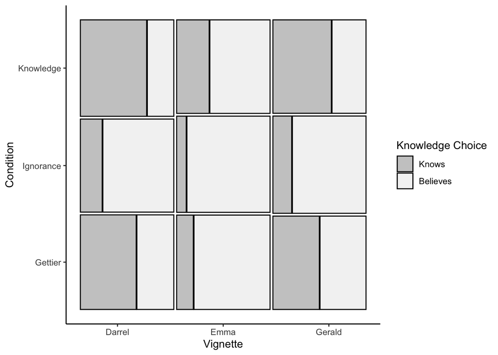

```r
data_graph <- k.model.6A@frame
data_graph$know_vas_combined <- factor(data_graph$know_vas_combined,
                                          levels = c(0,1),
                                          labels = c("Knows", "Believes"))

#graph the three way binary
ggplot(data_graph) +
  geom_mosaic(aes(x = product(know_vas_combined, cond, vignette),
                  fill = know_vas_combined), color = "black", size = .5) +
  scale_fill_brewer(palette = "Greys", name = "Knowledge Choice",
                    direction = -1) +
  theme(text = element_text(size = 15)) +
  scale_x_productlist(breaks = c(0.13,.5,.87),
    labels = c("Darrel", "Emma", "Gerald")) +
  theme_classic() +
  xlab("Vignette") +
  ylab("Condition")
```

- Model 6 AIC: 15539.5674502
- Model 6A AIC: 15479.3220813
- Interpretation: This model is better than a model without the interaction.
- There is an interaction between vignette and condition for choice.
- In looking at the graph, we can see this is driven by the Emma vignette which shows a larger believes box for all conditions.
- This interaction adds a good portion of variance to the fixed effects 7-9%.

To analyze this interaction, we will use chi-square analysis and proportion tests (making sure it’s on the same data as the analysis above).

```r
# overall darrel
chisq.test(data_graph$know_vas_combined[data_graph$vignette == "Darrel"],
           data_graph$cond[data_graph$vignette == "Darrel"])
```

```
##
##  Pearson's Chi-squared test
##
## data:  data_graph$know_vas_combined[data_graph$vignette == "Darrel"] and data_graph$cond[data_graph$vignette == "Darrel"]
## X-squared = 756.71, df = 2, p-value < 0.00000000000000022
```

```r
k.d_table <- table(data_graph$know_vas_combined[data_graph$vignette == "Darrel"],
           data_graph$cond[data_graph$vignette == "Darrel"])
k.d_table
```

```
##
##            Gettier Ignorance Knowledge
##   Knows        910       350      1101
##   Believes     602      1137       440
```

```r
# prop tests
prop1 <- prop.test(t(k.d_table[1:2, 1:2]))
prop1
```

```
##
##  2-sample test for equality of proportions with continuity correction
##
## data:  t(k.d_table[1:2, 1:2])
## X-squared = 411.8, df = 1, p-value < 0.00000000000000022
## alternative hypothesis: two.sided
## 95 percent confidence interval:
##  0.3330437 0.3999135
## sample estimates:
##    prop 1    prop 2
## 0.6018519 0.2353732
```

```r
v.chi.sq(x2 = prop1$statistic,
         n = sum(t(k.d_table[1:2, 1:2])),
         r = 2, c = 2)
```

```
## $v
## X-squared
##  0.370556
##
## $vlow
## [1] 0.3352638
##
## $vhigh
## [1] 0.406756
##
## $n
## [1] 2999
##
## $df
## [1] 1
##
## $x2
## X-squared
##   411.798
##
## $p
##  X-squared
## 1.4885e-91
##
## $estimate
## [1] "$V$ = .37, 95\\% CI [.34, .41]"
##
## $statistic
## [1] "$\\chi^2$(1) = 411.80, $p$ < .001"
```

```r
prop2 <- prop.test(t(k.d_table[1:2, c(1,3)]))
prop2
```

```
##
##  2-sample test for equality of proportions with continuity correction
##
## data:  t(k.d_table[1:2, c(1, 3)])
## X-squared = 42.556, df = 1, p-value = 0.00000000006869
## alternative hypothesis: two.sided
## 95 percent confidence interval:
##  -0.14670120 -0.07853734
## sample estimates:
##    prop 1    prop 2
## 0.6018519 0.7144711
```

```r
v.chi.sq(x2 = prop2$statistic,
         n = sum(t(k.d_table[1:2, c(1,3)])),
         r = 2, c = 2)
```

```
## $v
## X-squared
## 0.1180636
##
## $vlow
## [1] 0.0845514
##
## $vhigh
## [1] 0.1545986
##
## $n
## [1] 3053
##
## $df
## [1] 1
##
## $x2
## X-squared
##  42.55584
##
## $p
##           X-squared
## 0.00000000006869284
##
## $estimate
## [1] "$V$ = .12, 95\\% CI [.08, .15]"
##
## $statistic
## [1] "$\\chi^2$(1) = 42.56, $p$ < .001"
```

- The proportions are the likelihood of Knows for each condition
- Knows more likely in Gettier than Ignorance
- Knows more likely in Knowledge than Gettier

```r
# overall emma
chisq.test(data_graph$know_vas_combined[data_graph$vignette == "Emma"],
           data_graph$cond[data_graph$vignette == "Emma"])
```

```
##
##  Pearson's Chi-squared test
##
## data:  data_graph$know_vas_combined[data_graph$vignette == "Emma"] and data_graph$cond[data_graph$vignette == "Emma"]
## X-squared = 291.71, df = 2, p-value < 0.00000000000000022
```

```r
k.e_table <- table(data_graph$know_vas_combined[data_graph$vignette == "Emma"],
           data_graph$cond[data_graph$vignette == "Emma"])
k.e_table
```

```
##
##            Gettier Ignorance Knowledge
##   Knows        271       159       524
##   Believes    1237      1378       970
```

```r
# prop tests
prop1 <- prop.test(t(k.e_table[1:2, 1:2]))
prop1
```

```
##
##  2-sample test for equality of proportions with continuity correction
##
## data:  t(k.e_table[1:2, 1:2])
## X-squared = 35.876, df = 1, p-value = 0.000000002103
## alternative hypothesis: two.sided
## 95 percent confidence interval:
##  0.05095916 0.10156073
## sample estimates:
##    prop 1    prop 2
## 0.1797082 0.1034483
```

```r
v.chi.sq(x2 = prop1$statistic,
         n = sum(t(k.e_table[1:2, 1:2])),
         r = 2, c = 2)
```

```
## $v
## X-squared
## 0.1085443
##
## $vlow
## [1] 0.07524078
##
## $vhigh
## [1] 0.1451981
##
## $n
## [1] 3045
##
## $df
## [1] 1
##
## $x2
## X-squared
##  35.87577
##
## $p
##         X-squared
## 0.000000002103077
##
## $estimate
## [1] "$V$ = .11, 95\\% CI [.08, .15]"
##
## $statistic
## [1] "$\\chi^2$(1) = 35.88, $p$ < .001"
```

```r
prop2 <- prop.test(t(k.e_table[1:2, c(1,3)]))
prop2
```

```
##
##  2-sample test for equality of proportions with continuity correction
##
## data:  t(k.e_table[1:2, c(1, 3)])
## X-squared = 111.88, df = 1, p-value < 0.00000000000000022
## alternative hypothesis: two.sided
## 95 percent confidence interval:
##  -0.2026950 -0.1393611
## sample estimates:
##    prop 1    prop 2
## 0.1797082 0.3507363
```

```r
v.chi.sq(x2 = prop2$statistic,
         n = sum(t(k.e_table[1:2, c(1,3)])),
         r = 2, c = 2)
```

```
## $v
## X-squared
## 0.1930472
##
## $vlow
## [1] 0.1583307
##
## $vhigh
## [1] 0.2295459
##
## $n
## [1] 3002
##
## $df
## [1] 1
##
## $x2
## X-squared
##  111.8762
##
## $p
##    X-squared
## 3.803336e-26
##
## $estimate
## [1] "$V$ = .19, 95\\% CI [.16, .23]"
##
## $statistic
## [1] "$\\chi^2$(1) = 111.88, $p$ < .001"
```

- Knows more likely in Gettier than Ignorance
- Knows more likely in Knowledge than Gettier

```r
# overall gerald
chisq.test(data_graph$know_vas_combined[data_graph$vignette == "Gerald"],
           data_graph$cond[data_graph$vignette == "Gerald"])
```

```
##
##  Pearson's Chi-squared test
##
## data:  data_graph$know_vas_combined[data_graph$vignette == "Gerald"] and data_graph$cond[data_graph$vignette == "Gerald"]
## X-squared = 597.44, df = 2, p-value < 0.00000000000000022
```

```r
k.g_table <- table(data_graph$know_vas_combined[data_graph$vignette == "Gerald"],
           data_graph$cond[data_graph$vignette == "Gerald"])
k.g_table
```

```
##
##            Gettier Ignorance Knowledge
##   Knows        747       315       940
##   Believes     740      1234       547
```

```r
# prop tests
prop1 <- prop.test(t(k.g_table[1:2, 1:2]))
prop1
```

```
##
##  2-sample test for equality of proportions with continuity correction
##
## data:  t(k.g_table[1:2, 1:2])
## X-squared = 296.9, df = 1, p-value < 0.00000000000000022
## alternative hypothesis: two.sided
## 95 percent confidence interval:
##  0.2659712 0.3320222
## sample estimates:
##    prop 1    prop 2
## 0.5023537 0.2033570
```

```r
v.chi.sq(x2 = prop1$statistic,
         n = sum(t(k.g_table[1:2, 1:2])),
         r = 2, c = 2)
```

```
## $v
## X-squared
## 0.3127184
##
## $vlow
## [1] 0.2777409
##
## $vhigh
## [1] 0.3487621
##
## $n
## [1] 3036
##
## $df
## [1] 1
##
## $x2
## X-squared
##   296.899
##
## $p
##    X-squared
## 1.560939e-66
##
## $estimate
## [1] "$V$ = .31, 95\\% CI [.28, .35]"
##
## $statistic
## [1] "$\\chi^2$(1) = 296.90, $p$ < .001"
```

```r
prop2 <- prop.test(t(k.g_table[1:2, c(1,3)]))
prop2
```

```
##
##  2-sample test for equality of proportions with continuity correction
##
## data:  t(k.g_table[1:2, c(1, 3)])
## X-squared = 50.495, df = 1, p-value = 0.000000000001195
## alternative hypothesis: two.sided
## 95 percent confidence interval:
##  -0.16577061 -0.09381245
## sample estimates:
##    prop 1    prop 2
## 0.5023537 0.6321453
```

```r
v.chi.sq(x2 = prop2$statistic,
         n = sum(t(k.g_table[1:2, c(1,3)])),
         r = 2, c = 2)
```

```
## $v
## X-squared
##  0.130303
##
## $vlow
## [1] 0.0961282
##
## $vhigh
## [1] 0.1672512
##
## $n
## [1] 2974
##
## $df
## [1] 1
##
## $x2
## X-squared
##  50.49516
##
## $p
##            X-squared
## 0.000000000001194588
##
## $estimate
## [1] "$V$ = .13, 95\\% CI [.10, .17]"
##
## $statistic
## [1] "$\\chi^2$(1) = 50.50, $p$ < .001"
```

- Knows more likely in Gettier than Ignorance
- Knows more likely in Knowledge than Gettier
- While all three of these show the same results, we see that their strengths are different for each one using Cramer’s V.

### Model 6B

Data was collected from mechanical turk participants. Are there differences in this data and the complete data on the condition variable?

```r
k.model.6B <- glmer(know_vas_combined ~ (1|vignette/id/person_code) +
                    comp + age + gender2 + education +
                    cond*turk,
                      data = final_long,
                      family = binomial,
                      control = glmerControl(optimizer = "bobyqa"),
                      nAGQ = 0)
summary(k.model.6B)
```

```
## Generalized linear mixed model fit by maximum likelihood (Adaptive
##   Gauss-Hermite Quadrature, nAGQ = 0) [glmerMod]
##  Family: binomial  ( logit )
## Formula: know_vas_combined ~ (1 | vignette/id/person_code) + comp + age +
##     gender2 + education + cond * turk
##    Data: final_long
## Control: glmerControl(optimizer = "bobyqa")
##
##      AIC      BIC   logLik deviance df.resid
##  15519.6  15617.4  -7746.8  15493.6    13589
##
## Scaled residuals:
##     Min      1Q  Median      3Q     Max
## -3.9694 -0.7832  0.4827  0.6259  2.1452
##
## Random effects:
##  Groups                    Name        Variance         Std.Dev.
##  person_code:(id:vignette) (Intercept) 0.00000000000004 0.0000002
##  id:vignette               (Intercept) 0.00000000000400 0.0000020
##  vignette                  (Intercept) 0.45106343489103 0.6716126
## Number of obs: 13602, groups:
## person_code:(id:vignette), 13602; id:vignette, 13602; vignette, 3
##
## Fixed effects:
##                          Estimate Std. Error z value             Pr(>|z|)
## (Intercept)             0.0956499  0.4071214   0.235              0.81425
## compYes                 0.0215269  0.0470434   0.458              0.64724
## age                    -0.0009439  0.0023084  -0.409              0.68262
## gender2male             0.1156540  0.0434729   2.660              0.00781 **
## education               0.0170978  0.0075661   2.260              0.02383 *
## condIgnorance           1.2855571  0.0527195  24.385 < 0.0000000000000002 ***
## condKnowledge          -0.5964738  0.0466877 -12.776 < 0.0000000000000002 ***
## turkTRUE               -0.3110374  0.1270085  -2.449              0.01433 *
## condIgnorance:turkTRUE  0.3367523  0.1932760   1.742              0.08145 .
## condKnowledge:turkTRUE -0.2940321  0.1737176  -1.693              0.09053 .
## ---
## Signif. codes:  0 '***' 0.001 '**' 0.01 '*' 0.05 '.' 0.1 ' ' 1
##
## Correlation of Fixed Effects:
##             (Intr) compYs age    gndr2m eductn cndIgn cndKnw trTRUE cI:TRU
## compYes     -0.095
## age         -0.132  0.319
## gender2male -0.039  0.050 -0.017
## education   -0.233 -0.119 -0.105  0.032
## condIgnornc -0.052  0.005  0.000  0.012  0.007
## condKnowldg -0.056  0.000  0.000 -0.007 -0.006  0.434
## turkTRUE     0.041 -0.193 -0.297 -0.099 -0.016  0.159  0.184
## cndIgn:TRUE  0.013 -0.001  0.001  0.007  0.002 -0.270 -0.120 -0.585
## cndKnw:TRUE  0.014  0.001  0.003 -0.001  0.001 -0.120 -0.266 -0.650  0.427
```

```r
r.squaredGLMM(k.model.6B)
```

```
##                   R2m       R2c
## theoretical 0.1507523 0.2531505
## delta       0.1248166 0.2095979
```

- Model 6 AIC: 15539.5674502
- Model 6A AIC: 15519.635118
- Interpretation: This model is better than a model without the interaction.
- However, the interaction with the turk variable does not produce significant effects.
- The model is likely “better” because of the added variable and main effect of turk (likely drive by sample size differences in the two samples of turk versus not for knows versus believes).
- Therefore, we do not find evidence for differences in the turk sample for condition effects.

### Model 6C

Data was binned because of the distributions of the visual analogue scale - does the data source make a difference?

```r
k.model.6C <- glmer(know_vas_combined ~ (1|vignette/id/person_code) +
                    comp + age + gender2 + education +
                    cond*know_vas_combined_source,
                      data = final_long,
                      family = binomial,
                      control = glmerControl(optimizer = "bobyqa"),
                      nAGQ = 0)
summary(k.model.6C)
```

```
## Generalized linear mixed model fit by maximum likelihood (Adaptive
##   Gauss-Hermite Quadrature, nAGQ = 0) [glmerMod]
##  Family: binomial  ( logit )
## Formula: know_vas_combined ~ (1 | vignette/id/person_code) + comp + age +
##     gender2 + education + cond * know_vas_combined_source
##    Data: final_long
## Control: glmerControl(optimizer = "bobyqa")
##
##      AIC      BIC   logLik deviance df.resid
##  15543.3  15641.0  -7758.6  15517.3    13589
##
## Scaled residuals:
##     Min      1Q  Median      3Q     Max
## -3.8773 -0.7785  0.4867  0.6268  1.8139
##
## Random effects:
##  Groups                    Name        Variance Std.Dev.
##  person_code:(id:vignette) (Intercept) 0.0000   0.0000
##  id:vignette               (Intercept) 0.0000   0.0000
##  vignette                  (Intercept) 0.4493   0.6703
## Number of obs: 13602, groups:
## person_code:(id:vignette), 13602; id:vignette, 13602; vignette, 3
##
## Fixed effects:
##                                            Estimate Std. Error z value
## (Intercept)                                0.280754   0.411836   0.682
## compYes                                   -0.031482   0.045112  -0.698
## age                                       -0.004861   0.002058  -2.362
## gender2male                                0.090001   0.042922   2.097
## education                                  0.016869   0.007573   2.228
## condIgnorance                              1.257055   0.134256   9.363
## condKnowledge                             -0.581148   0.118234  -4.915
## know_vas_combined_sourceVAS               -0.073470   0.090424  -0.813
## condIgnorance:know_vas_combined_sourceVAS  0.062193   0.144833   0.429
## condKnowledge:know_vas_combined_sourceVAS -0.041829   0.127718  -0.328
##                                                       Pr(>|z|)
## (Intercept)                                             0.4954
## compYes                                                 0.4853
## age                                                     0.0182 *
## gender2male                                             0.0360 *
## education                                               0.0259 *
## condIgnorance                             < 0.0000000000000002 ***
## condKnowledge                                      0.000000887 ***
## know_vas_combined_sourceVAS                             0.4165
## condIgnorance:know_vas_combined_sourceVAS               0.6676
## condKnowledge:know_vas_combined_sourceVAS               0.7433
## ---
## Signif. codes:  0 '***' 0.001 '**' 0.01 '*' 0.05 '.' 0.1 ' ' 1
##
## Correlation of Fixed Effects:
##             (Intr) compYs age    gndr2m eductn cndIgn cndKnw k___VA cI:___
## compYes     -0.074
## age         -0.104  0.222
## gender2male -0.028  0.008 -0.090
## education   -0.225 -0.131 -0.127  0.028
## condIgnornc -0.127 -0.001 -0.004  0.002  0.003
## condKnowldg -0.144 -0.001  0.000 -0.001 -0.001  0.440
## knw_vs__VAS -0.181 -0.002 -0.011  0.003 -0.024  0.577  0.655
## cndI:___VAS  0.117  0.001  0.001  0.002 -0.001 -0.926 -0.409 -0.624
## cndK:___VAS  0.133  0.002  0.002 -0.001 -0.001 -0.409 -0.925 -0.707  0.442
```

```r
r.squaredGLMM(k.model.6C)
```

```
##                   R2m       R2c
## theoretical 0.1488742 0.2511539
## delta       0.1232049 0.2078493
```

- Model 6 AIC: 15539.5674502
- Model 6C AIC: 15543.2701743
- Interpretation: This model is not better than a model without the condition interaction.
- There is no evidence for an interaction between condition and the data source, indicating that the binning process did not give us evidence of different results.

## Final Analysis Reasonableness

### Model 1

Intercept only model to help determine if the addition of random intercepts are useful.

```r
#scores should be 0 and 1 for this analysis
final_long$reason_vas_combined <- final_long$reason_vas_combined - 1

r.model.1 <- glm(reason_vas_combined ~ 1,
               data = final_long,
               family = binomial,
               na.action = "na.omit")

summary(r.model.1)
```

```
##
## Call:
## glm(formula = reason_vas_combined ~ 1, family = binomial, data = final_long,
##     na.action = "na.omit")
##
## Deviance Residuals:
##     Min       1Q   Median       3Q      Max
## -0.3887  -0.3887  -0.3887  -0.3887   2.2893
##
## Coefficients:
##             Estimate Std. Error z value            Pr(>|z|)
## (Intercept) -2.54497    0.03266  -77.92 <0.0000000000000002 ***
## ---
## Signif. codes:  0 '***' 0.001 '**' 0.01 '*' 0.05 '.' 0.1 ' ' 1
##
## (Dispersion parameter for binomial family taken to be 1)
##
##     Null deviance: 7245.3  on 13893  degrees of freedom
## Residual deviance: 7245.3  on 13893  degrees of freedom
##   (278 observations deleted due to missingness)
## AIC: 7247.3
##
## Number of Fisher Scoring iterations: 5
```

### Model 2

Vignette random intercept model:

```r
r.model.2 <- glmer(reason_vas_combined ~ (1|vignette),
                      data = final_long,
                      family = binomial,
                      control = glmerControl(optimizer = "bobyqa"),
                      nAGQ = 0)
summary(r.model.2)
```

```
## Generalized linear mixed model fit by maximum likelihood (Adaptive
##   Gauss-Hermite Quadrature, nAGQ = 0) [glmerMod]
##  Family: binomial  ( logit )
## Formula: reason_vas_combined ~ (1 | vignette)
##    Data: final_long
## Control: glmerControl(optimizer = "bobyqa")
##
##      AIC      BIC   logLik deviance df.resid
##   7190.4   7205.5  -3593.2   7186.4    13892
##
## Scaled residuals:
##     Min      1Q  Median      3Q     Max
## -0.3245 -0.3245 -0.2773 -0.2335  4.2824
##
## Random effects:
##  Groups   Name        Variance Std.Dev.
##  vignette (Intercept) 0.07563  0.275
## Number of obs: 13894, groups:  vignette, 3
##
## Fixed effects:
##             Estimate Std. Error z value            Pr(>|z|)
## (Intercept)  -2.5751     0.1623  -15.87 <0.0000000000000002 ***
## ---
## Signif. codes:  0 '***' 0.001 '**' 0.01 '*' 0.05 '.' 0.1 ' ' 1
```

```r
coef(r.model.2) # log odds zero is the center
```

```
## $vignette
##        (Intercept)
## Darrel   -2.909021
## Emma     -2.251051
## Gerald   -2.565369
##
## attr(,"class")
## [1] "coef.mer"
```

```r
exp(coef(r.model.2)$vignette) # regular odds with 1 at the center
```

```
##        (Intercept)
## Darrel  0.05452907
## Emma    0.10528849
## Gerald  0.07689082
```

```r
table(final_long$vignette, final_long$reason_vas_combined)
```

```
##
##             0    1
##   Darrel 4395  235
##   Emma   4172  444
##   Gerald 4316  332
```

```r
r.squaredGLMM(r.model.2)
```

```
##             R2m         R2c
## theoretical   0 0.022472364
## delta         0 0.005085397
```

- Remember that 0 is reasonable, 1 is unreasonable
- Model 1 AIC: 7247.2678036
- Model 2 AIC: 7190.4343572
- Interpretation: the inclusion of the vignette random variable is useful
- Coefficients: interpretation overall of random intercept, which effectively tells us regardless of condition, which way the participants lean toward answering. See the table printed out to help understand these values.
  - We see that they all lean towards reasonable at slightly different strengths.
  - The intercept accounts for only a small amount of random variance, < .01 to .02.

### Model 3

Vignette nested in participants random intercept:

```r
r.model.3 <- glmer(reason_vas_combined ~ (1|vignette/id),
                      data = final_long,
                      family = binomial,
                      control = glmerControl(optimizer = "bobyqa"),
                      nAGQ = 0)
summary(r.model.3)
```

```
## Generalized linear mixed model fit by maximum likelihood (Adaptive
##   Gauss-Hermite Quadrature, nAGQ = 0) [glmerMod]
##  Family: binomial  ( logit )
## Formula: reason_vas_combined ~ (1 | vignette/id)
##    Data: final_long
## Control: glmerControl(optimizer = "bobyqa")
##
##      AIC      BIC   logLik deviance df.resid
##   7192.4   7215.1  -3593.2   7186.4    13891
##
## Scaled residuals:
##     Min      1Q  Median      3Q     Max
## -0.3245 -0.3245 -0.2773 -0.2335  4.2824
##
## Random effects:
##  Groups      Name        Variance        Std.Dev.
##  id:vignette (Intercept) 0.0000000004942 0.00002223
##  vignette    (Intercept) 0.0756206873824 0.27499216
## Number of obs: 13894, groups:  id:vignette, 13894; vignette, 3
##
## Fixed effects:
##             Estimate Std. Error z value            Pr(>|z|)
## (Intercept)  -2.5751     0.1623  -15.87 <0.0000000000000002 ***
## ---
## Signif. codes:  0 '***' 0.001 '**' 0.01 '*' 0.05 '.' 0.1 ' ' 1
```

```r
r.squaredGLMM(r.model.3)
```

```
##             R2m         R2c
## theoretical   0 0.022469452
## delta         0 0.005084709
```

- Model 2 AIC: 7190.4343572
- Model 3 AIC: 7192.4352541
- Interpretation: the inclusion of participant ID isn’t really useful, as the AIC is higher for this model. The variance between participants is very small after accounting for vignettes.
- This model accounts for approximately the same random variance.

### Model 4

Vignette nested in participants which is then nested in labs:

```r
r.model.4 <- glmer(reason_vas_combined ~ (1|vignette/id/person_code),
                      data = final_long,
                      family = binomial,
                      control = glmerControl(optimizer = "bobyqa"),
                      nAGQ = 0)
summary(r.model.4)
```

```
## Generalized linear mixed model fit by maximum likelihood (Adaptive
##   Gauss-Hermite Quadrature, nAGQ = 0) [glmerMod]
##  Family: binomial  ( logit )
## Formula: reason_vas_combined ~ (1 | vignette/id/person_code)
##    Data: final_long
## Control: glmerControl(optimizer = "bobyqa")
##
##      AIC      BIC   logLik deviance df.resid
##   7194.4   7224.6  -3593.2   7186.4    13890
##
## Scaled residuals:
##     Min      1Q  Median      3Q     Max
## -0.3245 -0.3245 -0.2773 -0.2335  4.2824
##
## Random effects:
##  Groups                    Name        Variance       Std.Dev.
##  person_code:(id:vignette) (Intercept) 0.000000006206 0.00007878
##  id:vignette               (Intercept) 0.000000000000 0.00000000
##  vignette                  (Intercept) 0.075621185704 0.27499306
## Number of obs: 13894, groups:
## person_code:(id:vignette), 13894; id:vignette, 13894; vignette, 3
##
## Fixed effects:
##             Estimate Std. Error z value            Pr(>|z|)
## (Intercept)  -2.5751     0.1623  -15.87 <0.0000000000000002 ***
## ---
## Signif. codes:  0 '***' 0.001 '**' 0.01 '*' 0.05 '.' 0.1 ' ' 1
```

```r
r.squaredGLMM(r.model.4)
```

```
##             R2m         R2c
## theoretical   0 0.022469598
## delta         0 0.005084744
```

- Model 2 AIC: 7190.4343572
- Model 3 AIC: 7192.4352541
- Model 4 AIC: 7194.4342345
- Interpretation: the inclusion of lab ID isn’t really useful, as the AIC is higher for this model. The variance parameter for lab is also very small.
- This model accounts for approximately the same random variance.
- We will continue to use this cross classified structure to ensure we account for correlated error and to follow the pre-print.

### Model 5

Addition of the covariates added to the vignette random intercept model.

```r
r.model.5 <- glmer(reason_vas_combined ~ (1|vignette/id/person_code) +
                   comp + age + gender2 + education,
                      data = final_long,
                      family = binomial,
                      control = glmerControl(optimizer = "bobyqa"),
                      nAGQ = 0)
summary(r.model.5)
```

```
## Generalized linear mixed model fit by maximum likelihood (Adaptive
##   Gauss-Hermite Quadrature, nAGQ = 0) [glmerMod]
##  Family: binomial  ( logit )
## Formula: reason_vas_combined ~ (1 | vignette/id/person_code) + comp +
##     age + gender2 + education
##    Data: final_long
## Control: glmerControl(optimizer = "bobyqa")
##
##      AIC      BIC   logLik deviance df.resid
##   7048.5   7108.6  -3516.2   7032.5    13670
##
## Scaled residuals:
##     Min      1Q  Median      3Q     Max
## -0.5653 -0.3043 -0.2655 -0.2276  5.2768
##
## Random effects:
##  Groups                    Name        Variance         Std.Dev.
##  person_code:(id:vignette) (Intercept) 0.00000000207324 0.000045533
##  id:vignette               (Intercept) 0.00000000002226 0.000004718
##  vignette                  (Intercept) 0.07806724998470 0.279405172
## Number of obs: 13678, groups:
## person_code:(id:vignette), 13678; id:vignette, 13678; vignette, 3
##
## Fixed effects:
##              Estimate Std. Error z value          Pr(>|z|)
## (Intercept) -1.792608   0.243616  -7.358 0.000000000000186 ***
## compYes     -0.222451   0.072838  -3.054           0.00226 **
## age          0.005553   0.003256   1.706           0.08808 .
## gender2male  0.180775   0.070498   2.564           0.01034 *
## education   -0.059896   0.011761  -5.093 0.000000353243368 ***
## ---
## Signif. codes:  0 '***' 0.001 '**' 0.01 '*' 0.05 '.' 0.1 ' ' 1
##
## Correlation of Fixed Effects:
##             (Intr) compYs age    gndr2m
## compYes     -0.210
## age         -0.305  0.226
## gender2male -0.083  0.009 -0.093
## education   -0.597 -0.106 -0.107  0.025
```

```r
table(r.model.5@frame$comp, r.model.5@frame$reason_vas_combined)
```

```
##
##          0    1
##   No  3402  327
##   Yes 9279  670
```

```r
table(r.model.5@frame$gender2, r.model.5@frame$reason_vas_combined)
```

```
##
##             0    1
##   female 8975  662
##   male   3706  335
```

```r
tapply(r.model.5@frame$education, r.model.5@frame$reason_vas_combined, mean, na.rm = T)
```

```
##        0        1
## 13.91609 13.46038
```

```r
r.squaredGLMM(r.model.5)
```

```
##                     R2m         R2c
## theoretical 0.014443805 0.037288562
## delta       0.003307344 0.008538339
```

### Model 6

The previous model of covariates plus the variable of focus: condition.

```r
r.model.6 <- glmer(reason_vas_combined ~ (1|vignette/id/person_code) +
                   comp + age + gender2 + education +
                   cond,
                      data = final_long,
                      family = binomial,
                      control = glmerControl(optimizer = "bobyqa"),
                      nAGQ = 0)
summary(r.model.6)
```

```
## Generalized linear mixed model fit by maximum likelihood (Adaptive
##   Gauss-Hermite Quadrature, nAGQ = 0) [glmerMod]
##  Family: binomial  ( logit )
## Formula: reason_vas_combined ~ (1 | vignette/id/person_code) + comp +
##     age + gender2 + education + cond
##    Data: final_long
## Control: glmerControl(optimizer = "bobyqa")
##
##      AIC      BIC   logLik deviance df.resid
##   6956.1   7031.4  -3468.1   6936.1    13668
##
## Scaled residuals:
##     Min      1Q  Median      3Q     Max
## -0.5927 -0.3084 -0.2554 -0.2110  6.5529
##
## Random effects:
##  Groups                    Name        Variance   Std.Dev.
##  person_code:(id:vignette) (Intercept) 0.00982194 0.09911
##  id:vignette               (Intercept) 0.00007604 0.00872
##  vignette                  (Intercept) 0.07729252 0.27802
## Number of obs: 13678, groups:
## person_code:(id:vignette), 13678; id:vignette, 13678; vignette, 3
##
## Fixed effects:
##                Estimate Std. Error z value          Pr(>|z|)
## (Intercept)   -1.837817   0.248688  -7.390 0.000000000000147 ***
## compYes       -0.225806   0.073170  -3.086           0.00203 **
## age            0.005478   0.003271   1.674           0.09404 .
## gender2male    0.182269   0.070820   2.574           0.01006 *
## education     -0.060086   0.011835  -5.077 0.000000383060398 ***
## condIgnorance  0.411855   0.076629   5.375 0.000000076741134 ***
## condKnowledge -0.393717   0.090887  -4.332 0.000014780999073 ***
## ---
## Signif. codes:  0 '***' 0.001 '**' 0.01 '*' 0.05 '.' 0.1 ' ' 1
##
## Correlation of Fixed Effects:
##             (Intr) compYs age    gndr2m eductn cndIgn
## compYes     -0.206
## age         -0.300  0.226
## gender2male -0.081  0.008 -0.094
## education   -0.589 -0.106 -0.106  0.024
## condIgnornc -0.180 -0.005  0.001  0.002  0.000
## condKnowldg -0.157  0.002  0.002 -0.002  0.006  0.493
```

```r
table(r.model.6@frame$cond, r.model.6@frame$reason_vas_combined)
```

```
##
##                0    1
##   Gettier   4236  316
##   Ignorance 4099  462
##   Knowledge 4346  219
```

```r
r.squaredGLMM(r.model.6)
```

```
##                    R2m        R2c
## theoretical 0.04475037 0.06941346
## delta       0.01051754 0.01631403
```

- Model 5 AIC: 7048.4549622
- Model 6 AIC: 6956.1229864
- Interpretation: this model is better than the model with the covariates.
- Both knowledge and ignorance are different than the Gettier condition.
- In Ignorance, participants are likely to say reasonable … but in Gettier, they are more likely to say reasonable.
- In Knowledge, participants are more like to say reasonable than the Gettier condition.
- This effect accounts for 1-4% of the fixed effect variance.

### Model 6A

Does the vignette interact with the condition?

```r
r.model.6A <- glmer(reason_vas_combined ~ (1 | vignette/id/person_code) +
                   comp + age + gender2 + education +
                   cond*vignette,
                      data = final_long,
                      family = binomial,
                      control = glmerControl(optimizer = "bobyqa"),
                      nAGQ = 0)
summary(r.model.6A)
```

```
## Generalized linear mixed model fit by maximum likelihood (Adaptive
##   Gauss-Hermite Quadrature, nAGQ = 0) [glmerMod]
##  Family: binomial  ( logit )
## Formula: reason_vas_combined ~ (1 | vignette/id/person_code) + comp +
##     age + gender2 + education + cond * vignette
##    Data: final_long
## Control: glmerControl(optimizer = "bobyqa")
##
##      AIC      BIC   logLik deviance df.resid
##   6933.3   7053.7  -3450.7   6901.3    13662
##
## Scaled residuals:
##     Min      1Q  Median      3Q     Max
## -0.5623 -0.3197 -0.2577 -0.2015  7.3982
##
## Random effects:
##  Groups                    Name        Variance      Std.Dev.
##  person_code:(id:vignette) (Intercept) 0.00000002967 0.0001722
##  id:vignette               (Intercept) 0.00269937768 0.0519555
##  vignette                  (Intercept) 0.00000000000 0.0000000
## Number of obs: 13678, groups:
## person_code:(id:vignette), 13678; id:vignette, 13678; vignette, 3
##
## Fixed effects:
##                               Estimate Std. Error z value             Pr(>|z|)
## (Intercept)                  -2.425210   0.222935 -10.879 < 0.0000000000000002
## compYes                      -0.222982   0.073232  -3.045              0.00233
## age                           0.005558   0.003281   1.694              0.09031
## gender2male                   0.183308   0.070849   2.587              0.00967
## education                    -0.060936   0.011845  -5.145       0.000000268073
## condIgnorance                 0.882569   0.161746   5.457       0.000000048561
## condKnowledge                -0.365685   0.205407  -1.780              0.07503
## vignetteEmma                  1.117633   0.156739   7.131       0.000000000001
## vignetteGerald                0.495672   0.170823   2.902              0.00371
## condIgnorance:vignetteEmma   -0.777357   0.198325  -3.920       0.000088689286
## condKnowledge:vignetteEmma   -0.253044   0.246140  -1.028              0.30393
## condIgnorance:vignetteGerald -0.396129   0.212331  -1.866              0.06209
## condKnowledge:vignetteGerald  0.259122   0.257578   1.006              0.31442
##
## (Intercept)                  ***
## compYes                      **
## age                          .
## gender2male                  **
## education                    ***
## condIgnorance                ***
## condKnowledge                .
## vignetteEmma                 ***
## vignetteGerald               **
## condIgnorance:vignetteEmma   ***
## condKnowledge:vignetteEmma
## condIgnorance:vignetteGerald .
## condKnowledge:vignetteGerald
## ---
## Signif. codes:  0 '***' 0.001 '**' 0.01 '*' 0.05 '.' 0.1 ' ' 1
```

```
##
## Correlation matrix not shown by default, as p = 13 > 12.
## Use print(x, correlation=TRUE)  or
##     vcov(x)        if you need it
```

```r
r.squaredGLMM(r.model.6A)
```

```
##                    R2m        R2c
## theoretical 0.08364728 0.08439855
## delta       0.01990455 0.02008332
```

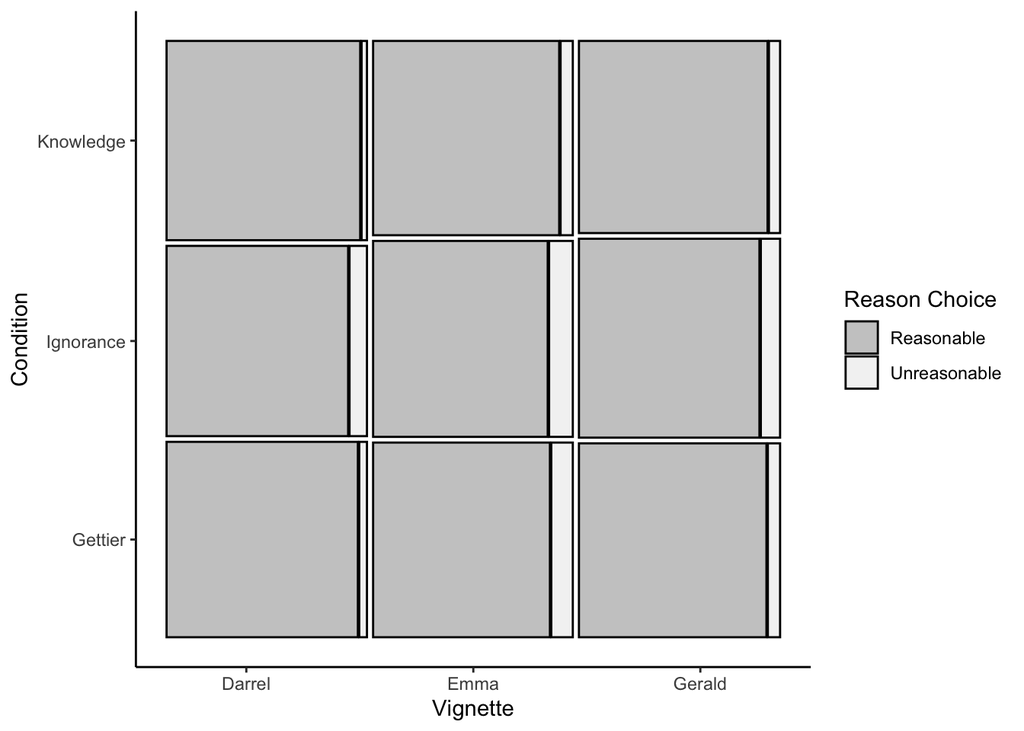

```r
r.data_graph <- r.model.6A@frame
r.data_graph$reason_vas_combined <- factor(r.data_graph$reason_vas_combined,
                                          levels = c(0,1),
                                          labels = c("Reasonable", "Unreasonable"))

#graph the three way binary
ggplot(r.data_graph) +
  geom_mosaic(aes(x = product(reason_vas_combined, cond, vignette),
                  fill = reason_vas_combined), color = "black", size = .5) +
  scale_fill_brewer(palette = "Greys", name = "Reason Choice",
                    direction = -1) +
  scale_x_productlist(breaks = c(0.13,.5,.87),
    labels = c("Darrel", "Emma", "Gerald")) +
  theme_classic() +
  xlab("Vignette") +
  ylab("Condition")
```

- Model 6 AIC: 6956.1229864
- Model 6A AIC: 6933.3373915
- Interpretation: This model is better than a model without the interaction.
- There is an interaction between vignette and condition for choice.
- In looking at the graph, we can see this is driven by the Emma vignette which shows a larger unreasonable box for all conditions.
- This interaction adds a portion of variance to the fixed effects 1-5%.

To analyze this interaction, we will use chi-square analysis and proportion tests (making sure it’s on the same data as the analysis above).

```r
# overall darrel
chisq.test(r.data_graph$reason_vas_combined[r.data_graph$vignette == "Darrel"],
           r.data_graph$cond[r.data_graph$vignette == "Darrel"])
```

```
##
##  Pearson's Chi-squared test
##
## data:  r.data_graph$reason_vas_combined[r.data_graph$vignette == "Darrel"] and r.data_graph$cond[r.data_graph$vignette == "Darrel"]
## X-squared = 64.712, df = 2, p-value = 0.00000000000000887
```

```r
r.d_table <- table(r.data_graph$reason_vas_combined[r.data_graph$vignette == "Darrel"],
           r.data_graph$cond[r.data_graph$vignette == "Darrel"])
r.d_table
```

```
##
##                Gettier Ignorance Knowledge
##   Reasonable      1464      1353      1511
##   Unreasonable      59       130        42
```

```r
# prop tests
prop1 <- prop.test(t(r.d_table[1:2, 1:2]))
prop1
```

```
##
##  2-sample test for equality of proportions with continuity correction
##
## data:  t(r.d_table[1:2, 1:2])
## X-squared = 29.694, df = 1, p-value = 0.00000005058
## alternative hypothesis: two.sided
## 95 percent confidence interval:
##  0.03090340 0.06693823
## sample estimates:
##    prop 1    prop 2
## 0.9612607 0.9123399
```

```r
v.chi.sq(x2 = prop1$statistic,
         n = sum(t(r.d_table[1:2, 1:2])),
         r = 2, c = 2)
```

```
## $v
## X-squared
## 0.0993898
##
## $vlow
## [1] 0.06620368
##
## $vhigh
## [1] 0.1363632
##
## $n
## [1] 3006
##
## $df
## [1] 1
##
## $x2
## X-squared
##  29.69426
##
## $p
##        X-squared
## 0.00000005058426
##
## $estimate
## [1] "$V$ = .10, 95\\% CI [.07, .14]"
##
## $statistic
## [1] "$\\chi^2$(1) = 29.69, $p$ < .001"
```

```r
prop2 <- prop.test(t(r.d_table[1:2, c(1,3)]))
prop2
```

```
##
##  2-sample test for equality of proportions with continuity correction
##
## data:  t(r.d_table[1:2, c(1, 3)])
## X-squared = 2.9536, df = 1, p-value = 0.08569
## alternative hypothesis: two.sided
## 95 percent confidence interval:
##  -0.024955233  0.001565432
## sample estimates:
##    prop 1    prop 2
## 0.9612607 0.9729556
```

```r
v.chi.sq(x2 = prop2$statistic,
         n = sum(t(r.d_table[1:2, c(1,3)])),
         r = 2, c = 2)
```

```
## $v
##  X-squared
## 0.03098726
##
## $vlow
## [1] 0.01803046
##
## $vhigh
## [1] 0.06873337
##
## $n
## [1] 3076
##
## $df
## [1] 1
##
## $x2
## X-squared
##  2.953607
##
## $p
##  X-squared
## 0.08568611
##
## $estimate
## [1] "$V$ = .03, 95\\% CI [.02, .07]"
##
## $statistic
## [1] "$\\chi^2$(1) = 2.95, $p$ = .086"
```

- The proportions are the likelihood of Reasonable for each condition
- Reasonable more likely in Gettier than Ignorance
- No differences for reasonable in the Gettier and Knowledge Condition

```r
# overall emma
chisq.test(r.data_graph$reason_vas_combined[r.data_graph$vignette == "Emma"],
           r.data_graph$cond[r.data_graph$vignette == "Emma"])
```

```
##
##  Pearson's Chi-squared test
##
## data:  r.data_graph$reason_vas_combined[r.data_graph$vignette == "Emma"] and r.data_graph$cond[r.data_graph$vignette == "Emma"]
## X-squared = 32.785, df = 2, p-value = 0.00000007602
```

```r
r.e_table <- table(r.data_graph$reason_vas_combined[r.data_graph$vignette == "Emma"],
           r.data_graph$cond[r.data_graph$vignette == "Emma"])
r.e_table
```

```
##
##                Gettier Ignorance Knowledge
##   Reasonable      1348      1340      1416
##   Unreasonable     164       182        93
```

```r
# prop tests
prop1 <- prop.test(t(r.e_table[1:2, 1:2]))
prop1
```

```
##
##  2-sample test for equality of proportions with continuity correction
##
## data:  t(r.e_table[1:2, 1:2])
## X-squared = 0.82054, df = 1, p-value = 0.365
## alternative hypothesis: two.sided
## 95 percent confidence interval:
##  -0.01215958  0.03438737
## sample estimates:
##    prop 1    prop 2
## 0.8915344 0.8804205
```

```r
v.chi.sq(x2 = prop1$statistic,
         n = sum(t(r.e_table[1:2, 1:2])),
         r = 2, c = 2)
```

```
## $v
## X-squared
## 0.0164453
##
## $vlow
## [1] 0.01815483
##
## $vhigh
## [1] 0.05508076
##
## $n
## [1] 3034
##
## $df
## [1] 1
##
## $x2
## X-squared
## 0.8205384
##
## $p
## X-squared
## 0.3650228
##
## $estimate
## [1] "$V$ = .02, 95\\% CI [.02, .06]"
##
## $statistic
## [1] "$\\chi^2$(1) = 0.82, $p$ = .365"
```

```r
prop2 <- prop.test(t(r.e_table[1:2, c(1,3)]))
prop2
```

```
##
##  2-sample test for equality of proportions with continuity correction
##
## data:  t(r.e_table[1:2, c(1, 3)])
## X-squared = 20.687, df = 1, p-value = 0.000005407
## alternative hypothesis: two.sided
## 95 percent confidence interval:
##  -0.06731926 -0.02635152
## sample estimates:
##    prop 1    prop 2
## 0.8915344 0.9383698
```

```r
v.chi.sq(x2 = prop2$statistic,
         n = sum(t(r.e_table[1:2, c(1,3)])),
         r = 2, c = 2)
```

```
## $v
## X-squared
## 0.0827516
##
## $vlow
## [1] 0.05048466
##
## $vhigh
## [1] 0.1198005
##
## $n
## [1] 3021
##
## $df
## [1] 1
##
## $x2
## X-squared
##  20.68728
##
## $p
##     X-squared
## 0.00000540739
##
## $estimate
## [1] "$V$ = .08, 95\\% CI [.05, .12]"
##
## $statistic
## [1] "$\\chi^2$(1) = 20.69, $p$ < .001"
```

- No differences in Gettier and Ignorance
- Reasonable more likely in the Knowledge Condition than Gettier

```r
# overall gerald
chisq.test(r.data_graph$reason_vas_combined[r.data_graph$vignette == "Gerald"],
           r.data_graph$cond[r.data_graph$vignette == "Gerald"])
```

```
##
##  Pearson's Chi-squared test
##
## data:  r.data_graph$reason_vas_combined[r.data_graph$vignette == "Gerald"] and r.data_graph$cond[r.data_graph$vignette == "Gerald"]
## X-squared = 22.437, df = 2, p-value = 0.00001342
```

```r
r.g_table <- table(r.data_graph$reason_vas_combined[r.data_graph$vignette == "Gerald"],
           r.data_graph$cond[r.data_graph$vignette == "Gerald"])
r.g_table
```

```
##
##                Gettier Ignorance Knowledge
##   Reasonable      1424      1406      1419
##   Unreasonable      93       150        84
```

```r
# prop tests
prop1 <- prop.test(t(r.g_table[1:2, 1:2]))
prop1
```

```
##
##  2-sample test for equality of proportions with continuity correction
##
## data:  t(r.g_table[1:2, 1:2])
## X-squared = 12.515, df = 1, p-value = 0.0004038
## alternative hypothesis: two.sided
## 95 percent confidence interval:
##  0.01545076 0.05474088
## sample estimates:
##    prop 1    prop 2
## 0.9386948 0.9035990
```

```r
v.chi.sq(x2 = prop1$statistic,
         n = sum(t(r.g_table[1:2, 1:2])),
         r = 2, c = 2)
```

```
## $v
##  X-squared
## 0.06381547
##
## $vlow
## [1] 0.03369476
##
## $vhigh
## [1] 0.1007991
##
## $n
## [1] 3073
##
## $df
## [1] 1
##
## $x2
## X-squared
##  12.51453
##
## $p
##    X-squared
## 0.0004037995
##
## $estimate
## [1] "$V$ = .06, 95\\% CI [.03, .10]"
##
## $statistic
## [1] "$\\chi^2$(1) = 12.51, $p$ < .001"
```

```r
prop2 <- prop.test(t(r.g_table[1:2, c(1,3)]))
prop2
```

```
##
##  2-sample test for equality of proportions with continuity correction
##
## data:  t(r.g_table[1:2, c(1, 3)])
## X-squared = 0.30935, df = 1, p-value = 0.5781
## alternative hypothesis: two.sided
## 95 percent confidence interval:
##  -0.02282988  0.01199592
## sample estimates:
##    prop 1    prop 2
## 0.9386948 0.9441118
```

```r
v.chi.sq(x2 = prop2$statistic,
         n = sum(t(r.g_table[1:2, c(1,3)])),
         r = 2, c = 2)
```

```
## $v
##  X-squared
## 0.01012097
##
## $vlow
## [1] 0.01819686
##
## $vhigh
## [1] 0.04894847
##
## $n
## [1] 3020
##
## $df
## [1] 1
##
## $x2
## X-squared
## 0.3093506
##
## $p
## X-squared
##  0.578079
##
## $estimate
## [1] "$V$ = .01, 95\\% CI [.02, .05]"
##
## $statistic
## [1] "$\\chi^2$(1) = 0.31, $p$ = .578"
```

- Reasonable more likely in the Gettier than the Ignorance
- No differences in the Geitter and the Knowledge conditions

### Model 6B

Data was collected from mechanical turk participants. Are there differences in this data and the complete data on the condition variable?

```r
r.model.6B <- glmer(reason_vas_combined ~ (1|vignette/id/person_code) +
                    comp + age + gender2 + education +
                    cond*turk,
                      data = final_long,
                      family = binomial,
                      control = glmerControl(optimizer = "bobyqa"),
                      nAGQ = 0)
summary(r.model.6B)
```

```
## Generalized linear mixed model fit by maximum likelihood (Adaptive
##   Gauss-Hermite Quadrature, nAGQ = 0) [glmerMod]
##  Family: binomial  ( logit )
## Formula: reason_vas_combined ~ (1 | vignette/id/person_code) + comp +
##     age + gender2 + education + cond * turk
##    Data: final_long
## Control: glmerControl(optimizer = "bobyqa")
##
##      AIC      BIC   logLik deviance df.resid
##   6925.6   7023.4  -3449.8   6899.6    13665
##
## Scaled residuals:
##     Min      1Q  Median      3Q     Max
## -0.7197 -0.3098 -0.2566 -0.2075  8.4169
##
## Random effects:
##  Groups                    Name        Variance    Std.Dev.
##  person_code:(id:vignette) (Intercept) 0.002796908 0.052886
##  id:vignette               (Intercept) 0.000004642 0.002154
##  vignette                  (Intercept) 0.077527887 0.278438
## Number of obs: 13678, groups:
## person_code:(id:vignette), 13678; id:vignette, 13678; vignette, 3
##
## Fixed effects:
##                         Estimate Std. Error z value             Pr(>|z|)
## (Intercept)            -2.126092   0.253593  -8.384 < 0.0000000000000002 ***
## compYes                -0.096333   0.076927  -1.252             0.210474
## age                     0.013681   0.003468   3.945          0.000079935 ***
## gender2male             0.233281   0.071258   3.274             0.001061 **
## education              -0.056729   0.011684  -4.855          0.000001203 ***
## condIgnorance           0.389737   0.078177   4.985          0.000000619 ***
## condKnowledge          -0.407434   0.092538  -4.403          0.000010682 ***
## turkTRUE               -1.395488   0.369752  -3.774             0.000161 ***
## condIgnorance:turkTRUE  0.646086   0.428111   1.509             0.131259
## condKnowledge:turkTRUE  0.413046   0.514885   0.802             0.422432
## ---
## Signif. codes:  0 '***' 0.001 '**' 0.01 '*' 0.05 '.' 0.1 ' ' 1
##
## Correlation of Fixed Effects:
##             (Intr) compYs age    gndr2m eductn cndIgn cndKnw trTRUE cI:TRU
## compYes     -0.266
## age         -0.354  0.349
## gender2male -0.110  0.048 -0.035
## education   -0.579 -0.090 -0.080  0.035
## condIgnornc -0.180 -0.003  0.004  0.004  0.001
## condKnowldg -0.155  0.001  0.000 -0.003  0.007  0.489
## turkTRUE     0.057 -0.121 -0.166 -0.049 -0.017  0.122  0.103
## cndIgn:TRUE  0.033  0.001  0.001 -0.002 -0.001 -0.183 -0.089 -0.833
## cndKnw:TRUE  0.028  0.000  0.001  0.002 -0.003 -0.088 -0.180 -0.693  0.598
```

```r
r.squaredGLMM(r.model.6B)
```

```
##                    R2m        R2c
## theoretical 0.06148547 0.08385518
## delta       0.01462436 0.01994501
```

- Model 6 AIC: 6956.1229864
- Model 6A AIC: 6925.5990451
- Interpretation: This model is better than a model without the interaction.
- However, the interaction with the turk variable does not produce significant effects.
- The model is likely “better” because of the added variable and main effect of turk (likely drive by sample size differences in the two samples of turk versus not for knows versus believes).
- Therefore, we do not find evidence for differences in the turk sample for condition effects.

### Model 6C

Data was binned because of the distributions of the visual analogue scale - does the data source make a difference?

```r
r.model.6C <- glmer(reason_vas_combined ~ (1|vignette/id/person_code) +
                    comp + age + gender2 + education +
                    cond*reason_vas_combined_source,
                      data = final_long,
                      family = binomial,
                      control = glmerControl(optimizer = "bobyqa"),
                      nAGQ = 0)
summary(r.model.6C)
```

```
## Generalized linear mixed model fit by maximum likelihood (Adaptive
##   Gauss-Hermite Quadrature, nAGQ = 0) [glmerMod]
##  Family: binomial  ( logit )
## Formula: reason_vas_combined ~ (1 | vignette/id/person_code) + comp +
##     age + gender2 + education + cond * reason_vas_combined_source
##    Data: final_long
## Control: glmerControl(optimizer = "bobyqa")
##
##      AIC      BIC   logLik deviance df.resid
##   6949.5   7047.3  -3461.7   6923.5    13665
##
## Scaled residuals:
##     Min      1Q  Median      3Q     Max
## -0.5940 -0.3078 -0.2550 -0.2094  6.6124
##
## Random effects:
##  Groups                    Name        Variance      Std.Dev.
##  person_code:(id:vignette) (Intercept) 0.01353103432 0.1163230
##  id:vignette               (Intercept) 0.00000004131 0.0002032
##  vignette                  (Intercept) 0.07744617097 0.2782915
## Number of obs: 13678, groups:
## person_code:(id:vignette), 13678; id:vignette, 13678; vignette, 3
##
## Fixed effects:
##                                              Estimate Std. Error z value
## (Intercept)                                 -1.562472   0.276212  -5.657
## compYes                                     -0.222737   0.073329  -3.037
## age                                          0.005800   0.003288   1.764
## gender2male                                  0.180876   0.070845   2.553
## education                                   -0.058926   0.011943  -4.934
## condIgnorance                                0.354598   0.181010   1.959
## condKnowledge                               -0.438736   0.213211  -2.058
## reason_vas_combined_sourceVAS               -0.359895   0.151087  -2.382
## condIgnorance:reason_vas_combined_sourceVAS  0.070719   0.199835   0.354
## condKnowledge:reason_vas_combined_sourceVAS  0.054981   0.235730   0.233
##                                                 Pr(>|z|)
## (Intercept)                                 0.0000000154 ***
## compYes                                          0.00239 **
## age                                              0.07768 .
## gender2male                                      0.01068 *
## education                                   0.0000008053 ***
## condIgnorance                                    0.05011 .
## condKnowledge                                    0.03961 *
## reason_vas_combined_sourceVAS                    0.01722 *
## condIgnorance:reason_vas_combined_sourceVAS      0.72342
## condKnowledge:reason_vas_combined_sourceVAS      0.81558
## ---
## Signif. codes:  0 '***' 0.001 '**' 0.01 '*' 0.05 '.' 0.1 ' ' 1
##
## Correlation of Fixed Effects:
##             (Intr) compYs age    gndr2m eductn cndIgn cndKnw r___VA cI:___
## compYes     -0.180
## age         -0.263  0.229
## gender2male -0.075  0.008 -0.090
## education   -0.525 -0.113 -0.109  0.025
## condIgnornc -0.370 -0.002  0.002  0.001 -0.004
## condKnowldg -0.317  0.002  0.004 -0.003  0.000  0.482
## rsn_vs__VAS -0.429 -0.006 -0.015  0.002 -0.019  0.680  0.577
## cndI:___VAS  0.335  0.000 -0.001  0.000  0.004 -0.906 -0.436 -0.756
## cndK:___VAS  0.285 -0.001 -0.003  0.003  0.003 -0.436 -0.904 -0.640  0.484
```

```r
r.squaredGLMM(r.model.6C)
```

```
##                    R2m        R2c
## theoretical 0.04824291 0.07385432
## delta       0.01137993 0.01742135
```

- Model 6 AIC: 6956.1229864
- Model 6C AIC: 6949.4528276
- Interpretation: This model is better than a model without the source interaction.
- There is no evidence for an interaction between condition and the data source, indicating that the binning process did not give us evidence of different results.

## Final Analysis Luck

### Model 1

Intercept only model to help determine if the addition of random intercepts are useful.

```r
#scores should be 0 and 1 for this analysis
final_luck$luck_vas_combined <- final_luck$luck_vas_combined - 1

l.model.1 <- glm(luck_vas_combined ~ 1,
               data = final_luck,
               family = binomial,
               na.action = "na.omit")

summary(l.model.1)
```

```
##
## Call:
## glm(formula = luck_vas_combined ~ 1, family = binomial, data = final_luck,
##     na.action = "na.omit")
##
## Deviance Residuals:
##    Min      1Q  Median      3Q     Max
## -1.160  -1.160  -1.160   1.195   1.195
##
## Coefficients:
##             Estimate Std. Error z value Pr(>|z|)
## (Intercept) -0.04091    0.01784  -2.292   0.0219 *
## ---
## Signif. codes:  0 '***' 0.001 '**' 0.01 '*' 0.05 '.' 0.1 ' ' 1
##
## (Dispersion parameter for binomial family taken to be 1)
##
##     Null deviance: 17416  on 12566  degrees of freedom
## Residual deviance: 17416  on 12566  degrees of freedom
##   (684 observations deleted due to missingness)
## AIC: 17418
##
## Number of Fisher Scoring iterations: 3
```

### Model 2

Vignette random intercept model:

```r
l.model.2 <- glmer(luck_vas_combined ~ (1|vignette),
                      data = final_luck,
                      family = binomial,
                      control = glmerControl(optimizer = "bobyqa"),
                      nAGQ = 0)
summary(l.model.2)
```

```
## Generalized linear mixed model fit by maximum likelihood (Adaptive
##   Gauss-Hermite Quadrature, nAGQ = 0) [glmerMod]
##  Family: binomial  ( logit )
## Formula: luck_vas_combined ~ (1 | vignette)
##    Data: final_luck
## Control: glmerControl(optimizer = "bobyqa")
##
##      AIC      BIC   logLik deviance df.resid
##  16440.2  16455.1  -8218.1  16436.2    12565
##
## Scaled residuals:
##     Min      1Q  Median      3Q     Max
## -1.4081 -0.9614 -0.6940  1.0401  1.4409
##
## Random effects:
##  Groups   Name        Variance Std.Dev.
##  vignette (Intercept) 0.3356   0.5793
## Number of obs: 12567, groups:  vignette, 3
##
## Fixed effects:
##             Estimate Std. Error z value Pr(>|z|)
## (Intercept) -0.04163    0.33498  -0.124    0.901
```

```r
coef(l.model.2) # log odds zero is the center
```

```
## $vignette
##        (Intercept)
## Darrel  0.68441956
## Emma   -0.73058786
## Gerald -0.07873483
##
## attr(,"class")
## [1] "coef.mer"
```

```r
exp(coef(l.model.2)$vignette) # regular odds with 1 at the center
```

```
##        (Intercept)
## Darrel   1.9826207
## Emma     0.4816258
## Gerald   0.9242850
```

```r
table(final_luck$vignette, final_luck$luck_vas_combined)
```

```
##
##             0    1
##   Darrel 1407 2796
##   Emma   2855 1372
##   Gerald 2150 1987
```

```r
r.squaredGLMM(l.model.2)
```

```
##             R2m        R2c
## theoretical   0 0.09256836
## delta         0 0.07738006
```

- Remember that 0 is luck and 1 is ability
- Model 1 AIC: 17418.3051206
- Model 2 AIC: 16440.174318
- Interpretation: the inclusion of the vignette random variable is useful
- Coefficients: interpretation overall of random intercept, which effectively tells us regardless of condition, which way the participants lean toward answering. See the table printed out to help understand these values.
  - Darrel: People are more likely to pick ability
  - Emma: People are more likely to pick luck
  - Gerald: People are more even, but lean toward luck
  - The results here indicate what we were seeing with the “continuous” data as well - that there’s a big difference in the way they respond to vignettes
- This vignette accounts for 8 to 10 percent of the random variance.

### Model 3

Vignette nested in participants random intercept:

```r
l.model.3 <- glmer(luck_vas_combined ~ (1|vignette/id),
                      data = final_luck,
                      family = binomial,
                      control = glmerControl(optimizer = "bobyqa"),
                      nAGQ = 0)
summary(l.model.3)
```

```
## Generalized linear mixed model fit by maximum likelihood (Adaptive
##   Gauss-Hermite Quadrature, nAGQ = 0) [glmerMod]
##  Family: binomial  ( logit )
## Formula: luck_vas_combined ~ (1 | vignette/id)
##    Data: final_luck
## Control: glmerControl(optimizer = "bobyqa")
##
##      AIC      BIC   logLik deviance df.resid
##  16442.2  16464.5  -8218.1  16436.2    12564
##
## Scaled residuals:
##     Min      1Q  Median      3Q     Max
## -1.4081 -0.9614 -0.6940  1.0401  1.4409
##
## Random effects:
##  Groups      Name        Variance Std.Dev.
##  id:vignette (Intercept) 0.0000   0.0000
##  vignette    (Intercept) 0.3356   0.5793
## Number of obs: 12567, groups:  id:vignette, 12567; vignette, 3
##
## Fixed effects:
##             Estimate Std. Error z value Pr(>|z|)
## (Intercept) -0.04163    0.33498  -0.124    0.901
```

```r
r.squaredGLMM(l.model.3)
```

```
##             R2m        R2c
## theoretical   0 0.09256735
## delta         0 0.07737920
```

- Model 2 AIC: 16440.174318
- Model 3 AIC: 16442.1743652
- Interpretation: the inclusion of participant ID isn’t really useful, as the AIC is higher for this model. The variance between participants is very small after accounting for vignettes.
- This model accounts for approximately the same random variance.

### Model 4

Vignette nested in participants which is then nested in labs:

```r
l.model.4 <- glmer(luck_vas_combined ~ (1|vignette/id/person_code),
                      data = final_luck,
                      family = binomial,
                      control = glmerControl(optimizer = "bobyqa"),
                      nAGQ = 0)
summary(l.model.4)
```

```
## Generalized linear mixed model fit by maximum likelihood (Adaptive
##   Gauss-Hermite Quadrature, nAGQ = 0) [glmerMod]
##  Family: binomial  ( logit )
## Formula: luck_vas_combined ~ (1 | vignette/id/person_code)
##    Data: final_luck
## Control: glmerControl(optimizer = "bobyqa")
##
##      AIC      BIC   logLik deviance df.resid
##  16444.2  16473.9  -8218.1  16436.2    12563
##
## Scaled residuals:
##     Min      1Q  Median      3Q     Max
## -1.4081 -0.9614 -0.6940  1.0401  1.4409
##
## Random effects:
##  Groups                    Name        Variance       Std.Dev.
##  person_code:(id:vignette) (Intercept) 0.000000000400 0.00002000
##  id:vignette               (Intercept) 0.000000004757 0.00006897
##  vignette                  (Intercept) 0.335605301671 0.57931451
## Number of obs: 12567, groups:
## person_code:(id:vignette), 12567; id:vignette, 12567; vignette, 3
##
## Fixed effects:
##             Estimate Std. Error z value Pr(>|z|)
## (Intercept) -0.04163    0.33498  -0.124    0.901
```

```r
r.squaredGLMM(l.model.4)
```

```
##             R2m        R2c
## theoretical   0 0.09256868
## delta         0 0.07738033
```

- Model 2 AIC: 16440.174318
- Model 3 AIC: 16442.1743652
- Model 4 AIC: 16444.1745966
- Interpretation: the inclusion of lab ID isn’t really useful, as the AIC is higher for this model. The variance parameter for lab is also very small.
- This model accounts for approximately the same random variance.
- We will continue to use this cross classified structure to ensure we account for correlated error and to follow the pre-print.

### Model 5

Addition of the covariates added to the vignette random intercept model.

```r
l.model.5 <- glmer(luck_vas_combined ~ (1|vignette/id/person_code) +
                   comp + age + gender2 + education,
                      data = final_luck,
                      family = binomial,
                      control = glmerControl(optimizer = "bobyqa"),
                      nAGQ = 0)
summary(l.model.5)
```

```
## Generalized linear mixed model fit by maximum likelihood (Adaptive
##   Gauss-Hermite Quadrature, nAGQ = 0) [glmerMod]
##  Family: binomial  ( logit )
## Formula: luck_vas_combined ~ (1 | vignette/id/person_code) + comp + age +
##     gender2 + education
##    Data: final_luck
## Control: glmerControl(optimizer = "bobyqa")
##
##      AIC      BIC   logLik deviance df.resid
##  16163.6  16222.9  -8073.8  16147.6    12376
##
## Scaled residuals:
##     Min      1Q  Median      3Q     Max
## -1.7959 -0.9153 -0.6360  0.9491  1.5973
##
## Random effects:
##  Groups                    Name        Variance         Std.Dev.
##  person_code:(id:vignette) (Intercept) 0.00000000001389 0.000003727
##  id:vignette               (Intercept) 0.00000000009299 0.000009643
##  vignette                  (Intercept) 0.33904983586780 0.582279860
## Number of obs: 12384, groups:
## person_code:(id:vignette), 12384; id:vignette, 12384; vignette, 3
##
## Fixed effects:
##              Estimate Std. Error z value  Pr(>|z|)
## (Intercept)  0.400595   0.354719   1.129     0.259
## compYes     -0.171354   0.043258  -3.961 0.0000746 ***
## age          0.004034   0.001974   2.043     0.041 *
## gender2male  0.011482   0.041411   0.277     0.782
## education   -0.030225   0.007350  -4.112 0.0000392 ***
## ---
## Signif. codes:  0 '***' 0.001 '**' 0.01 '*' 0.05 '.' 0.1 ' ' 1
##
## Correlation of Fixed Effects:
##             (Intr) compYs age    gndr2m
## compYes     -0.081
## age         -0.118  0.215
## gender2male -0.029  0.011 -0.085
## education   -0.260 -0.128 -0.124  0.018
```

```r
table(l.model.5@frame$luck_vas_combined, l.model.5@frame$comp)
```

```
##
##       No  Yes
##   0 1617 4696
##   1 1793 4278
```

```r
tapply(l.model.5@frame$age, l.model.5@frame$luck_vas_combined, mean, na.rm = T)
```

```
##        0        1
## 24.41470 24.89359
```

```r
tapply(l.model.5@frame$education, l.model.5@frame$luck_vas_combined, mean, na.rm = T)
```

```
##        0        1
## 13.97386 13.77104
```

```r
r.squaredGLMM(l.model.5)
```

```
##                     R2m        R2c
## theoretical 0.004279814 0.09730996
## delta       0.003580666 0.08141347
```

### Model 6

The previous model of covariates plus the variable of focus: condition.

```r
l.model.6 <- glmer(luck_vas_combined ~ (1|vignette/id/person_code) +
                   comp + age + gender2 + education +
                   cond,
                      data = final_luck,
                      family = binomial,
                      control = glmerControl(optimizer = "bobyqa"),
                      nAGQ = 0)
summary(l.model.6)
```

```
## Generalized linear mixed model fit by maximum likelihood (Adaptive
##   Gauss-Hermite Quadrature, nAGQ = 0) [glmerMod]
##  Family: binomial  ( logit )
## Formula: luck_vas_combined ~ (1 | vignette/id/person_code) + comp + age +
##     gender2 + education + cond
##    Data: final_luck
## Control: glmerControl(optimizer = "bobyqa")
##
##      AIC      BIC   logLik deviance df.resid
##  15578.9  15653.2  -7779.5  15558.9    12374
##
## Scaled residuals:
##     Min      1Q  Median      3Q     Max
## -2.1607 -0.8048 -0.4557  0.9054  2.2524
##
## Random effects:
##  Groups                    Name        Variance Std.Dev.
##  person_code:(id:vignette) (Intercept) 0.010561 0.1028
##  id:vignette               (Intercept) 0.003685 0.0607
##  vignette                  (Intercept) 0.372219 0.6101
## Number of obs: 12384, groups:
## person_code:(id:vignette), 12384; id:vignette, 12384; vignette, 3
##
## Fixed effects:
##                Estimate Std. Error z value             Pr(>|z|)
## (Intercept)   -0.253063   0.371826  -0.681               0.4961
## compYes       -0.174568   0.044404  -3.931            0.0000845 ***
## age            0.004633   0.002025   2.288               0.0221 *
## gender2male    0.012092   0.042470   0.285               0.7759
## education     -0.031758   0.007521  -4.222            0.0000242 ***
## condIgnorance  1.030476   0.047896  21.515 < 0.0000000000000002 ***
## condKnowledge  0.938558   0.047605  19.715 < 0.0000000000000002 ***
## ---
## Signif. codes:  0 '***' 0.001 '**' 0.01 '*' 0.05 '.' 0.1 ' ' 1
##
## Correlation of Fixed Effects:
##             (Intr) compYs age    gndr2m eductn cndIgn
## compYes     -0.079
## age         -0.117  0.213
## gender2male -0.027  0.008 -0.085
## education   -0.252 -0.128 -0.122  0.016
## condIgnornc -0.065 -0.007  0.018  0.003 -0.013
## condKnowldg -0.063 -0.012  0.010 -0.001 -0.017  0.525
```

```r
table(l.model.6@frame$cond, l.model.6@frame$luck_vas_combined)
```

```
##
##                0    1
##   Gettier   2718 1416
##   Ignorance 1748 2350
##   Knowledge 1847 2305
```

```r
r.squaredGLMM(l.model.6)
```

```
##                    R2m       R2c
## theoretical 0.05980590 0.1586413
## delta       0.05059764 0.1342154
```

- Model 5 AIC: 16163.5518112
- Model 6 AIC: 15578.9153684
- Interpretation: this model is better than the model with the covariates.
- Both knowledge and ignorance are different than the Gettier condition.
- In Gettier, people are more likely to chose luck.
- In Ignorance, people are more likely to chose ability.
- In Knowledge, people are more likely to chose ability.
- This effect accounts for 5-6% of the fixed effect variance.

### Model 6A

Does the vignette interact with the condition?

```r
l.model.6A <- glmer(luck_vas_combined ~ (1 | vignette/id/person_code) +
                   comp + age + gender2 + education +
                   cond*vignette,
                      data = final_luck,
                      family = binomial,
                      control = glmerControl(optimizer = "bobyqa"),
                      nAGQ = 0)
summary(l.model.6A)
```

```
## Generalized linear mixed model fit by maximum likelihood (Adaptive
##   Gauss-Hermite Quadrature, nAGQ = 0) [glmerMod]
##  Family: binomial  ( logit )
## Formula: luck_vas_combined ~ (1 | vignette/id/person_code) + comp + age +
##     gender2 + education + cond * vignette
##    Data: final_luck
## Control: glmerControl(optimizer = "bobyqa")
##
##      AIC      BIC   logLik deviance df.resid
##  15148.0  15266.8  -7558.0  15116.0    12368
##
## Scaled residuals:
##     Min      1Q  Median      3Q     Max
## -2.2139 -1.0170 -0.2799  0.8449  3.6854
##
## Random effects:
##  Groups                    Name        Variance   Std.Dev.
##  person_code:(id:vignette) (Intercept) 0.00004853 0.006966
##  id:vignette               (Intercept) 0.00195184 0.044180
##  vignette                  (Intercept) 0.00000000 0.000000
## Number of obs: 12384, groups:
## person_code:(id:vignette), 12384; id:vignette, 12384; vignette, 3
##
## Fixed effects:
##                                Estimate Std. Error z value             Pr(>|z|)
## (Intercept)                   0.8852606  0.1291687   6.854    0.000000000007205
## compYes                      -0.1892310  0.0451326  -4.193    0.000027555423775
## age                           0.0045631  0.0020628   2.212                0.027
## gender2male                  -0.0008602  0.0430287  -0.020                0.984
## education                    -0.0318296  0.0076459  -4.163    0.000031416857613
## condIgnorance                 0.0954795  0.0791149   1.207                0.227
## condKnowledge                 0.7549816  0.0834522   9.047 < 0.0000000000000002
## vignetteEmma                 -2.8204434  0.1111710 -25.370 < 0.0000000000000002
## vignetteGerald               -1.0370878  0.0795252 -13.041 < 0.0000000000000002
## condIgnorance:vignetteEmma    2.5116660  0.1360133  18.466 < 0.0000000000000002
## condKnowledge:vignetteEmma    1.0057417  0.1394272   7.213    0.000000000000546
## condIgnorance:vignetteGerald  0.7028584  0.1115183   6.303    0.000000000292640
## condKnowledge:vignetteGerald  0.0662152  0.1150954   0.575                0.565
##
## (Intercept)                  ***
## compYes                      ***
## age                          *
## gender2male
## education                    ***
## condIgnorance
## condKnowledge                ***
## vignetteEmma                 ***
## vignetteGerald               ***
## condIgnorance:vignetteEmma   ***
## condKnowledge:vignetteEmma   ***
## condIgnorance:vignetteGerald ***
## condKnowledge:vignetteGerald
## ---
## Signif. codes:  0 '***' 0.001 '**' 0.01 '*' 0.05 '.' 0.1 ' ' 1
```

```
##
## Correlation matrix not shown by default, as p = 13 > 12.
## Use print(x, correlation=TRUE)  or
##     vcov(x)        if you need it
```

```r
r.squaredGLMM(l.model.6A)
```

```
##                   R2m       R2c
## theoretical 0.2279703 0.2284394
## delta       0.1953653 0.1957674
```

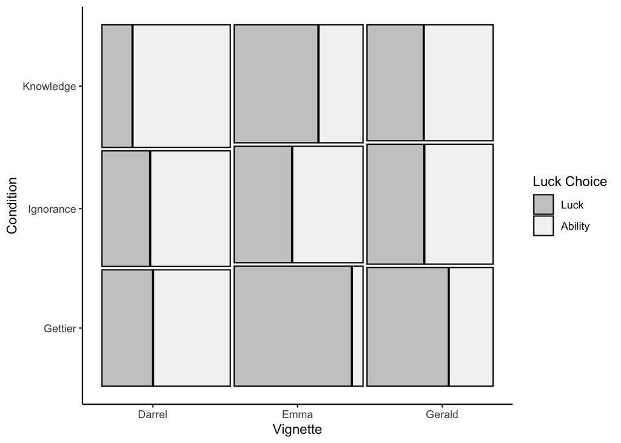

```r
l.data_graph <- l.model.6A@frame
l.data_graph$luck_vas_combined <- factor(l.data_graph$luck_vas_combined,
                                          levels = c(0,1),
                                          labels = c("Luck", "Ability"))

#graph the three way binary
ggplot(l.data_graph) +
  geom_mosaic(aes(x = product(luck_vas_combined, cond, vignette),
                  fill = luck_vas_combined), color = "black", size = .5) +
  scale_fill_brewer(palette = "Greys", name = "Luck Choice",
                    direction = -1) +
  scale_x_productlist(breaks = c(0.13,.5,.87),
    labels = c("Darrel", "Emma", "Gerald")) +
  theme_classic() +
  xlab("Vignette") +
  ylab("Condition")
```

- Model 6 AIC: 15578.9153684
- Model 6A AIC: 15147.9851281
- Interpretation: This model is better than a model without the interaction.
- There is an interaction between vignette and condition for choice.
- In looking at the graph, we can see that each vignette produces a different pattern of results.
- This interaction adds a good portion of variance to the fixed effects 14-17%.

To analyze this interaction, we will use chi-square analysis and proportion tests (making sure it’s on the same data as the analysis above).

```r
# overall darrel
chisq.test(l.data_graph$luck_vas_combined[l.data_graph$vignette == "Darrel"],
           l.data_graph$cond[l.data_graph$vignette == "Darrel"])
```

```
##
##  Pearson's Chi-squared test
##
## data:  l.data_graph$luck_vas_combined[l.data_graph$vignette == "Darrel"] and l.data_graph$cond[l.data_graph$vignette == "Darrel"]
## X-squared = 95.628, df = 2, p-value < 0.00000000000000022
```

```r
l.d_table <- table(l.data_graph$luck_vas_combined[l.data_graph$vignette == "Darrel"],
           l.data_graph$cond[l.data_graph$vignette == "Darrel"])
l.d_table
```

```
##
##           Gettier Ignorance Knowledge
##   Luck        540       507       339
##   Ability     820       845      1094
```

```r
# prop tests
prop1 <- prop.test(t(l.d_table[1:2, 1:2]))
prop1
```

```
##
##  2-sample test for equality of proportions with continuity correction
##
## data:  t(l.d_table[1:2, 1:2])
## X-squared = 1.3004, df = 1, p-value = 0.2541
## alternative hypothesis: two.sided
## 95 percent confidence interval:
##  -0.01531404  0.05943168
## sample estimates:
##    prop 1    prop 2
## 0.3970588 0.3750000
```

```r
v.chi.sq(x2 = prop1$statistic,
         n = sum(t(l.d_table[1:2, 1:2])),
         r = 2, c = 2)
```

```
## $v
##  X-squared
## 0.02189738
##
## $vlow
## [1] 0.01920238
##
## $vhigh
## [1] 0.06255011
##
## $n
## [1] 2712
##
## $df
## [1] 1
##
## $x2
## X-squared
##  1.300391
##
## $p
## X-squared
## 0.2541418
##
## $estimate
## [1] "$V$ = .02, 95\\% CI [.02, .06]"
##
## $statistic
## [1] "$\\chi^2$(1) = 1.30, $p$ = .254"
```

```r
prop2 <- prop.test(t(l.d_table[1:2, c(1,3)]))
prop2
```

```
##
##  2-sample test for equality of proportions with continuity correction
##
## data:  t(l.d_table[1:2, c(1, 3)])
## X-squared = 82.594, df = 1, p-value < 0.00000000000000022
## alternative hypothesis: two.sided
## 95 percent confidence interval:
##  0.1257115 0.1952728
## sample estimates:
##    prop 1    prop 2
## 0.3970588 0.2365666
```

```r
v.chi.sq(x2 = prop2$statistic,
         n = sum(t(l.d_table[1:2, c(1,3)])),
         r = 2, c = 2)
```

```
## $v
## X-squared
##  0.171964
##
## $vlow
## [1] 0.1361986
##
## $vhigh
## [1] 0.2099049
##
## $n
## [1] 2793
##
## $df
## [1] 1
##
## $x2
## X-squared
##  82.59357
##
## $p
##                   X-squared
## 0.0000000000000000001007846
##
## $estimate
## [1] "$V$ = .17, 95\\% CI [.14, .21]"
##
## $statistic
## [1] "$\\chi^2$(1) = 82.59, $p$ < .001"
```

- The proportions are the likelihood of Luck for each condition
- No differences in Gettier and Ignorance
- More likely to pick luck in Gettier than Knowledge

```r
# overall emma
chisq.test(l.data_graph$luck_vas_combined[l.data_graph$vignette == "Emma"],
           l.data_graph$cond[l.data_graph$vignette == "Emma"])
```

```
##
##  Pearson's Chi-squared test
##
## data:  l.data_graph$luck_vas_combined[l.data_graph$vignette == "Emma"] and l.data_graph$cond[l.data_graph$vignette == "Emma"]
## X-squared = 694.82, df = 2, p-value < 0.00000000000000022
```

```r
l.e_table <- table(l.data_graph$luck_vas_combined[l.data_graph$vignette == "Emma"],
           l.data_graph$cond[l.data_graph$vignette == "Emma"])
l.e_table
```

```
##
##           Gettier Ignorance Knowledge
##   Luck       1292       615       908
##   Ability     118       753       478
```

```r
# prop tests
prop1 <- prop.test(t(l.e_table[1:2, 1:2]))
prop1
```

```
##
##  2-sample test for equality of proportions with continuity correction
##
## data:  t(l.e_table[1:2, 1:2])
## X-squared = 700.64, df = 1, p-value < 0.00000000000000022
## alternative hypothesis: two.sided
## 95 percent confidence interval:
##  0.4359673 0.4975340
## sample estimates:
##    prop 1    prop 2
## 0.9163121 0.4495614
```

```r
v.chi.sq(x2 = prop1$statistic,
         n = sum(t(l.e_table[1:2, 1:2])),
         r = 2, c = 2)
```

```
## $v
## X-squared
## 0.5022068
##
## $vlow
## [1] 0.4654074
##
## $vhigh
## [1] 0.5397266
##
## $n
## [1] 2778
##
## $df
## [1] 1
##
## $x2
## X-squared
##  700.6439
##
## $p
##     X-squared
## 2.166083e-154
##
## $estimate
## [1] "$V$ = .50, 95\\% CI [.47, .54]"
##
## $statistic
## [1] "$\\chi^2$(1) = 700.64, $p$ < .001"
```

```r
prop2 <- prop.test(t(l.e_table[1:2, c(1,3)]))
prop2
```

```
##
##  2-sample test for equality of proportions with continuity correction
##
## data:  t(l.e_table[1:2, c(1, 3)])
## X-squared = 282.73, df = 1, p-value < 0.00000000000000022
## alternative hypothesis: two.sided
## 95 percent confidence interval:
##  0.2315754 0.2908034
## sample estimates:
##    prop 1    prop 2
## 0.9163121 0.6551227
```

```r
v.chi.sq(x2 = prop2$statistic,
         n = sum(t(l.e_table[1:2, c(1,3)])),
         r = 2, c = 2)
```

```
## $v
## X-squared
## 0.3179956
##
## $vlow
## [1] 0.2815651
##
## $vhigh
## [1] 0.3555652
##
## $n
## [1] 2796
##
## $df
## [1] 1
##
## $x2
## X-squared
##  282.7349
##
## $p
##    X-squared
## 1.903784e-63
##
## $estimate
## [1] "$V$ = .32, 95\\% CI [.28, .36]"
##
## $statistic
## [1] "$\\chi^2$(1) = 282.73, $p$ < .001"
```

- More likely to pick luck in Gettier than Ignorance
- More likely to pick luck in Gettier than Knowledge

```r
# overall gerald
chisq.test(l.data_graph$luck_vas_combined[l.data_graph$vignette == "Gerald"],
           l.data_graph$cond[l.data_graph$vignette == "Gerald"])
```

```
##
##  Pearson's Chi-squared test
##
## data:  l.data_graph$luck_vas_combined[l.data_graph$vignette == "Gerald"] and l.data_graph$cond[l.data_graph$vignette == "Gerald"]
## X-squared = 141.57, df = 2, p-value < 0.00000000000000022
```

```r
l.g_table <- table(l.data_graph$luck_vas_combined[l.data_graph$vignette == "Gerald"],
           l.data_graph$cond[l.data_graph$vignette == "Gerald"])
l.g_table
```

```
##
##           Gettier Ignorance Knowledge
##   Luck        886       626       600
##   Ability     478       752       733
```

```r
# prop tests
prop1 <- prop.test(t(l.g_table[1:2, 1:2]))
prop1
```

```
##
##  2-sample test for equality of proportions with continuity correction
##
## data:  t(l.g_table[1:2, 1:2])
## X-squared = 104.89, df = 1, p-value < 0.00000000000000022
## alternative hypothesis: two.sided
## 95 percent confidence interval:
##  0.1580500 0.2325071
## sample estimates:
##    prop 1    prop 2
## 0.6495601 0.4542816
```

```r
v.chi.sq(x2 = prop1$statistic,
         n = sum(t(l.g_table[1:2, 1:2])),
         r = 2, c = 2)
```

```
## $v
## X-squared
## 0.1955837
##
## $vlow
## [1] 0.159303
##
## $vhigh
## [1] 0.2337945
##
## $n
## [1] 2742
##
## $df
## [1] 1
##
## $x2
## X-squared
##  104.8897
##
## $p
##    X-squared
## 1.291289e-24
##
## $estimate
## [1] "$V$ = .20, 95\\% CI [.16, .23]"
##
## $statistic
## [1] "$\\chi^2$(1) = 104.89, $p$ < .001"
```

```r
prop2 <- prop.test(t(l.g_table[1:2, c(1,3)]))
prop2
```

```
##
##  2-sample test for equality of proportions with continuity correction
##
## data:  t(l.g_table[1:2, c(1, 3)])
## X-squared = 107.59, df = 1, p-value < 0.00000000000000022
## alternative hypothesis: two.sided
## 95 percent confidence interval:
##  0.1619042 0.2369910
## sample estimates:
##    prop 1    prop 2
## 0.6495601 0.4501125
```

```r
v.chi.sq(x2 = prop2$statistic,
         n = sum(t(l.g_table[1:2, c(1,3)])),
         r = 2, c = 2)
```

```
## $v
## X-squared
## 0.1997338
##
## $vlow
## [1] 0.1631337
##
## $vhigh
## [1] 0.2382537
##
## $n
## [1] 2697
##
## $df
## [1] 1
##
## $x2
## X-squared
##   107.593
##
## $p
##    X-squared
## 3.300432e-25
##
## $estimate
## [1] "$V$ = .20, 95\\% CI [.16, .24]"
##
## $statistic
## [1] "$\\chi^2$(1) = 107.59, $p$ < .001"
```

- More likely to pick luck in Gettier than Ignorance
- More likely to pick luck in Gettier than Knowledge

### Model 6B

Data was collected from mechanical turk participants. Are there differences in this data and the complete data on the condition variable?

```r
l.model.6B <- glmer(luck_vas_combined ~ (1|vignette/id/person_code) +
                    comp + age + gender2 + education +
                    cond*turk,
                      data = final_luck,
                      family = binomial,
                      control = glmerControl(optimizer = "bobyqa"),
                      nAGQ = 0)
summary(l.model.6B)
```

```
## Generalized linear mixed model fit by maximum likelihood (Adaptive
##   Gauss-Hermite Quadrature, nAGQ = 0) [glmerMod]
##  Family: binomial  ( logit )
## Formula: luck_vas_combined ~ (1 | vignette/id/person_code) + comp + age +
##     gender2 + education + cond * turk
##    Data: final_luck
## Control: glmerControl(optimizer = "bobyqa")
##
##      AIC      BIC   logLik deviance df.resid
##  15554.9  15651.4  -7764.4  15528.9    12371
##
## Scaled residuals:
##     Min      1Q  Median      3Q     Max
## -2.3106 -0.8135 -0.4526  0.9028  2.4778
##
## Random effects:
##  Groups                    Name        Variance Std.Dev.
##  person_code:(id:vignette) (Intercept) 0.00825  0.09083
##  id:vignette               (Intercept) 0.00501  0.07078
##  vignette                  (Intercept) 0.37169  0.60966
## Number of obs: 12384, groups:
## person_code:(id:vignette), 12384; id:vignette, 12384; vignette, 3
##
## Fixed effects:
##                         Estimate Std. Error z value             Pr(>|z|)
## (Intercept)            -0.408572   0.373092  -1.095              0.27347
## compYes                -0.110623   0.046365  -2.386              0.01704 *
## age                     0.009622   0.002287   4.208            0.0000258 ***
## gender2male             0.038634   0.042910   0.900              0.36793
## education              -0.031333   0.007529  -4.162            0.0000316 ***
## condIgnorance           1.050824   0.049696  21.145 < 0.0000000000000002 ***
## condKnowledge           0.925993   0.049429  18.734 < 0.0000000000000002 ***
## turkTRUE               -0.386699   0.141956  -2.724              0.00645 **
## condIgnorance:turkTRUE -0.284219   0.187886  -1.513              0.13035
## condKnowledge:turkTRUE  0.186018   0.183290   1.015              0.31016
## ---
## Signif. codes:  0 '***' 0.001 '**' 0.01 '*' 0.05 '.' 0.1 ' ' 1
##
## Correlation of Fixed Effects:
##             (Intr) compYs age    gndr2m eductn cndIgn cndKnw trTRUE cI:TRU
## compYes     -0.100
## age         -0.143  0.311
## gender2male -0.038  0.046 -0.015
## education   -0.253 -0.119 -0.104  0.017
## condIgnornc -0.068 -0.005  0.020  0.003 -0.013
## condKnowldg -0.066 -0.008  0.014  0.002 -0.016  0.523
## turkTRUE     0.037 -0.177 -0.281 -0.081 -0.008  0.173  0.177
## cndIgn:TRUE  0.017  0.003  0.001  0.005  0.003 -0.261 -0.136 -0.684
## cndKnw:TRUE  0.017  0.006  0.008 -0.001  0.001 -0.138 -0.267 -0.702  0.529
```

```r
r.squaredGLMM(l.model.6B)
```

```
##                    R2m       R2c
## theoretical 0.06267447 0.1608627
## delta       0.05304610 0.1361502
```

- Model 6 AIC: 15578.9153684
- Model 6A AIC: 15554.8806839
- Interpretation: This model is better than a model without the interaction.
- However, the interaction with the turk variable does not produce significant effects.
- The model is likely “better” because of the added variable and main effect of turk (likely drive by sample size differences in the two samples of turk versus not for knows versus believes).
- Therefore, we do not find evidence for differences in the turk sample for condition effects.

### Model 6C

Data was binned because of the distributions of the visual analogue scale - does the data source make a difference?

```r
l.model.6C <- glmer(luck_vas_combined ~ (1|vignette/id/person_code) +
                    comp + age + gender2 + education +
                    cond*luck_vas_combined_source,
                      data = final_luck,
                      family = binomial,
                      control = glmerControl(optimizer = "bobyqa"),
                      nAGQ = 0)
summary(l.model.6C)
```

```
## Generalized linear mixed model fit by maximum likelihood (Adaptive
##   Gauss-Hermite Quadrature, nAGQ = 0) [glmerMod]
##  Family: binomial  ( logit )
## Formula: luck_vas_combined ~ (1 | vignette/id/person_code) + comp + age +
##     gender2 + education + cond * luck_vas_combined_source
##    Data: final_luck
## Control: glmerControl(optimizer = "bobyqa")
##
##      AIC      BIC   logLik deviance df.resid
##  15543.9  15640.5  -7759.0  15517.9    12371
##
## Scaled residuals:
##     Min      1Q  Median      3Q     Max
## -2.5835 -0.7931 -0.4515  0.9168  2.2723
##
## Random effects:
##  Groups                    Name        Variance Std.Dev.
##  person_code:(id:vignette) (Intercept) 0.009604 0.09800
##  id:vignette               (Intercept) 0.005312 0.07288
##  vignette                  (Intercept) 0.374705 0.61213
## Number of obs: 12384, groups:
## person_code:(id:vignette), 12384; id:vignette, 12384; vignette, 3
##
## Fixed effects:
##                                            Estimate Std. Error z value
## (Intercept)                               -0.159505   0.381033  -0.419
## compYes                                   -0.175437   0.044480  -3.944
## age                                        0.004732   0.002027   2.334
## gender2male                                0.010826   0.042552   0.254
## education                                 -0.030461   0.007531  -4.045
## condIgnorance                              1.428325   0.126234  11.315
## condKnowledge                              0.821126   0.122575   6.699
## luck_vas_combined_sourceVAS               -0.133408   0.095244  -1.401
## condIgnorance:luck_vas_combined_sourceVAS -0.462146   0.136190  -3.393
## condKnowledge:luck_vas_combined_sourceVAS  0.138674   0.132858   1.044
##                                                       Pr(>|z|)
## (Intercept)                                            0.67550
## compYes                                         0.000080075454 ***
## age                                                    0.01958 *
## gender2male                                            0.79916
## education                                       0.000052427772 ***
## condIgnorance                             < 0.0000000000000002 ***
## condKnowledge                                   0.000000000021 ***
## luck_vas_combined_sourceVAS                            0.16130
## condIgnorance:luck_vas_combined_sourceVAS              0.00069 ***
## condKnowledge:luck_vas_combined_sourceVAS              0.29659
## ---
## Signif. codes:  0 '***' 0.001 '**' 0.01 '*' 0.05 '.' 0.1 ' ' 1
##
## Correlation of Fixed Effects:
##             (Intr) compYs age    gndr2m eductn cndIgn cndKnw l___VA cI:___
## compYes     -0.077
## age         -0.112  0.213
## gender2male -0.027  0.008 -0.086
## education   -0.243 -0.127 -0.120  0.016
## condIgnornc -0.159 -0.006  0.002  0.000 -0.005
## condKnowldg -0.163 -0.008  0.002 -0.002 -0.005  0.498
## lck_vs__VAS -0.204  0.000 -0.014  0.003 -0.021  0.638  0.658
## cndI:___VAS  0.147  0.004  0.006  0.001  0.000 -0.925 -0.461 -0.699
## cndK:___VAS  0.151  0.004  0.003  0.002 -0.001 -0.458 -0.921 -0.716  0.501
```

```r
table(l.model.6C@frame$luck_vas_combined, l.model.6C@frame$cond, l.model.6C@frame$luck_vas_combined_source)
```

```
## , ,  = Binary
##
##
##     Gettier Ignorance Knowledge
##   0     387       193       271
##   1     225       419       338
##
## , ,  = VAS
##
##
##     Gettier Ignorance Knowledge
##   0    2331      1555      1576
##   1    1191      1931      1967
```

```r
r.squaredGLMM(l.model.6C)
```

```
##                    R2m       R2c
## theoretical 0.06385366 0.1629822
## delta       0.05406512 0.1379976
```

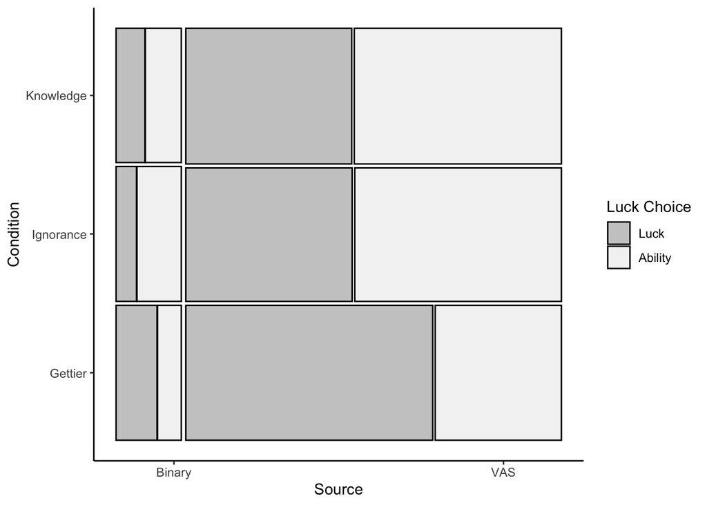

```r
l.data_graph <- l.model.6C@frame
l.data_graph$luck_vas_combined <- factor(l.data_graph$luck_vas_combined,
                                          levels = c(0,1),
                                          labels = c("Luck", "Ability"))

#graph the three way binary
ggplot(l.data_graph) +
  geom_mosaic(aes(x = product(luck_vas_combined, cond, luck_vas_combined_source),
                  fill = luck_vas_combined), color = "black", size = .5) +
  scale_fill_brewer(palette = "Greys", name = "Luck Choice",
                    direction = -1) +
  scale_x_productlist(breaks = c(0.13,.87),
    labels = c("Binary", "VAS")) +
  theme_classic() +
  xlab("Source") +
  ylab("Condition")
```

- Model 6 AIC: 15578.9153684
- Model 6C AIC: 15543.9491834
- Interpretation: This model is better than a model without the condition interaction.
- We do see evidence for some interaction with the source of the data.

```r
# overall binary
# chisq.test(l.data_graph$luck_vas_combined[l.data_graph$luck_vas_combined_source == "Binary"],
#            l.data_graph$cond[l.data_graph$luck_vas_combined_source == "Binary"])

#HM getting error --
#Error in names(attr(result$observed, "dimnames")) <- c(dname_x, dname_y) :
#  'names' attribute [3] must be the same length as the vector [2]


b_table <- table(l.data_graph$luck_vas_combined[l.data_graph$luck_vas_combined_source == "Binary"],
           l.data_graph$cond[l.data_graph$luck_vas_combined_source == "Binary"])

b_table
```

```
##
##           Gettier Ignorance Knowledge
##   Luck        387       193       271
##   Ability     225       419       338
```

```r
# prop tests
prop1 <- prop.test(t(b_table[1:2, 1:2]))
prop1
```

```
##
##  2-sample test for equality of proportions with continuity correction
##
## data:  t(b_table[1:2, 1:2])
## X-squared = 122.06, df = 1, p-value < 0.00000000000000022
## alternative hypothesis: two.sided
## 95 percent confidence interval:
##  0.2623076 0.3716793
## sample estimates:
##    prop 1    prop 2
## 0.6323529 0.3153595
```

```r
v.chi.sq(x2 = prop1$statistic,
         n = sum(t(b_table[1:2, 1:2])),
         r = 2, c = 2)
```

```
## $v
## X-squared
## 0.3157915
##
## $vlow
## [1] 0.2613374
##
## $vhigh
## [1] 0.3729103
##
## $n
## [1] 1224
##
## $df
## [1] 1
##
## $x2
## X-squared
##  122.0625
##
## $p
##    X-squared
## 2.236821e-28
##
## $estimate
## [1] "$V$ = .32, 95\\% CI [.26, .37]"
##
## $statistic
## [1] "$\\chi^2$(1) = 122.06, $p$ < .001"
```

```r
prop2 <- prop.test(t(b_table[1:2, c(1,3)]))
prop2
```

```
##
##  2-sample test for equality of proportions with continuity correction
##
## data:  t(b_table[1:2, c(1, 3)])
## X-squared = 42.372, df = 1, p-value = 0.00000000007545
## alternative hypothesis: two.sided
## 95 percent confidence interval:
##  0.1307947 0.2439276
## sample estimates:
##    prop 1    prop 2
## 0.6323529 0.4449918
```

```r
v.chi.sq(x2 = prop2$statistic,
         n = sum(t(b_table[1:2, c(1,3)])),
         r = 2, c = 2)
```

```
## $v
## X-squared
## 0.1862873
##
## $vlow
## [1] 0.1333048
##
## $vhigh
## [1] 0.2440616
##
## $n
## [1] 1221
##
## $df
## [1] 1
##
## $x2
## X-squared
##  42.37231
##
## $p
##           X-squared
## 0.00000000007545079
##
## $estimate
## [1] "$V$ = .19, 95\\% CI [.13, .24]"
##
## $statistic
## [1] "$\\chi^2$(1) = 42.37, $p$ < .001"
```

- Gettier more likely to say Luck than Ignorance
- Gettier more likely to say Luck than Knowledge

```r
# # overall VAS
# chisq.test(l.data_graph$luck_vas_combined[l.data_graph$luck_vas_combined_source == "VAS"],
#            l.data_graph$cond[l.data_graph$luck_vas_combined_source == "VAS"])

v_table <- table(l.data_graph$luck_vas_combined[l.data_graph$luck_vas_combined_source == "VAS"],
           l.data_graph$cond[l.data_graph$luck_vas_combined_source == "VAS"])

v_table
```

```
##
##           Gettier Ignorance Knowledge
##   Luck       2331      1555      1576
##   Ability    1191      1931      1967
```

```r
# prop tests
prop1 <- prop.test(t(v_table[1:2, 1:2]))
prop1
```

```
##
##  2-sample test for equality of proportions with continuity correction
##
## data:  t(v_table[1:2, 1:2])
## X-squared = 329.31, df = 1, p-value < 0.00000000000000022
## alternative hypothesis: two.sided
## 95 percent confidence interval:
##  0.1927601 0.2387796
## sample estimates:
##    prop 1    prop 2
## 0.6618399 0.4460700
```

```r
v.chi.sq(x2 = prop1$statistic,
         n = sum(t(v_table[1:2, 1:2])),
         r = 2, c = 2)
```

```
## $v
## X-squared
## 0.2167737
##
## $vlow
## [1] 0.1937296
##
## $vhigh
## [1] 0.2404832
##
## $n
## [1] 7008
##
## $df
## [1] 1
##
## $x2
## X-squared
##  329.3117
##
## $p
##    X-squared
## 1.357409e-73
##
## $estimate
## [1] "$V$ = .22, 95\\% CI [.19, .24]"
##
## $statistic
## [1] "$\\chi^2$(1) = 329.31, $p$ < .001"
```

```r
prop2 <- prop.test(t(v_table[1:2, c(1,3)]))
prop2
```

```
##
##  2-sample test for equality of proportions with continuity correction
##
## data:  t(v_table[1:2, c(1, 3)])
## X-squared = 335.64, df = 1, p-value < 0.00000000000000022
## alternative hypothesis: two.sided
## 95 percent confidence interval:
##  0.1941115 0.2399266
## sample estimates:
##    prop 1    prop 2
## 0.6618399 0.4448208
```

```r
v.chi.sq(x2 = prop2$statistic,
         n = sum(t(v_table[1:2, c(1,3)])),
         r = 2, c = 2)
```

```
## $v
## X-squared
## 0.2179634
##
## $vlow
## [1] 0.1950086
##
## $vhigh
## [1] 0.2415746
##
## $n
## [1] 7065
##
## $df
## [1] 1
##
## $x2
## X-squared
##  335.6443
##
## $p
##    X-squared
## 5.668743e-75
##
## $estimate
## [1] "$V$ = .22, 95\\% CI [.20, .24]"
##
## $statistic
## [1] "$\\chi^2$(1) = 335.64, $p$ < .001"
```

## Exploratory Analyses

### Condition by Luck

```r
## add to this data
final_luck$know_vas_binned <- final_luck$know_vas
final_luck$know_vas_binned[final_luck$know_vas_binned <= 40] <- 2
final_luck$know_vas_binned[final_luck$know_vas_binned > 40 &
                             final_luck$know_vas_binned < 60] <- NA
final_luck$know_vas_binned[final_luck$know_vas_binned >= 60] <- 1
table(final_luck$know_vas_binned, useNA = "ifany")
```

```
##
##    1    2 <NA>
## 4364 6705 2182
```

```r
final_luck$know_vas_combined <- ifelse(is.na(final_luck$know_vas_binned),
                                     final_luck$know_bin,
                                     final_luck$know_vas_binned)

final_luck$know_vas_combined <- final_luck$know_vas_combined - 1

k.model.6E <- glmer(know_vas_combined ~ (1|vignette/id/person_code) +
                    comp + age + gender2 + education +
                    cond*luck_vas_combined,
                      data = final_luck,
                      family = binomial,
                      control = glmerControl(optimizer = "bobyqa"),
                      nAGQ = 0)
summary(k.model.6E)
```

```
## Generalized linear mixed model fit by maximum likelihood (Adaptive
##   Gauss-Hermite Quadrature, nAGQ = 0) [glmerMod]
##  Family: binomial  ( logit )
## Formula: know_vas_combined ~ (1 | vignette/id/person_code) + comp + age +
##     gender2 + education + cond * luck_vas_combined
##    Data: final_luck
## Control: glmerControl(optimizer = "bobyqa")
##
##      AIC      BIC   logLik deviance df.resid
##  13095.3  13191.5  -6534.6  13069.3    12124
##
## Scaled residuals:
##     Min      1Q  Median      3Q     Max
## -3.8793 -0.6429  0.4481  0.5600  2.3132
##
## Random effects:
##  Groups                    Name        Variance            Std.Dev.
##  person_code:(id:vignette) (Intercept) 0.00000000000002416 0.0000001554
##  id:vignette               (Intercept) 0.00000000000095087 0.0000009751
##  vignette                  (Intercept) 0.32493022381376635 0.5700265115
## Number of obs: 12137, groups:
## person_code:(id:vignette), 12137; id:vignette, 12137; vignette, 3
##
## Fixed effects:
##                                  Estimate Std. Error z value
## (Intercept)                      0.505443   0.355687   1.421
## compYes                         -0.035146   0.049598  -0.709
## age                             -0.003534   0.002244  -1.575
## gender2male                      0.142787   0.047567   3.002
## education                        0.016901   0.008351   2.024
## condIgnorance                    0.992440   0.079041  12.556
## condKnowledge                   -0.351534   0.066714  -5.269
## luck_vas_combined               -1.040857   0.074292 -14.010
## condIgnorance:luck_vas_combined  1.135834   0.113798   9.981
## condKnowledge:luck_vas_combined -0.190978   0.101318  -1.885
##                                             Pr(>|z|)
## (Intercept)                                  0.15531
## compYes                                      0.47857
## age                                          0.11527
## gender2male                                  0.00268 **
## education                                    0.04299 *
## condIgnorance                   < 0.0000000000000002 ***
## condKnowledge                            0.000000137 ***
## luck_vas_combined               < 0.0000000000000002 ***
## condIgnorance:luck_vas_combined < 0.0000000000000002 ***
## condKnowledge:luck_vas_combined              0.05944 .
## ---
## Signif. codes:  0 '***' 0.001 '**' 0.01 '*' 0.05 '.' 0.1 ' ' 1
##
## Correlation of Fixed Effects:
##             (Intr) compYs age    gndr2m eductn cndIgn cndKnw lck_v_ cnI:__
## compYes     -0.095
## age         -0.135  0.222
## gender2male -0.034  0.013 -0.082
## education   -0.296 -0.130 -0.122  0.022
## condIgnornc -0.068 -0.011  0.007  0.004 -0.002
## condKnowldg -0.080 -0.009  0.000  0.010  0.002  0.355
## lck_vs_cmbn -0.080  0.008 -0.011 -0.003  0.023  0.347  0.374
## cndIgnrn:__  0.044  0.018 -0.001  0.012  0.006 -0.699 -0.245 -0.646
## cndKnwld:__  0.056  0.013  0.010 -0.019 -0.015 -0.245 -0.655 -0.712  0.463
```

```r
r.squaredGLMM(k.model.6E)
```

```
##                   R2m       R2c
## theoretical 0.2115271 0.2824021
## delta       0.1765277 0.2356756
```

```r
l2.data_graph <- k.model.6E@frame
l2.data_graph$know_vas_combined <- factor(l2.data_graph$know_vas_combined,
                                       levels = 0:1,
                                       labels = c("Know", "Believes"))
l2.data_graph$luck_vas_combined <- factor(l2.data_graph$luck_vas_combined,
                                       levels = 0:1,
                                       labels = c("Luck", "Ability"))

table(l2.data_graph$know_vas_combined, l2.data_graph$cond, l2.data_graph$luck_vas_combined)
```

```
## , ,  = Luck
##
##
##            Gettier Ignorance Knowledge
##   Know         825       292       690
##   Believes    1813      1432      1108
##
## , ,  = Ability
##
##
##            Gettier Ignorance Knowledge
##   Know         920       380      1672
##   Believes     464      1943       598
```

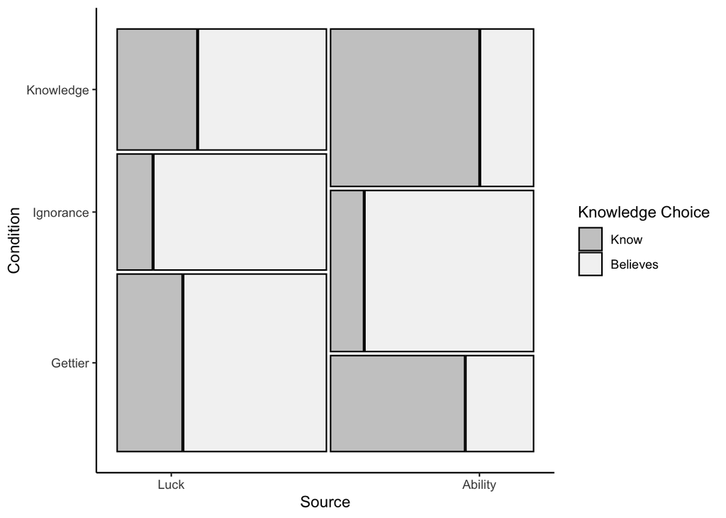

```r
#graph the three way binary
ggplot(l2.data_graph) +
  geom_mosaic(aes(x = product(know_vas_combined, cond, luck_vas_combined),
                  fill = know_vas_combined), color = "black", size = .5) +
  scale_fill_brewer(palette = "Greys", name = "Knowledge Choice",
                    direction = -1) +
  scale_x_productlist(breaks = c(0.13,.87),
    labels = c("Luck", "Ability")) +
  theme_classic() +
  xlab("Source") +
  ylab("Condition")
```

- Model 6 AIC: 15539.5674502
- Model 6E AIC: 13095.2568672
- Interpretation: This model is better than the original model without the interaction.
- There is an interaction between condition, luck choice to predict knowledge.

```r
# break down by luck and ability

# luck
l_table <- table(l2.data_graph$know_vas_combined[l2.data_graph$luck_vas_combined == "Luck"], l2.data_graph$cond[l2.data_graph$luck_vas_combined == "Luck"])

# chisq.test(l2.data_graph$know_vas_combined[l2.data_graph$luck_vas_combined == "Luck"], l2.data_graph$cond[l2.data_graph$luck_vas_combined == "Luck"])

# prop tests
prop1 <- prop.test(t(l_table[1:2, 1:2]))
prop1
```

```
##
##  2-sample test for equality of proportions with continuity correction
##
## data:  t(l_table[1:2, 1:2])
## X-squared = 111.74, df = 1, p-value < 0.00000000000000022
## alternative hypothesis: two.sided
## 95 percent confidence interval:
##  0.1178545 0.1688722
## sample estimates:
##    prop 1    prop 2
## 0.3127369 0.1693735
```

```r
v.chi.sq(x2 = prop1$statistic,
         n = sum(t(l_table[1:2, 1:2])),
         r = 2, c = 2)
```

```
## $v
## X-squared
## 0.1600498
##
## $vlow
## [1] 0.1312501
##
## $vhigh
## [1] 0.190329
##
## $n
## [1] 4362
##
## $df
## [1] 1
##
## $x2
## X-squared
##  111.7367
##
## $p
##   X-squared
## 4.08056e-26
##
## $estimate
## [1] "$V$ = .16, 95\\% CI [.13, .19]"
##
## $statistic
## [1] "$\\chi^2$(1) = 111.74, $p$ < .001"
```

```r
prop2 <- prop.test(t(l_table[1:2, c(1,3)]))
prop2
```

```
##
##  2-sample test for equality of proportions with continuity correction
##
## data:  t(l_table[1:2, c(1, 3)])
## X-squared = 23.668, df = 1, p-value = 0.000001144
## alternative hypothesis: two.sided
## 95 percent confidence interval:
##  -0.10009544 -0.04195018
## sample estimates:
##    prop 1    prop 2
## 0.3127369 0.3837597
```

```r
v.chi.sq(x2 = prop2$statistic,
         n = sum(t(l_table[1:2, c(1,3)])),
         r = 2, c = 2)
```

```
## $v
##  X-squared
## 0.07304476
##
## $vlow
## [1] 0.04612917
##
## $vhigh
## [1] 0.1035663
##
## $n
## [1] 4436
##
## $df
## [1] 1
##
## $x2
## X-squared
##  23.66844
##
## $p
##      X-squared
## 0.000001144437
##
## $estimate
## [1] "$V$ = .07, 95\\% CI [.05, .10]"
##
## $statistic
## [1] "$\\chi^2$(1) = 23.67, $p$ < .001"
```

```r
# ability
a_table <- table(l2.data_graph$know_vas_combined[l2.data_graph$luck_vas_combined == "Ability"], l2.data_graph$cond[l2.data_graph$luck_vas_combined == "Ability"])

# chisq.test(l2.data_graph$know_vas_combined[l2.data_graph$luck_vas_combined == "Ability"], l2.data_graph$cond[l2.data_graph$luck_vas_combined == "Ability"])

# prop tests
prop1 <- prop.test(t(a_table[1:2, 1:2]))
prop1
```

```
##
##  2-sample test for equality of proportions with continuity correction
##
## data:  t(a_table[1:2, 1:2])
## X-squared = 954.42, df = 1, p-value < 0.00000000000000022
## alternative hypothesis: two.sided
## 95 percent confidence interval:
##  0.4715157 0.5308009
## sample estimates:
##    prop 1    prop 2
## 0.6647399 0.1635816
```

```r
v.chi.sq(x2 = prop1$statistic,
         n = sum(t(a_table[1:2, 1:2])),
         r = 2, c = 2)
```

```
## $v
## X-squared
## 0.5074088
##
## $vlow
## [1] 0.4755014
##
## $vhigh
## [1] 0.5398499
##
## $n
## [1] 3707
##
## $df
## [1] 1
##
## $x2
## X-squared
##  954.4178
##
## $p
##     X-squared
## 1.453499e-209
##
## $estimate
## [1] "$V$ = .51, 95\\% CI [.48, .54]"
##
## $statistic
## [1] "$\\chi^2$(1) = 954.42, $p$ < .001"
```

```r
prop2 <- prop.test(t(a_table[1:2, c(1,3)]))
prop2
```

```
##
##  2-sample test for equality of proportions with continuity correction
##
## data:  t(a_table[1:2, c(1, 3)])
## X-squared = 21.166, df = 1, p-value = 0.000004211
## alternative hypothesis: two.sided
## 95 percent confidence interval:
##  -0.10317794 -0.04047004
## sample estimates:
##    prop 1    prop 2
## 0.6647399 0.7365639
```

```r
v.chi.sq(x2 = prop2$statistic,
         n = sum(t(a_table[1:2, c(1,3)])),
         r = 2, c = 2)
```

```
## $v
##  X-squared
## 0.07610972
##
## $vlow
## [1] 0.0467133
##
## $vhigh
## [1] 0.109787
##
## $n
## [1] 3654
##
## $df
## [1] 1
##
## $x2
## X-squared
##  21.16649
##
## $p
##      X-squared
## 0.000004210637
##
## $estimate
## [1] "$V$ = .08, 95\\% CI [.05, .11]"
##
## $statistic
## [1] "$\\chi^2$(1) = 21.17, $p$ < .001"
```

- When we pick luck:
  - Gettier more likely to pick knows than Ignorance
  - Knowledge more likely to pick knows than Gettier
- When we pick ability:
  - Gettier more likely to pick knows than Ignorance (by a lot)
  - Knowledge more likely to pick knows than Gettier (by a little)

### Alternative Knowledge Question

```r
final_long$know_alt <- final_long$know_alt - 1 #center over zero

# what is the comparison of the original to alternative
table("original" = final_long$know_vas_combined,
      "alternative" = final_long$know_alt)
```

```
##         alternative
## original    0    1
##        0 3681 1728
##        1 1232 7171
```

```r
k.model.6F <- glmer(know_alt ~ (1|vignette/id/person_code) +
                   comp + age + gender2 + education +
                   cond,
                      data = final_long,
                      family = binomial,
                      control = glmerControl(optimizer = "bobyqa"),
                      nAGQ = 0)
summary(k.model.6F)
```

```
## Generalized linear mixed model fit by maximum likelihood (Adaptive
##   Gauss-Hermite Quadrature, nAGQ = 0) [glmerMod]
##  Family: binomial  ( logit )
## Formula: know_alt ~ (1 | vignette/id/person_code) + comp + age + gender2 +
##     education + cond
##    Data: final_long
## Control: glmerControl(optimizer = "bobyqa")
##
##      AIC      BIC   logLik deviance df.resid
##  16008.8  16084.2  -7994.4  15988.8    13940
##
## Scaled residuals:
##     Min      1Q  Median      3Q     Max
## -3.9819 -0.8700  0.4784  0.6528  1.6111
##
## Random effects:
##  Groups                    Name        Variance Std.Dev.
##  person_code:(id:vignette) (Intercept) 0.000    0.0000
##  id:vignette               (Intercept) 0.000    0.0000
##  vignette                  (Intercept) 0.395    0.6285
## Number of obs: 13950, groups:
## person_code:(id:vignette), 13950; id:vignette, 13950; vignette, 3
##
## Fixed effects:
##                Estimate Std. Error z value             Pr(>|z|)
## (Intercept)    0.690348   0.381566   1.809              0.07041 .
## compYes       -0.239150   0.044860  -5.331         0.0000000977 ***
## age           -0.006615   0.002022  -3.272              0.00107 **
## gender2male    0.114388   0.042369   2.700              0.00694 **
## education      0.006119   0.007465   0.820              0.41241
## condIgnorance  1.174213   0.050392  23.302 < 0.0000000000000002 ***
## condKnowledge -0.396468   0.043981  -9.015 < 0.0000000000000002 ***
## ---
## Signif. codes:  0 '***' 0.001 '**' 0.01 '*' 0.05 '.' 0.1 ' ' 1
##
## Correlation of Fixed Effects:
##             (Intr) compYs age    gndr2m eductn cndIgn
## compYes     -0.080
## age         -0.112  0.220
## gender2male -0.028  0.005 -0.091
## education   -0.244 -0.130 -0.129  0.024
## condIgnornc -0.048 -0.016 -0.011  0.013  0.000
## condKnowldg -0.059  0.009  0.003 -0.004 -0.002  0.439
```

```r
table(k.model.6F@frame$cond, k.model.6F@frame$know_alt)
```

```
##
##                0    1
##   Gettier   1841 2809
##   Ignorance  830 3820
##   Knowledge 2256 2394
```

```r
# for comparison approximately
table(final_long$cond, final_long$know_vas_combined)
```

```
##
##                0    1
##   Gettier   1957 2619
##   Ignorance  840 3807
##   Knowledge 2612 1977
```

```r
r.squaredGLMM(k.model.6F)
```

```
##                    R2m       R2c
## theoretical 0.11089158 0.2062088
## delta       0.08775878 0.1631921
```

### Order Effects

```r
k.model.6G <- glmer(know_vas_combined ~ (1|vignette/id/person_code) +
                   comp + age + gender2 + education +
                   cond + vignette_order + cond_order,
                      data = final_long,
                      family = binomial,
                      control = glmerControl(optimizer = "bobyqa"),
                      nAGQ = 0)
summary(k.model.6G)
```

```
## Generalized linear mixed model fit by maximum likelihood (Adaptive
##   Gauss-Hermite Quadrature, nAGQ = 0) [glmerMod]
##  Family: binomial  ( logit )
## Formula: know_vas_combined ~ (1 | vignette/id/person_code) + comp + age +
##     gender2 + education + cond + vignette_order + cond_order
##    Data: final_long
## Control: glmerControl(optimizer = "bobyqa")
##
##      AIC      BIC   logLik deviance df.resid
##  15503.9  15654.2  -7731.9  15463.9    13582
##
## Scaled residuals:
##     Min      1Q  Median      3Q     Max
## -4.5619 -0.7910  0.4634  0.6521  1.9344
##
## Random effects:
##  Groups                    Name        Variance       Std.Dev.
##  person_code:(id:vignette) (Intercept) 0.000000000004 0.000002
##  id:vignette               (Intercept) 0.000000000000 0.000000
##  vignette                  (Intercept) 0.453111470907 0.673136
## Number of obs: 13602, groups:
## person_code:(id:vignette), 13602; id:vignette, 13602; vignette, 3
##
## Fixed effects:
##                    Estimate Std. Error z value             Pr(>|z|)
## (Intercept)        0.228217   0.411293   0.555              0.57898
## compYes           -0.032477   0.045210  -0.718              0.47254
## age               -0.004840   0.002062  -2.347              0.01892 *
## gender2male        0.093341   0.043037   2.169              0.03009 *
## education          0.015710   0.007583   2.072              0.03829 *
## condIgnorance      1.316421   0.050866  25.880 < 0.0000000000000002 ***
## condKnowledge     -0.619432   0.045048 -13.751 < 0.0000000000000002 ***
## vignette_orderEGD  0.065499   0.068259   0.960              0.33728
## vignette_orderDGE -0.034767   0.067385  -0.516              0.60589
## vignette_orderGED  0.161091   0.068718   2.344              0.01907 *
## vignette_orderDEG  0.063310   0.067909   0.932              0.35120
## vignette_orderGDE  0.191752   0.067961   2.822              0.00478 **
## cond_orderGKI      0.140561   0.068062   2.065              0.03890 *
## cond_orderIGK     -0.210136   0.067788  -3.100              0.00194 **
## cond_orderGIK     -0.029343   0.067849  -0.432              0.66539
## cond_orderKIG     -0.139311   0.068024  -2.048              0.04056 *
## cond_orderIKG     -0.179940   0.068192  -2.639              0.00832 **
## ---
## Signif. codes:  0 '***' 0.001 '**' 0.01 '*' 0.05 '.' 0.1 ' ' 1
```

```
##
## Correlation matrix not shown by default, as p = 17 > 12.
## Use print(x, correlation=TRUE)  or
##     vcov(x)        if you need it
```

```r
r.squaredGLMM(k.model.6G)
```

```
##                   R2m       R2c
## theoretical 0.1537924 0.2562312
## delta       0.1274241 0.2122993
```

- Model 6 AIC: 15539.5674502
- Model 6G AIC: 15503.8704799
- Interpretation: this model is “better” than the original, in that the AIC is lower, indicating lower error in predicting the outcome. This result isn’t too surprising because we’ve added two new predictors.
- There do appear to be order effects for both predictors.

```r
data_graph <- k.model.6G@frame

data_graph$know_vas_combined <- factor(data_graph$know_vas_combined,
                                       levels = c(0,1),
                                       labels = c("Knows", "Believes"))

table(data_graph$know_vas_combined, data_graph$vignette_order)
```

```
##
##             EDG  EGD  DGE  GED  DEG  GDE
##   Knows     891  886  958  832  902  848
##   Believes 1321 1373 1355 1396 1390 1450
```

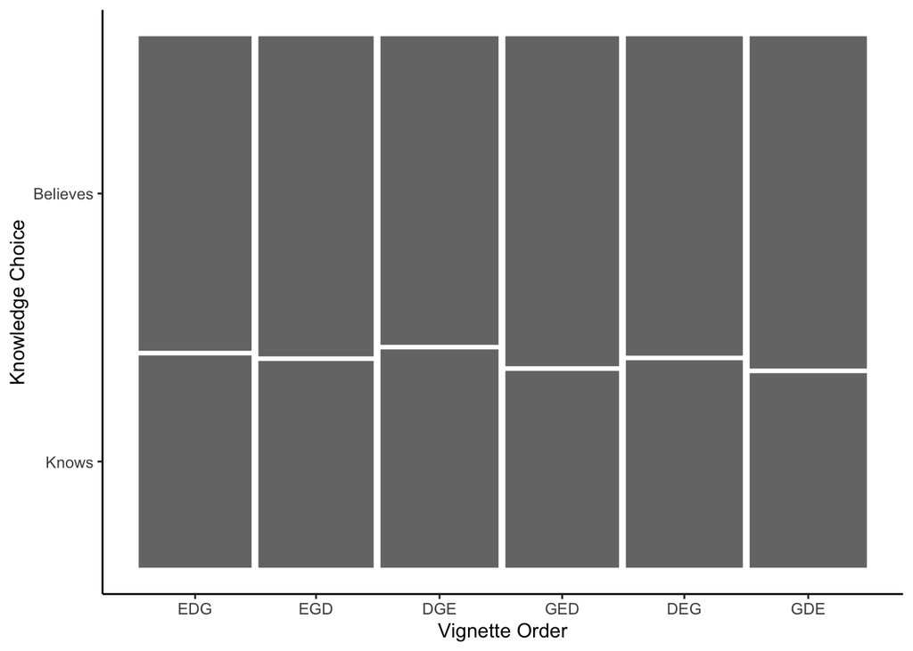

```r
#graph the two way binary
ggplot(data_graph) +
  geom_mosaic(aes(x = product(know_vas_combined, vignette_order))) +
  theme_classic() +
  xlab("Vignette Order") +
  ylab("Knowledge Choice")
```

```r
table(data_graph$know_vas_combined, data_graph$cond_order)
```

```
##
##             KGI  GKI  IGK  GIK  KIG  IKG
##   Knows     845  820  951  881  905  915
##   Believes 1388 1520 1324 1416 1328 1309
```

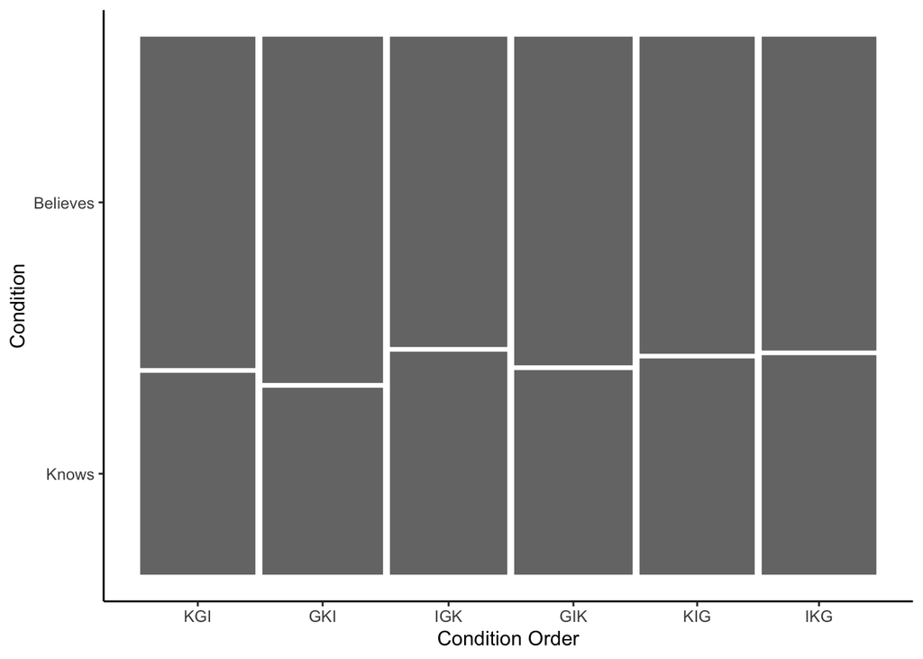

```r
ggplot(data_graph) +
  geom_mosaic(aes(x = product(know_vas_combined, cond_order))) +
  theme_classic() +
  xlab("Condition Order") +
  ylab("Condition")
```

- However, these plots indicate that there’s likely not a lot of effect for order - only slightly differences in knows versus believes selection.

```r
k.model.6H <- glmer(know_vas_combined ~ (1|vignette/id/person_code) +
                   comp + age + gender2 + education +
                   cond*vignette_order + cond*cond_order,
                      data = final_long,
                      family = binomial,
                      control = glmerControl(optimizer = "bobyqa"),
                      nAGQ = 0)
summary(k.model.6H)
```

```
## Generalized linear mixed model fit by maximum likelihood (Adaptive
##   Gauss-Hermite Quadrature, nAGQ = 0) [glmerMod]
##  Family: binomial  ( logit )
## Formula: know_vas_combined ~ (1 | vignette/id/person_code) + comp + age +
##     gender2 + education + cond * vignette_order + cond * cond_order
##    Data: final_long
## Control: glmerControl(optimizer = "bobyqa")
##
##      AIC      BIC   logLik deviance df.resid
##  15520.3  15821.1  -7720.2  15440.3    13562
##
## Scaled residuals:
##     Min      1Q  Median      3Q     Max
## -4.7345 -0.7784  0.4639  0.6646  1.9021
##
## Random effects:
##  Groups                    Name        Variance Std.Dev.
##  person_code:(id:vignette) (Intercept) 0.0000   0.0000
##  id:vignette               (Intercept) 0.0000   0.0000
##  vignette                  (Intercept) 0.4546   0.6743
## Number of obs: 13602, groups:
## person_code:(id:vignette), 13602; id:vignette, 13602; vignette, 3
##
## Fixed effects:
##                                  Estimate Std. Error z value         Pr(>|z|)
## (Intercept)                      0.289155   0.419532   0.689          0.49068
## compYes                         -0.032482   0.045250  -0.718          0.47286
## age                             -0.004861   0.002065  -2.353          0.01860
## gender2male                      0.094072   0.043086   2.183          0.02901
## education                        0.015716   0.007593   2.070          0.03847
## condIgnorance                    1.149906   0.167279   6.874 0.00000000000623
## condKnowledge                   -0.670591   0.150039  -4.469 0.00000784179822
## vignette_orderEGD               -0.055582   0.111930  -0.497          0.61949
## vignette_orderDGE               -0.085666   0.109987  -0.779          0.43605
## vignette_orderGED                0.096109   0.111950   0.859          0.39062
## vignette_orderDEG                0.108355   0.111136   0.975          0.32957
## vignette_orderGDE                0.221128   0.111663   1.980          0.04767
## cond_orderGKI                    0.130418   0.110911   1.176          0.23964
## cond_orderIGK                   -0.315463   0.110097  -2.865          0.00417
## cond_orderGIK                   -0.023394   0.110618  -0.211          0.83251
```

[output cut: 47 more lines]

```
## condKnowledge:vignette_orderDEG
## condIgnorance:vignette_orderGDE
## condKnowledge:vignette_orderGDE
## condIgnorance:cond_orderGKI
## condKnowledge:cond_orderGKI
## condIgnorance:cond_orderIGK
## condKnowledge:cond_orderIGK
## condIgnorance:cond_orderGIK
## condKnowledge:cond_orderGIK
## condIgnorance:cond_orderKIG     .
## condKnowledge:cond_orderKIG
## condIgnorance:cond_orderIKG
## condKnowledge:cond_orderIKG
## ---
## Signif. codes:  0 '***' 0.001 '**' 0.01 '*' 0.05 '.' 0.1 ' ' 1
```

```
##
## Correlation matrix not shown by default, as p = 37 > 12.
## Use print(x, correlation=TRUE)  or
##     vcov(x)        if you need it
```

```r
r.squaredGLMM(k.model.6H)
```

```
##                   R2m       R2c
## theoretical 0.1556897 0.2582032
## delta       0.1290547 0.2140304
```

- Model 6 AIC: 15503.8704799
- Model 6F AIC: 15520.3466278
- Interpretation: This model is not better than a model with just the order effects.
- There is no interaction between condition and order effects.

## Lab Information

```r
# number of unique person_code by osf ids (some people had multiple projects) that are not NA
lab_sheet$unique_project <- paste0(lab_sheet$person_code, lab_sheet$link_code)

lab_sheet_temp <- lab_sheet %>%
  filter(unique_project != "NANA")

# number of projects that applied that have a link person code (65)
lab_sheet_temp %>%
  filter(!duplicated(unique_project)) %>%
  nrow()
```

```
## [1] 65
```

```r
# number of projects that got the protocol approved (51)
lab_sheet_temp %>%
  filter(protocol_approved == "Yes") %>%
  filter(!duplicated(unique_project)) %>%
  nrow()
```

```
## [1] 51
```

```r
# therefore the subtraction is how many were not approved (14)

# number of unique projects who were approved and contributed data (43)
lab_sheet_temp %>%
  filter(use == "Yes") %>%
  filter(protocol_approved == "Yes") %>%
  filter(!duplicated(unique_project)) %>%
  nrow()
```

```
## [1] 43
```

```r
# therefore 8 were lost (51 - 43) because they either didn't collect data
# or we could not use the qualtrics data

# number of project who "finished" crep
lab_sheet_temp %>%
  filter(protocol_approved == "Yes") %>%
  filter(completed_crep_requirements == "Yes") %>%
  filter(!duplicated(unique_project)) %>%
  nrow()
```

```
## [1] 22
```

```r
# number of labs who had data in the full sample
full_long_project <- full_long %>%
  left_join(lab_sheet %>% select(lab_code, person_code, unique_project),
            by = c("lab_id" = "lab_code", "person_code" = "person_code"))

length(unique(full_long_project$unique_project)) # match yay
```

```
## [1] 43
```

```r
final_long_project <- final_long %>%
  left_join(lab_sheet %>% select(lab_code, person_code, unique_project),
            by = c("lab_id" = "lab_code", "person_code" = "person_code"))

# the big table
THAT_TABLE <-
  lab_sheet_temp %>%
  filter(use == "Yes") %>%
  group_by(person_code) %>%
  summarize(Language = paste(language, collapse = "_"),
            GP_Region = paste(country, collapse = "_"),
            Site = NA,
            Teams = length(unique(unique_project)),
            Sample = paste(sampled_population, collapse = "_"),
            In_Person = paste(in_person, collapse = "_"),
            In_Group = paste(group_data, collapse = "_"),
            Compensation = paste(compensation, collapse = "_"),
            Site_Analysis = NA)

FULL_N <-
  full_long_project %>%
  group_by(person_code) %>%
  summarize(Full_N = n()/3)

FINAL_N <-
  final_long_project %>%
  group_by(person_code) %>%
  summarize(Final_N = n()/3)

THAT_TABLE <- THAT_TABLE %>%
  left_join(FULL_N, by = c("person_code" = "person_code")) %>%
  left_join(FINAL_N, by = c("person_code" = "person_code"))

flextable(THAT_TABLE)
```

| person_code | Language | GP_Region | Site | Teams | Sample | In_Person | In_Group | Compensation | Site_Analysis | Full_N | Final_N |
| --- | --- | --- | --- | --- | --- | --- | --- | --- | --- | --- | --- |
| 04aec6c128a6d0c7b156124a782a2e17 | English | USA |  | 1 | Undergraduates | Yes | Unclear | Course Credit |  | 387 | 221 |
| 053921f004965238755a0b08414ad61f | English | CAN |  | 1 | Undergraduates | No | No | Course Credit |  | 551 | 258 |
| 10fe64c77bdcdd1f63c4f6f6767bd834 | Chinese | TWN |  | 1 | Community | No | No | Money |  | 452 | 108 |
| 1300dd2a365669443e58645538040b7e | English | GRC |  | 1 | Both | No | No | None |  | 98 | 52 |
| 20e15d6f0eb0520239a9f7921b1ee905 | Turkish | TUR |  | 1 | Undergraduates | No | No | Unclear |  | 304 | 77 |
| 25c0099bdeb9900e64b3f1e17ea9cf32 | Polish | POL |  | 1 | Unclear | Unclear | Unclear | None |  | 179 | 72 |
| 2c70764140dc2267dc65e463842c75dd | Hungarian | HUN |  | 1 | Undergraduates | Both | Unclear | Course Credit |  | 658 | 449 |
| 3b4e9381f4aafb032e37c0d5fa732aba | English | SGP |  | 1 | Undergraduates | Yes | Yes | Course Credit |  | 78 | 52 |
| 3e1f2a5e94450c8371562c74671ace76 | English | NZL |  | 1 | Unclear | Yes | No | Lottery |  | 58 | 42 |
| 47cce7454402254dd1e56c7338d2ca3b | Portuguese | POR |  | 1 | Both | No | No | Course Credit for Students, Nothing for Community |  | 149 | 81 |
| 4f86a6d4b553a44559cde3ceba92b330 | French | CHE |  | 1 | Unclear | Unclear | Unclear | Unclear |  | 58 | 28 |
| 5f4f444af13a37ac3598f3f4f613f560 | English | USA |  | 1 | Undergraduates | No | No | Course Credit |  | 129 | 56 |
| 6109cf70459f0edc57ccb89cf26d66ef | German | AUT |  | 1 | Unclear | Unclear | Unclear | None |  | 159 | 76 |
| 63947e8c9e47bc0056f78f402f3898f1 | English | USA |  | 1 | Undergraduates | No | No | Course Credit |  | 103 | 36 |
| 64ba90ce7822b9c898df033ebb8c2c18 | German | AUT |  | 1 | Unclear | Unclear | Unclear | Unclear |  | 143 | 75 |
| 71289e5ce6b2abe28c0d25bdce7c14a0 | English | USA |  | 1 | Undergraduates | No | No | Course Credit |  | 162 | 93 |
| 7898bca2938d7b6d8a82093ddffb15dc | English | USA |  | 1 | Undergraduates | No | No | Course Credit |  | 213 | 103 |
| 82d647ec9366dd067a092145d7d8ee7b | English_English | GBR_GBR |  | 1 | Undergraduates_Undergraduates | No_No | No_No | Course Credit_Course Credit |  | 340 | 132 |
| 8ceb72b59172af0d6a8d657e76ec4ce8 | English | AUS |  | 1 | Undergraduates | No | No | Course Credit |  | 215 | 122 |
| 8ee3ca908c989e3f6342994da802c3bd | Russian | RUS |  | 1 | Both | No | No | Course Credit |  | 233 | 99 |
| a5e2ba5c7fcf9a90c4bc1b5ed666f57b | Polish_Polish | POL_POL |  | 1 | Both_Both | No_No | No_No | None_None |  | 243 | 121 |
| adaccbbc254a881db6c19b3224887bcc | English | USA |  | 1 | Community | No | No | Money |  | 510 | 356 |
| b6bab6f7c2e61741dcdc1689c30fc5fb | English | USA |  | 1 | Undergraduates | Unclear | Unclear | Unclear |  | 8 |  |
| b975583369996d9136088dbe211abfcf | English | USA |  | 1 | Undergraduates | No | No | Course Credit |  | 124 | 57 |
| bc3266a9a2dc0de236029a38f1e0d4b9 | English | USA |  | 1 | Undergraduates | No | No | Course Credit |  | 95 | 54 |
| bfe85dfa8a47470e2600b4bae1dfe4c1 | German_German_German_German_German_German_German | DEU_DEU_DEU_DEU_DEU_DEU_DEU |  | 7 | Undergraduates_Undergraduates_Undergraduates_Undergraduates_Undergraduates_Undergraduates_Undergraduates | Yes_Yes_Yes_No_No_No_No | No_No_No_No_No_No_No | Sweets_Sweets_Sweets_Money_None_None_Lottery |  | 1,102 | 588 |
| c22875ee12b4cdfb8843ead3b8e1ddf8 | English | USA |  | 1 | Undergraduates | No | No | Course Credit |  | 164 | 93 |
| c6e892a926333f0840a81af6fa74a6c6 | Slovak | SVK |  | 1 | Both | No | No | None |  | 229 | 103 |
| ccc20a00466f0c4077f924733e9a3789 | Norwegian | NOR |  | 1 | Both | No | No | Sweets |  | 147 | 76 |
| d4c4b2302987480f7ce2084927489e4e | English | USA |  | 1 | Undergraduates | Yes | Unclear | Course Credit |  | 64 | 43 |
| d5450db323eeab9cf7bd57ecc95d3454 | English | USA |  | 1 | Undergraduates | No | No | Course Credit |  | 112 | 56 |
| d547b0fe851b1f8786fce767e3d89f50 | English_English | USA_USA |  | 1 | Undergraduates_Undergraduates | Unclear_Unclear | Unclear_Unclear | Course Credit_Course Credit |  | 402 | 201 |
| de5a43985156a022e44511202ccd5449 | Romanian | ROU |  | 1 | Undergraduates | No | No | Course Credit |  | 661 | 371 |
| ec35cfeaedd64eccef16c265b2ba179f | German | DEU |  | 1 | Undergraduates | No | No | Unclear |  | 332 | 184 |
| ecb1153cd73ee30290a753fb74358c19 | English | USA |  | 1 | Undergraduates | No | No | Course Credit |  | 91 | 48 |
| f19f790831cbe3722ccd98fd63d3d902 | English | USA |  | 1 | Both | No | No | Course Credit for Students, Nothing for Community |  | 135 | 63 |
| fd5a38067cf64a3e10ae8e92f015be4e | English | USA |  | 1 | Undergraduates | No | No | Course Credit |  | 187 | 78 |

```r
FULL_N_project <-
  full_long_project %>%
  group_by(person_code, unique_project) %>%
  summarize(Full_N = n()/3)
FINAL_N_project <-
  final_long_project %>%
  group_by(person_code, unique_project) %>%
  summarize(Final_N = n()/3)
flextable(FULL_N_project %>%
            left_join(FINAL_N_project,
                      by = c("person_code" = "person_code",
                             "unique_project" = "unique_project")))
```

| person_code | unique_project | Full_N | Final_N |
| --- | --- | --- | --- |
| 04aec6c128a6d0c7b156124a782a2e17 | 04aec6c128a6d0c7b156124a782a2e17tz37n | 387 | 221 |
| 053921f004965238755a0b08414ad61f | 053921f004965238755a0b08414ad61ftbywc | 551 | 258 |
| 10fe64c77bdcdd1f63c4f6f6767bd834 | 10fe64c77bdcdd1f63c4f6f6767bd8346trj5 | 452 | 108 |
| 1300dd2a365669443e58645538040b7e | 1300dd2a365669443e58645538040b7eaxpsq | 98 | 52 |
| 20e15d6f0eb0520239a9f7921b1ee905 | 20e15d6f0eb0520239a9f7921b1ee9055vqyz | 304 | 77 |
| 25c0099bdeb9900e64b3f1e17ea9cf32 | 25c0099bdeb9900e64b3f1e17ea9cf32uxcfe | 179 | 72 |
| 2c70764140dc2267dc65e463842c75dd | 2c70764140dc2267dc65e463842c75dd5pnvc | 658 | 449 |
| 3b4e9381f4aafb032e37c0d5fa732aba | 3b4e9381f4aafb032e37c0d5fa732aba6q75c | 78 | 52 |
| 3e1f2a5e94450c8371562c74671ace76 | 3e1f2a5e94450c8371562c74671ace76pz9v2 | 58 | 42 |
| 47cce7454402254dd1e56c7338d2ca3b | 47cce7454402254dd1e56c7338d2ca3b3s9xb | 149 | 81 |
| 4f86a6d4b553a44559cde3ceba92b330 | 4f86a6d4b553a44559cde3ceba92b330zmjq9 | 58 | 28 |
| 5f4f444af13a37ac3598f3f4f613f560 | 5f4f444af13a37ac3598f3f4f613f560fc8ur | 129 | 56 |
| 6109cf70459f0edc57ccb89cf26d66ef | 6109cf70459f0edc57ccb89cf26d66efwgk38 | 159 | 76 |
| 63947e8c9e47bc0056f78f402f3898f1 | 63947e8c9e47bc0056f78f402f3898f17a6wz | 103 | 36 |
| 64ba90ce7822b9c898df033ebb8c2c18 | 64ba90ce7822b9c898df033ebb8c2c18ws273 | 143 | 75 |
| 71289e5ce6b2abe28c0d25bdce7c14a0 | 71289e5ce6b2abe28c0d25bdce7c14a0fr3jw | 162 | 93 |
| 7898bca2938d7b6d8a82093ddffb15dc | 7898bca2938d7b6d8a82093ddffb15dceuc9t | 213 | 103 |
| 82d647ec9366dd067a092145d7d8ee7b | 82d647ec9366dd067a092145d7d8ee7bq2anz | 340 | 132 |
| 8ceb72b59172af0d6a8d657e76ec4ce8 | 8ceb72b59172af0d6a8d657e76ec4ce8d8rsh | 215 | 122 |
| 8ee3ca908c989e3f6342994da802c3bd | 8ee3ca908c989e3f6342994da802c3bdtkz8b | 233 | 99 |
| a5e2ba5c7fcf9a90c4bc1b5ed666f57b | a5e2ba5c7fcf9a90c4bc1b5ed666f57buvmj4 | 243 | 121 |
| adaccbbc254a881db6c19b3224887bcc | adaccbbc254a881db6c19b3224887bccnrdsf | 510 | 356 |
| b6bab6f7c2e61741dcdc1689c30fc5fb | b6bab6f7c2e61741dcdc1689c30fc5fb6da9r | 8 |  |
| b975583369996d9136088dbe211abfcf | b975583369996d9136088dbe211abfcffnr7p | 124 | 57 |
| bc3266a9a2dc0de236029a38f1e0d4b9 | bc3266a9a2dc0de236029a38f1e0d4b93gaxf | 95 | 54 |
| bfe85dfa8a47470e2600b4bae1dfe4c1 | bfe85dfa8a47470e2600b4bae1dfe4c15ab6f | 27 | 6 |
| bfe85dfa8a47470e2600b4bae1dfe4c1 | bfe85dfa8a47470e2600b4bae1dfe4c185wde | 22 | 13 |
| bfe85dfa8a47470e2600b4bae1dfe4c1 | bfe85dfa8a47470e2600b4bae1dfe4c1g7fp6 | 236 | 140 |
| bfe85dfa8a47470e2600b4bae1dfe4c1 | bfe85dfa8a47470e2600b4bae1dfe4c1gx5cu | 135 | 80 |
| bfe85dfa8a47470e2600b4bae1dfe4c1 | bfe85dfa8a47470e2600b4bae1dfe4c1htbcz | 182 | 81 |
| bfe85dfa8a47470e2600b4bae1dfe4c1 | bfe85dfa8a47470e2600b4bae1dfe4c1rx4fp | 290 | 162 |
| bfe85dfa8a47470e2600b4bae1dfe4c1 | bfe85dfa8a47470e2600b4bae1dfe4c1wr695 | 210 | 106 |
| c22875ee12b4cdfb8843ead3b8e1ddf8 | c22875ee12b4cdfb8843ead3b8e1ddf89673d | 164 | 93 |
| c6e892a926333f0840a81af6fa74a6c6 | c6e892a926333f0840a81af6fa74a6c6phme2 | 229 | 103 |
| ccc20a00466f0c4077f924733e9a3789 | ccc20a00466f0c4077f924733e9a3789n78fm | 147 | 76 |
| d4c4b2302987480f7ce2084927489e4e | d4c4b2302987480f7ce2084927489e4erf3at | 64 | 43 |
| d5450db323eeab9cf7bd57ecc95d3454 | d5450db323eeab9cf7bd57ecc95d3454cd8kp | 112 | 56 |
| d547b0fe851b1f8786fce767e3d89f50 | d547b0fe851b1f8786fce767e3d89f50pgync | 402 | 201 |
| de5a43985156a022e44511202ccd5449 | de5a43985156a022e44511202ccd5449p6459 | 661 | 371 |
| ec35cfeaedd64eccef16c265b2ba179f | ec35cfeaedd64eccef16c265b2ba179fy5dw7 | 332 | 184 |
| ecb1153cd73ee30290a753fb74358c19 | ecb1153cd73ee30290a753fb74358c19g3tcw | 91 | 48 |
| f19f790831cbe3722ccd98fd63d3d902 | f19f790831cbe3722ccd98fd63d3d902zje64 | 135 | 63 |
| fd5a38067cf64a3e10ae8e92f015be4e | fd5a38067cf64a3e10ae8e92f015be4e7u328 | 187 | 78 |